# Reproducibility Report

- Show All Code
- Hide All Code
- View Source

Ease and Evidence: Visual Fluency in Screening

Author

Affiliation

*blinded for review*

*blinded for review*

# 1 Introduction

This report reproduces the results, tables, and figures of the paper and its appendix. Its sections follow the order of the paper, and its hypotheses, tables, and figures are numbered as in the paper and its appendix. Each section starts from the processed data of the respective study. The detailed reproducibility report of each study, linked at the beginning of each section, documents how the raw data were processed and which participants and observations were excluded, and it reports the full models and further analyses.

As this report is dynamically created with R and Quarto, we also report all code. However, for readability, code is hidden by default and only the relevant results are shown.

```r
# setup
library(here)
library(dplyr)
library(knitr)
library(ggplot2)
library(ggtext)
library(patchwork)
library(kableExtra)
options(knitr.kable.NA = '',
        kable_styling_bootstrap_options = c("striped", "condensed", "responsive"))

# further packages that are loaded on demand are:
# - readr
# - tidyr
# - stringr
# - forcats
# - weights
# - scales
# - car
# - rstatix
# - supernova
# - afex
# - BayesFactor
# - lme4
# - lmerTest
# - performance
# - marginaleffects
# - AER
# - irr
# - hrbrthemes
# - ggsankey
# - purrr
# - grid

# set option to disable showing the column types when loading data with `readr`
options("readr.show_col_types" = FALSE)

# folders of the processed and the raw data
processed_dir <- 'reproducibility_reports/data'
raw_dir <- 'reproducibility_reports/data'

# colors
blue_main <- "#297FB8"
blue_dark <- "#2D3E50"
blue_light <- "#A0ABBF"


# Custom functions
#
# two decimals
f2 <- function(x) sprintf('%.2f', x)
#
# p-value in the text, e.g., "p = .663" or "p < .001"
p_txt <- function(p) ifelse(p < .001, "*p* < .001", paste0("*p* = ", weights::rd(p, 3)))
#
# p-value in a table
p_tbl <- function(p) ifelse(p < .001, "&lt; .001", weights::rd(p, 3))
#
# 95% confidence interval, e.g., "[2.14, 5.73]"
ci_txt <- function(lower, upper) paste0("[", f2(lower), ", ", f2(upper), "]")
#
# format a Bayes factor (values above 1,000 in scientific notation,
# e.g., 1.16 × 10^4)
bf_fmt <- function(bf){
  ifelse(bf > 1000,
         paste0(sprintf('%.2f', bf / 10^floor(log10(bf))), " × 10<sup>", floor(log10(bf)), "</sup>"),
         sprintf('%.2f', bf))
}
#
# one-sample t-test of a participant-level contrast against zero: N, mean,
# two-sided 95% confidence interval, and p-value of the requested test
# -Note: NAs (participants without a valid contrast) are removed before the test
contrast_test <- function(x, alternative = "two.sided"){
  x <- x[!is.na(x)]
  tres <- t.test(x, mu = 0, alternative = alternative)
  cres <- t.test(x, mu = 0, alternative = "two.sided")
  data.frame(N = length(x), estimate = mean(x), lower = cres$conf.int[1],
             upper = cres$conf.int[2], p = tres$p.value)
}
#
# model-based difference between the high and the low condition in a
# mixed-effects model with effect coding (i.e., two times the coefficient),
# with its 95% confidence interval and two-sided p-value (Satterthwaite's
# degrees of freedom)
lmer_diff <- function(model, term){
  fe <- coef(summary(model))[term, ]
  data.frame(estimate = 2 * fe[["Estimate"]],
             lower = 2 * (fe[["Estimate"]] - qt(.975, fe[["df"]]) * fe[["Std. Error"]]),
             upper = 2 * (fe[["Estimate"]] + qt(.975, fe[["df"]]) * fe[["Std. Error"]]),
             p = fe[["Pr(>|t|)"]])
}
#
# repeat the column headers above each row group of a table (`last_labels`:
# other labels above the last group, e.g., c("p" = "p (TOST)"))
repeat_header <- function(tbl, last_labels = NULL){
  html <- as.character(tbl)
  header <- sub("(?s).*<thead>(.*)</thead>.*", "\\1", html, perl = TRUE)
  header <- gsub('<th style="', '<th style="box-shadow: none; ', header, fixed = TRUE)
  groups <- gregexpr('<tr grouplength=', html, ignore.case = TRUE)[[1]]
  for(pos in rev(groups[-1])){
    h <- header
    if(pos == max(groups)) for(old in names(last_labels)){
      h <- sub(paste0(">\\s*", old, "\\s*<"), paste0(">", last_labels[[old]], "<"), h, perl = TRUE)
    }
    html <- paste0(substr(html, 1, pos - 1), h, substr(html, pos, nchar(html)))
  }
  attributes(html) <- attributes(tbl)
  return(html)
}
#
# two-sided independent-samples t-test of the high vs. the low condition (Welch's test
# if the median-centered Levene test is significant at .05) with Cohen's d
mc_ttest <- function(formula, data){
  # check for homogeneous group variances (Levene's test, centered at the median)
  var_equal <- car::leveneTest(formula, data = data)$`Pr(>F)`[1] >= .05
  # perform t-test and extract Cohen's d
  tres <- t.test(formula, data = data, var.equal = var_equal)
  dres <- rstatix::cohens_d(formula, data = data, var.equal = var_equal)
  # condition means and SDs (high condition first)
  means <- aggregate(formula, data = data, FUN = mean)[, 2]
  sds <- aggregate(formula, data = data, FUN = sd)[, 2]
  # construct return df (degrees of freedom of Welch's test with one decimal)
  data.frame(n_high = dres$n1, n_low = dres$n2, mean_high = means[1], mean_low = means[2],
             sd_high = sds[1], sd_low = sds[2], t = tres$statistic[["t"]],
             df_txt = ifelse(var_equal, as.character(tres$parameter[["df"]]), weights::rd(tres$parameter[["df"]], 1)),
             p = tres$p.value, d = dres$effsize[[1]])
}
#
# condition means and t-test in the text, e.g., "M_high = 66.27, M_low = 46.69,
# t(98) = 3.65, p < .001, d = .73"
mc_ttest_txt <- function(res){
  paste0("*M*<sub>high</sub> = ", f2(res$mean_high), ", *M*<sub>low</sub> = ", f2(res$mean_low),
         ", *t*(", res$df_txt, ") = ", f2(res$t), ", ", p_txt(res$p), ", *d* = ", weights::rd(res$d, 2))
}
#
# t-test as a figure label (outcome, t-test, p-value, and Cohen's d)
mc_ttest_str <- function(formula, data){
  res <- mc_ttest(formula, data)
  dv <- stringr::str_match(deparse(formula), '[^ ~]*')
  paste0(stringr::str_to_sentence(dv), "\nt(", res$df_txt, ") = ", f2(res$t),
         ", p", ifelse(res$p < .001, " < .001", paste0(" = ", weights::rd(res$p, 3))),
         "; d = ", weights::rd(res$d, 2))
}
#
# model-based difference between the high and the low condition in a linear
# model with effect coding (two times the coefficient, four times for an
# interaction), with its 95% confidence interval and two-sided p-value
lm_diff <- function(model, term, multiplier = 2){
  fe <- coef(summary(model))[term, ]
  ci <- confint(model)[term, ]
  data.frame(estimate = multiplier * fe[["Estimate"]], lower = multiplier * ci[[1]],
             upper = multiplier * ci[[2]], p = fe[["Pr(>|t|)"]])
}
#
# type III ANOVA of a linear model: SS, df, residual df, F, p, and partial eta
# squared of each effect
anova_3 <- function(model){
  tbl <- supernova::supernova(model, type = 3)$tbl
  effects <- !(tbl$term %in% c("Model", "Error", "Total"))
  data.frame(SS = tbl$SS[effects], df = tbl$df[effects], df_res = tbl$df[tbl$term == "Error"],
             F = tbl$F[effects], p = tbl$p[effects], eta = tbl$PRE[effects])
}
#
# t-test of the high vs. the low condition (factor levels "high", "low"; Student's
# or Welch's test, depending on Levene's test): means, difference, 95% CI, t, df, p
ttest_diff <- function(formula, data){
  var.equal <- car::leveneTest(formula, data = data)$`Pr(>F)`[1] >= .05
  tres <- t.test(formula, data = data, var.equal = var.equal)
  data.frame(low = tres$estimate[[2]], high = tres$estimate[[1]],
             estimate = tres$estimate[[1]] - tres$estimate[[2]],
             lower = tres$conf.int[1], upper = tres$conf.int[2],
             t = tres$statistic[[1]], df = tres$parameter[[1]], p = tres$p.value)
}
#
# coefficients (estimate, SE, t, p) of the given terms of a linear model,
# followed by R² and adjusted R², formatted for a table
lm_tbl <- function(model, terms, labels){
  cf <- coef(summary(model))[terms, , drop = FALSE]
  data.frame(Term = c(labels, "R<sup>2</sup>", "R<sup>2</sup><sub>adj.</sub>"),
             Coeff = c(f2(cf[, "Estimate"]), weights::rd(summary(model)$r.squared, 3),
                       weights::rd(summary(model)$adj.r.squared, 3)),
             SE = c(sprintf('%.3f', cf[, "Std. Error"]), "", ""),
             t = c(f2(cf[, "t value"]), "", ""),
             p = c(p_tbl(cf[, "Pr(>|t|)"]), "", ""))
}
#
# prepare the LLM ratings: numeric ratings and, for the items of the human
# visual questionnaire, simplicity as the reverse-coded complexity item (8 - complexity)
llm_prep <- function(d){
  d$rating <- as.numeric(d$rating)
  d_simplicity <- d |> filter(item == "complex") |> mutate(item = "simplicity", rating = 8 - rating)
  bind_rows(d, d_simplicity) |> filter(!is.na(rating))
}
#
# high vs. low condition of a factor at the level of the startups: condition means
# (across models, repetitions, and the other factor), mean of the startup-level
# differences, percentile bootstrap 95% CI (4,000 resamples), Cohen's d_z, and the
# exact two-sided Wilcoxon signed-rank test
# -Note: since R 4.6.0, the exact p-value is also computed for tied differences
llm_contrast <- function(d, item, factor, high, low){
  # mean rating per startup and condition
  cells <- d[d$item == item & d[[factor]] %in% c(high, low), ] |>
    group_by(startup, level = .data[[factor]]) |>
    summarize(rating = mean(rating), .groups = "drop") |>
    tidyr::pivot_wider(names_from = level, values_from = rating) |>
    tidyr::drop_na()
  diffs <- cells[[high]] - cells[[low]]
  # percentile bootstrap 95% CI of the mean difference
  set.seed(0)
  boot <- replicate(4000, mean(sample(sort(diffs), replace = TRUE)))
  ci <- quantile(boot, c(.025, .975), names = FALSE)
  # exact Wilcoxon signed-rank test (two-sided)
  wres <- wilcox.test(cells[[high]], cells[[low]], paired = TRUE, exact = TRUE)
  # construct return df
  data.frame(n = nrow(cells), high = mean(cells[[high]]), low = mean(cells[[low]]),
             estimate = mean(diffs), lower = ci[1], upper = ci[2],
             d = mean(diffs) / sd(diffs), p = wres$p.value)
}
#
# intraclass correlations of a matrix of ratings (rows = rated decks, columns =
# raters): ICC(2,1) and ICC(2,k), two-way random effects, absolute agreement
llm_icc <- function(m){
  m <- as.matrix(m)
  m <- m[complete.cases(m), ]
  n <- nrow(m); k <- ncol(m); g <- mean(m)
  # mean squares of the rows (decks), the columns (raters), and the residuals
  ms_rows <- k * sum((rowMeans(m) - g)^2) / (n - 1)
  ms_cols <- n * sum((colMeans(m) - g)^2) / (k - 1)
  ms_error <- sum((m - outer(rowMeans(m), colMeans(m), "+") + g)^2) / ((n - 1) * (k - 1))
  # construct return vector
  c(icc_1 = (ms_rows - ms_error) / (ms_rows + (k - 1) * ms_error + k * (ms_cols - ms_error) / n),
    icc_k = (ms_rows - ms_error) / (ms_rows + (ms_cols - ms_error) / n))
}
#
# quadratic-weighted Cohen's kappa of two raters for the categories 1 to 7 (NA if
# both raters give all decks the same rating)
llm_kappa <- function(a, b, categories = 1:7){
  obs <- table(factor(a, levels = categories), factor(b, levels = categories))
  expected <- outer(rowSums(obs), colSums(obs)) / sum(obs)
  weights <- outer(categories, categories, function(i, j) (i - j)^2) / (length(categories) - 1)^2
  if(sum(weights * expected) == 0) return(NA)
  1 - sum(weights * obs) / sum(weights * expected)
}
#
# agreement between the models for a set of items: ICC(2,1) and ICC(2,k) of the
# scale mean per deck and model, and the weighted kappa averaged across all pairs
# of models and the items (per item, a model's three ratings are averaged and rounded)
llm_reliability <- function(d, items){
  # scale mean per deck and model
  m <- d |> filter(item %in% items) |>
    group_by(file, model) |> summarize(rating = mean(rating), .groups = "drop") |>
    tidyr::pivot_wider(names_from = model, values_from = rating) |>
    tidyr::drop_na()
  icc <- llm_icc(m[, -1])
  # rounded mean rating per item, deck, and model
  r <- d |> filter(item %in% items) |>
    group_by(item, file, model) |>
    summarize(rating = pmin(pmax(round(mean(rating)), 1), 7), .groups = "drop")
  pairs <- combn(sort(unique(r$model)), 2)
  kappas <- unlist(lapply(items, function(it){
    w <- r |> filter(item == it) |> select(-item) |>
      tidyr::pivot_wider(names_from = model, values_from = rating) |> tidyr::drop_na()
    apply(pairs, 2, function(p) llm_kappa(w[[p[1]]], w[[p[2]]]))
  }))
  # construct return df
  data.frame(decks = nrow(m), models = ncol(m) - 1, icc_1 = icc[["icc_1"]],
             icc_k = icc[["icc_k"]], kappa = mean(kappas, na.rm = TRUE),
             pairs = length(kappas), undefined = sum(is.na(kappas)))
}
#
# three decimals, e.g., "-0.421"
bm_f3 <- function(x) sprintf('%.3f', x)
#
# 95% confidence interval with three decimals, e.g., "[-0.515, -0.328]"
bm_ci3 <- function(lower, upper) paste0("[", bm_f3(lower), ", ", bm_f3(upper), "]")
```

```r
#
# correlation with three decimals and without a leading zero, e.g., ".153"
bm_r <- function(x) weights::rd(x, 3)
#
# 95% confidence interval of a correlation, e.g., "[.121, .186]"
bm_ci_r <- function(lower, upper) paste0("[", bm_r(lower), ", ", bm_r(upper), "]")
#
# Pearson correlation with its 95% confidence interval and two-sided p-value
bm_cor <- function(x, y){
  res <- cor.test(x, y)
  data.frame(r = res$estimate[["cor"]], lower = res$conf.int[1], upper = res$conf.int[2], p = res$p.value)
}
#
# range of the ratings across the three prompt versions (per deck)
bm_prompt_range <- function(d, cols){
  apply(d[, cols], 1, function(x) max(x) - min(x))
}
#
# Welch two-sample t-test (first minus second group): N of both groups, mean
# difference, two-sided 95% confidence interval, and p-value of the requested
# test
# -Note: NAs (participants without a valid contrast) are removed before the test
welch_test <- function(x, y, alternative = "two.sided"){
  x <- x[!is.na(x)]
  y <- y[!is.na(y)]
  tres <- t.test(x, y, alternative = alternative, var.equal = FALSE)
  cres <- t.test(x, y, alternative = "two.sided", var.equal = FALSE)
  data.frame(N_1 = length(x), N_2 = length(y), estimate = mean(x) - mean(y),
             lower = cres$conf.int[1], upper = cres$conf.int[2], p = tres$p.value)
}
#
# difference implied by a coefficient of a mixed-effects model with effect
# coding (multiplier times the coefficient, i.e., 4 for a two-way and 8 for a
# three-way interaction), with its 95% confidence interval and two-sided
# p-value (Satterthwaite's degrees of freedom)
lmer_multi <- function(model, term, multiplier){
  fe <- coef(summary(model))[term, ]
  data.frame(estimate = multiplier * fe[["Estimate"]],
             lower = multiplier * (fe[["Estimate"]] - qt(.975, fe[["df"]]) * fe[["Std. Error"]]),
             upper = multiplier * (fe[["Estimate"]] + qt(.975, fe[["df"]]) * fe[["Std. Error"]]),
             p = fe[["Pr(>|t|)"]])
}
#
# odds ratio (high vs. low) of a factor with effect coding in a mixed logistic
# regression (i.e., exp(2 × coefficient)), with its 95% Wald confidence
# interval and two-sided p-value
glmer_or <- function(model, term){
  fe <- coef(summary(model))[term, ]
  data.frame(estimate = exp(2 * fe[["Estimate"]]),
             lower = exp(2 * (fe[["Estimate"]] - qnorm(.975) * fe[["Std. Error"]])),
             upper = exp(2 * (fe[["Estimate"]] + qnorm(.975) * fe[["Std. Error"]])),
             p = fe[["Pr(>|z|)"]])
}
#
# preregistered analysis of the fluency contrast in the disclosure condition
# (x): N, mean, 95% confidence interval, two-sided p-value, Bayes factor
# (Cauchy prior, r = 0.707), 90% confidence interval, p-value of the
# equivalence test (the larger p-value of the two one-sided tests against
# -bound and +bound), p-value of the Welch comparison with the control
# condition (x_control, two-sided), and case (1 to 5) and outcome of the
# preregistered decision rule
h4_tests <- function(x, x_control, bound = 0.225){
  # remove missing values
  x <- x[!is.na(x)]
  x_control <- x_control[!is.na(x_control)]
  # two-sided test against zero, 90% confidence interval, and Bayes factor
  tres <- t.test(x, mu = 0, alternative = "two.sided")
  ci90 <- t.test(x, mu = 0, conf.level = .90)$conf.int
  bf10 <- BayesFactor::extractBF(BayesFactor::ttestBF(x = x, mu = 0, rscale = 0.707))$bf
  # equivalence test (two one-sided tests)
  p_tost <- max(t.test(x, mu = -bound, alternative = "greater")$p.value,
                t.test(x, mu = bound, alternative = "less")$p.value)
  # control vs. disclosure (Welch t-test, two-sided)
  cres <- t.test(x_control, x, alternative = "two.sided", var.equal = FALSE)
  # decision rule (cases in the preregistered order)
  est <- mean(x)
  case <- case_when(tres$p.value < .05 & est <= -bound ~ 1,
                    tres$p.value < .05 & est >= bound ~ 2,
                    p_tost < .05 & cres$p.value < .05 & mean(x_control) > est ~ 3,
                    tres$p.value < .05 & est > 0 & p_tost >= .05 ~ 4,
                    TRUE ~ 5)
  outcome <- c("overcorrection", "persistence supported", "switched off",
               "reduced but present", "indeterminate")[case]
  data.frame(N = length(x), estimate = est, lower = tres$conf.int[1], upper = tres$conf.int[2],
             p = tres$p.value, bf10 = bf10, lower_90 = ci90[1], upper_90 = ci90[2],
             p_tost = p_tost, p_control = cres$p.value, case = case, outcome = outcome)
}
#
# coefficients of a linear, logit, or Tobit model with standard errors, 95%
# confidence intervals (t-based for linear models, Wald otherwise), test
# statistics, and two-sided p-values
reg_coefs <- function(model){
  est <- coef(summary(model))
  est <- est[rownames(est) != "Log(scale)", , drop = FALSE]
  if(inherits(model, c("glm", "tobit"))) crit <- qnorm(.975) else crit <- qt(.975, model$df.residual)
  data.frame(term = rownames(est), estimate = est[, 1], se = est[, 2],
             lower = est[, 1] - crit * est[, 2], upper = est[, 1] + crit * est[, 2],
             statistic = est[, 3], p = est[, 4], row.names = NULL)
}
#
# k times a model coefficient (e.g., the high-minus-low contrast of an
# effect-coded factor) with its 95% confidence interval and two-sided p-value;
# for logit models, the result is exponentiated (odds ratio)
coef_contrast <- function(model, term, k){
  res <- reg_coefs(model)
  res <- res[res$term == term, ]
  out <- data.frame(estimate = k * res$estimate, lower = k * res$lower, upper = k * res$upper,
                    statistic = res$statistic, p = res$p)
  if(inherits(model, "glm")) out[c("estimate", "lower", "upper")] <- exp(out[c("estimate", "lower", "upper")])
  return(out)
}
#
# high-minus-low difference of the model-based probabilities of `variable`
# (balanced grid, equal weights over the other factors) in percentage points,
# with its delta-method 95% confidence interval and two-sided p-value; `by` and
# `hypothesis` as in marginaleffects::avg_comparisons()
pp_contrast <- function(model, variable, by = TRUE, hypothesis = NULL){
  res <- marginaleffects::avg_comparisons(model, variables = setNames(list(c("low", "high")), variable),
                                          by = by, hypothesis = hypothesis, type = "response",
                                          newdata = marginaleffects::datagrid(model = model, grid_type = "balanced"))
  data.frame(estimate = 100 * res$estimate, lower = 100 * res$conf.low, upper = 100 * res$conf.high,
             statistic = res$statistic, p = res$p.value)
}
#
# coefficient rows of a regression table, with the terms relabeled and ordered
# as in `labels` (named vector) and estimates with `digits` decimals
coef_rows <- function(model, labels, digits = 2){
  res <- reg_coefs(model)
  res <- res[match(names(labels), res$term), ]
  fmt <- paste0('%.', digits, 'f')
  data.frame(Term = unname(labels), Estimate = sprintf(fmt, res$estimate), SE = sprintf('%.3f', res$se),
             CI = paste0("[", sprintf(fmt, res$lower), ", ", sprintf(fmt, res$upper), "]"),
             Statistic = f2(res$statistic), p = p_tbl(res$p))
}
#
# count with its percentage of n, e.g., "331 (7.4%)"
n_pct <- function(x, n) paste0(scales::comma(x), " (", sprintf('%.1f', 100 * x / n), "%)")
#
# mean with its standard deviation, e.g., "1.84 (3.80)"
mean_sd <- function(x) paste0(f2(mean(x)), " (", f2(sd(x)), ")")
```

# 2 Research Design Overview

The paper combines a field experiment (Study 1) with five preregistered online experiments (Studies 2A–2C, 3, and 4). Table 1 gives an overview of the six experiments. The numbers of participants are those after the participant-level exclusions (for Study 1, the analyzed deck viewers), and for Study 1 also the number of delivered emails.

```r
# analysis samples of all experiments (processed data) and the delivered emails
# of Study 1 (email exports: all sent emails without hard bounces)
design_s1_emails_sw <- readr::read_csv(here(raw_dir, 'Study_1-1_Software_Emails.csv'))
design_s1_emails_hc <- readr::read_csv(here(raw_dir, 'Study_1-2_Healthcare_Emails.csv'))
design_s1_sw <- readr::read_csv(here(processed_dir, 'Study_1_Software.csv'))
design_s1_hc <- readr::read_csv(here(processed_dir, 'Study_1_Healthcare.csv'))
design_s2a <- readr::read_csv(here(processed_dir, 'Study_2A_Software.csv'))
design_s2b <- readr::read_csv(here(processed_dir, 'Study_2B_Software_Replication.csv'))
design_s2c <- readr::read_csv(here(processed_dir, 'Study_2C_Healthcare.csv'))
design_s3 <- readr::read_csv(here(processed_dir, 'Study_3.csv'))
design_s4 <- readr::read_csv(here(processed_dir, 'Study_4.csv'))

data.frame(
  Study = c("1", "2A", "2B", "2C", "3", "4"),
  Question = c("Does design change engagement in investors’ regular deal flow?",
               "Does design affect stated investment likelihood when a single deck is assessed? (software startup)",
               "Same question (software startup, replication)",
               "Same question (healthcare startup)",
               "Is the design effect larger for attention than for investment allocation under common conditions?",
               "Does a quality-rating effect remain after design’s informational value is challenged?"),
  Participants = c(paste0("Early-stage investors; ", scales::comma(sum(design_s1_emails_sw$hard_bounce == 0) +
                                                          sum(design_s1_emails_hc$hard_bounce == 0)),
                          " delivered emails; ", scales::comma(nrow(design_s1_sw) + nrow(design_s1_hc)),
                          " analyzed deck viewers"),
                   paste0("Prolific participants; N\u00a0=\u00a0", nrow(design_s2a)),
                   paste0("Prolific participants; N\u00a0=\u00a0", nrow(design_s2b)),
                   paste0("Prolific participants; N\u00a0=\u00a0", nrow(design_s2c)),
                   paste0("Prolific participants; N\u00a0=\u00a0", nrow(design_s3)),
                   paste0("Prolific participants; N\u00a0=\u00a0", nrow(design_s4))),
  Design = c("Field experiment; 2\u00a0×\u00a02 between subjects; software and healthcare startup",
             "2\u00a0×\u00a02 between subjects; one deck",
             "2\u00a0×\u00a02 between subjects; one deck",
             "2\u00a0×\u00a02 between subjects; one deck",
             "2\u00a0×\u00a02 within participants in each of two tasks; eight startups",
             "Three instruction conditions between participants (1:5:2); 2\u00a0×\u00a02 within participants; four startups"),
  Measures = c("Opening duration, slide coverage, positive reactions",
               "Investment likelihood",
               "Investment likelihood, processing ease, perceived venture quality",
               "Investment likelihood, processing ease, perceived venture quality",
               "Access task (time-limited): attention tokens; evaluation task: investment capital; ratings of processing ease and perceived venture quality",
               "Evaluation task: investment capital; factual questions; beliefs about design; ratings of perceived venture quality and processing ease")
) |>
  kbl(col.names = c("Study", "Research question", "Participants", "Design", "Tasks and measures"),
      caption = "Table 1: Overview of the studies", align = "lllll") |>
  kable_styling() |>
  column_spec(1, width = "1%", extra_css = "white-space: nowrap;") |>
  column_spec(2:5, width = "11em")
```

Table 1: Overview of the studies

| Study | Research question | Participants | Design | Tasks and measures |
| --- | --- | --- | --- | --- |
| 1 | Does design change engagement in investors’ regular deal flow? | Early-stage investors; 34,487 delivered emails; 6,853 analyzed deck viewers | Field experiment; 2 × 2 between subjects; software and healthcare startup | Opening duration, slide coverage, positive reactions |
| 2A | Does design affect stated investment likelihood when a single deck is assessed? (software startup) | Prolific participants; N = 197 | 2 × 2 between subjects; one deck | Investment likelihood |
| 2B | Same question (software startup, replication) | Prolific participants; N = 200 | 2 × 2 between subjects; one deck | Investment likelihood, processing ease, perceived venture quality |
| 2C | Same question (healthcare startup) | Prolific participants; N = 193 | 2 × 2 between subjects; one deck | Investment likelihood, processing ease, perceived venture quality |
| 3 | Is the design effect larger for attention than for investment allocation under common conditions? | Prolific participants; N = 380 | 2 × 2 within participants in each of two tasks; eight startups | Access task (time-limited): attention tokens; evaluation task: investment capital; ratings of processing ease and perceived venture quality |
| 4 | Does a quality-rating effect remain after design’s informational value is challenged? | Prolific participants; N = 830 | Three instruction conditions between participants (1:5:2); 2 × 2 within participants; four startups | Evaluation task: investment capital; factual questions; beliefs about design; ratings of perceived venture quality and processing ease |

*Notes:* 2 × 2 = visual fluency (high vs. low) × substantive quality (high vs. low). The Prolific participants had investment experience. Studies 2A–2C used the decks of Study 1; Studies 3 and 4 used the decks of eight AI startups. Scales: investment likelihood 0–100%, processing ease 0–100, perceived venture quality 1–7; allocations of 100 attention tokens or 100 units of investment capital. In Studies 3 and 4, the bonus depended on the substantive-quality score of a startup drawn in proportion to its allocation, and the later ratings did not affect it. Study 4’s conditions: control, disclosure, disclosure plus explanation. Preregistrations: AsPredicted [#118675](https://aspredicted.org/fth5-wtc6.pdf) (Study 1), [#114380](https://aspredicted.org/f62v-xm2h.pdf) (Study 2A), [#116872](https://aspredicted.org/54nh-h4bt.pdf) (Study 2B), [#117215](https://aspredicted.org/crg2-gxf2.pdf) (Study 2C), [#304145](https://aspredicted.org/eh2924.pdf) (Study 3), and [#309446](https://aspredicted.org/ud65mi.pdf) (Study 4).

# 3 Manipulation Checks and Validation

This section reproduces the manipulation checks of the paper and Appendix A. The first part covers the four online experiments with human participants (Appendix A.2). Their data processing, exclusions, and further analyses are documented in the Manipulation Checks Reproducibility Report. The LLM ratings of the pitch decks (Appendix A.3–A.4) follow further below.

```r
# Manipulation checks
# AsPredicted Preregistrations #111740 (visual fluency, software startup),
# #112721 (substantive quality, software startup), #116999 (visual fluency,
# healthcare startup), #117000 (substantive quality, healthcare startup)
#
# processed data (one row per participant)
mc_design_sw <- readr::read_csv(here(processed_dir, 'MC_1_Design_Software.csv'))
mc_quality_sw <- readr::read_csv(here(processed_dir, 'MC_2_Quality_Software.csv'))
mc_design_hc <- readr::read_csv(here(processed_dir, 'MC_3_Design_Healthcare.csv'))
mc_quality_hc <- readr::read_csv(here(processed_dir, 'MC_4_Quality_Healthcare.csv'))
# survey exports: number of recorded and finished responses
mc_raw_design_sw <- readr::read_csv(here(raw_dir, 'MC_1_Design_Software_Qualtrics.csv'))
mc_raw_quality_sw <- readr::read_csv(here(raw_dir, 'MC_2_Quality_Software_Qualtrics.csv'))
mc_raw_design_hc <- readr::read_csv(here(raw_dir, 'MC_3_Design_Healthcare_Qualtrics.csv'))
mc_raw_quality_hc <- readr::read_csv(here(raw_dir, 'MC_4_Quality_Healthcare_Qualtrics.csv'))
mc_n_design_sw <- c(recorded = nrow(mc_raw_design_sw), finished = sum(mc_raw_design_sw$Finished))
mc_n_quality_sw <- c(recorded = nrow(mc_raw_quality_sw), finished = sum(mc_raw_quality_sw$Finished))
mc_n_design_hc <- c(recorded = nrow(mc_raw_design_hc), finished = sum(mc_raw_design_hc$Finished))
mc_n_quality_hc <- c(recorded = nrow(mc_raw_quality_hc), finished = sum(mc_raw_quality_hc$Finished))

# convert conditions into factors (high first)
mc_design_sw$fluency_condition <- factor(mc_design_sw$fluency_condition, levels = c("high", "low"))
mc_quality_sw$quality_condition <- factor(mc_quality_sw$quality_condition, levels = c("high", "low"))
mc_design_hc$fluency_condition <- factor(mc_design_hc$fluency_condition, levels = c("high", "low"))
mc_quality_hc$quality_condition <- factor(mc_quality_hc$quality_condition, levels = c("high", "low"))

# visual checks: t-tests of the six outcomes by visual fluency
mc_fl_sw <- bind_rows(mc_ttest(contrast ~ fluency_condition, mc_design_sw),
                      mc_ttest(clarity ~ fluency_condition, mc_design_sw),
                      mc_ttest(symmetry ~ fluency_condition, mc_design_sw),
                      mc_ttest(simplicity ~ fluency_condition, mc_design_sw),
                      mc_ttest(fluency ~ fluency_condition, mc_design_sw),
                      mc_ttest(quality ~ fluency_condition, mc_design_sw))
mc_fl_hc <- bind_rows(mc_ttest(contrast ~ fluency_condition, mc_design_hc),
                      mc_ttest(clarity ~ fluency_condition, mc_design_hc),
                      mc_ttest(symmetry ~ fluency_condition, mc_design_hc),
                      mc_ttest(simplicity ~ fluency_condition, mc_design_hc),
                      mc_ttest(fluency ~ fluency_condition, mc_design_hc),
                      mc_ttest(quality ~ fluency_condition, mc_design_hc))
rownames(mc_fl_sw) <- c("contrast", "clarity", "symmetry", "simplicity", "ease", "quality")
rownames(mc_fl_hc) <- c("contrast", "clarity", "symmetry", "simplicity", "ease", "quality")

# quality checks: t-tests of the six outcomes by substantive quality
mc_ql_sw <- bind_rows(mc_ttest(intell_prop ~ quality_condition, mc_quality_sw),
                      mc_ttest(hum_cap ~ quality_condition, mc_quality_sw),
                      mc_ttest(commerc ~ quality_condition, mc_quality_sw),
                      mc_ttest(legitim ~ quality_condition, mc_quality_sw),
                      mc_ttest(quality ~ quality_condition, mc_quality_sw),
                      mc_ttest(fluency ~ quality_condition, mc_quality_sw))
mc_ql_hc <- bind_rows(mc_ttest(intell_prop ~ quality_condition, mc_quality_hc),
                      mc_ttest(hum_cap ~ quality_condition, mc_quality_hc),
                      mc_ttest(commerc ~ quality_condition, mc_quality_hc),
                      mc_ttest(legitim ~ quality_condition, mc_quality_hc),
                      mc_ttest(quality ~ quality_condition, mc_quality_hc),
                      mc_ttest(fluency ~ quality_condition, mc_quality_hc))
rownames(mc_ql_sw) <- c("capital", "human", "commerc", "legitim", "quality", "ease")
rownames(mc_ql_hc) <- c("capital", "human", "commerc", "legitim", "quality", "ease")
```

## 3.1 Human manipulation checks: design and samples

The human manipulation checks were four preregistered online experiments, one for each manipulation (visual fluency or substantive quality) and each startup of Studies 1 and 2 (the software startup PerkSouq and the healthcare startup Brachytix). Each experiment had a one-factor between-subjects design with random assignment to a high or a low condition. In the two visual checks, the decks differed in visual fluency and contained the same substantive information. In the two quality checks, they differed in substantive quality and had the same neutral design. The surveys ran on Qualtrics, the decks were hosted on DocSend, and the participants were recruited through Prolific.

Qualtrics recorded 175 responses in the software visual check, 194 in the software quality check, 187 in the healthcare visual check, and 188 in the healthcare quality check, of which 160, 172, 167, and 168 were finished. After the exclusions, 100 participants remained in the software visual check (49 high and 51 low fluency), 113 in the software quality check (56 high and 57 low quality), 104 in the healthcare visual check (52 high and 52 low fluency), and 108 in the healthcare quality check (66 high and 42 low quality). The analyses therefore included 425 participants. In all four checks, the exclusions also removed participants whose conditions recorded by Qualtrics and by DocSend disagreed, a rule that was not preregistered.

The mean age of the participants was 43.29 years in the software visual check, 41.05 years in the software quality check, 41.56 years in the healthcare visual check, and 41.30 years in the healthcare quality check. The share of women was 46.0%, 42.5%, 60.6%, and 45.4%, respectively.

## 3.2 Human manipulation checks: preregistered t-tests

The visual checks measured perceived contrast, clarity, symmetry, and complexity on scales from 1 (not at all) to 7 (very much), with complexity reverse-coded as simplicity (8 minus the response). They further measured processing ease, the overall fluency measure, with the item “The process of studying this pitch deck was …” on a scale from 0 (difficult) to 100 (easy), and perceived venture quality on a scale from 1 (very poor) to 7 (excellent). The quality checks measured intellectual property (organizational capital), human capital, commercialization opportunity, organizational legitimacy, and perceived venture quality on scales from 1 (very poor) to 7 (excellent), followed by the same processing-ease item. The preregistrations predicted higher ratings in the high condition for the first five outcomes of each check and no difference in perceived venture quality (visual checks) or processing ease (quality checks). As preregistered, each outcome was compared between the high and the low condition with an independent-samples t-test at α = .05, using Welch’s test when the median-centered Levene test indicated unequal variances (α = .05). All tests are two-sided, and Cohen’s *d* is the standardized difference between the high and the low condition. Table A1 reports the visual checks and Table A2 the quality checks. Figures A2, A3, A4, and A5 show the individual ratings and condition means of the four checks.

*Results.* In both visual checks, the high-fluency deck received higher ratings of contrast, clarity, and symmetry (all *p* < .001) and higher processing ease (software startup: *M*<sub>high</sub> = 66.27, *M*<sub>low</sub> = 46.69, *t*(98) = 3.65, *p* < .001, *d* = .73; healthcare startup: *M*<sub>high</sub> = 53.08, *M*<sub>low</sub> = 41.62, *t*(97.8) = 2.09, *p* = .040, *d* = .41). Perceived simplicity did not differ significantly (software startup *p* = .974, healthcare startup *p* = .551), and visual fluency did not significantly affect perceived venture quality (software startup: *M*<sub>high</sub> = 4.94, *M*<sub>low</sub> = 4.61, *t*(98) = 1.50, *p* = .136, *d* = .30; healthcare startup: *M*<sub>high</sub> = 5.25, *M*<sub>low</sub> = 5.12, *t*(102) = 0.73, *p* = .469, *d* = .14).

In the software quality check, the high-quality deck received higher ratings of intellectual property, human capital, organizational legitimacy, and perceived venture quality (largest *p* = .008). Perceived venture quality was 4.80 in the high-quality and 4.21 in the low-quality condition (*t*(111) = 2.82, *p* = .006, *d* = .53). Commercialization opportunity did not differ significantly (*p* = .227). In the healthcare quality check, the high-quality deck received higher ratings on all four substantive dimensions and perceived venture quality (largest *p* = .005). Perceived venture quality was 5.39 in the high-quality and 4.86 in the low-quality condition (*t*(106) = 2.87, *p* = .005, *d* = .57). Substantive quality did not significantly affect processing ease (software startup: *M*<sub>high</sub> = 54.39, *M*<sub>low</sub> = 47.12, *t*(111) = 1.42, *p* = .158, *d* = .27; healthcare startup: *M*<sub>high</sub> = 46.67, *M*<sub>low</sub> = 51.76, *t*(106) = -0.96, *p* = .338, *d* = -.19).

```r
mc_A1 <- bind_rows(mc_fl_sw, mc_fl_hc)
data.frame(
  Outcome = rep(rep(c("Contrast", "Clarity", "Symmetry", "Simplicity", "Processing ease",
                      "Perceived venture quality"), 2), each = 2),
  Condition = rep(c("High", "Low"), 12),
  N = c(rbind(mc_A1$n_high, mc_A1$n_low)),
  Mean = f2(c(rbind(mc_A1$mean_high, mc_A1$mean_low))),
  SD = weights::rd(c(rbind(mc_A1$sd_high, mc_A1$sd_low)), 3),
  t = c(rbind(paste0("t(", mc_A1$df_txt, ") = ", f2(mc_A1$t)), "")),
  p = c(rbind(p_tbl(mc_A1$p), "")),
  d = c(rbind(weights::rd(mc_A1$d, 2), ""))
) |>
  kbl(col.names = c("Outcome", "Fluency condition", "N", "Mean", "SD", "t-test", "p", "Cohen’s d"),
      caption = "Table A1: Manipulation checks, visual fluency", align = "llcccccc", escape = FALSE) |>
  column_spec(1:8, extra_css = "white-space: nowrap;", include_thead = TRUE) |>
  row_spec(c(2, 4, 6, 8, 10, 14, 16, 18, 20, 22), extra_css = "border-bottom: 1px solid") |>
  collapse_rows(columns = 1, valign = "top") |>
  pack_rows(index = c("Software startup" = 12, "Healthcare startup" = 12), indent = FALSE,
            label_row_css = "text-align: center;") |>
  kable_styling() |>
  repeat_header()
```

Table A1: Manipulation checks, visual fluency

| Outcome | Fluency condition | N | Mean | SD | t-test | p | Cohen’s d |
| --- | --- | --- | --- | --- | --- | --- | --- |
| **Software startup** |  |  |  |  |  |  |  |
| Contrast | High | 49 | 4.80 | 1.224 | t(90.3) = 5.30 | < .001 | 1.06 |
|  | Low | 51 | 3.22 | 1.724 |  |  |  |
| Clarity | High | 49 | 5.45 | 1.138 | t(89.2) = 5.07 | < .001 | 1.01 |
|  | Low | 51 | 4.02 | 1.643 |  |  |  |
| Symmetry | High | 49 | 5.76 | .969 | t(80.0) = 5.59 | < .001 | 1.11 |
|  | Low | 51 | 4.22 | 1.701 |  |  |  |
| Simplicity | High | 49 | 4.27 | 1.366 | t(98) = -0.03 | .974 | -.01 |
|  | Low | 51 | 4.27 | 1.401 |  |  |  |
| Processing ease | High | 49 | 66.27 | 26.701 | t(98) = 3.65 | < .001 | .73 |
|  | Low | 51 | 46.69 | 26.951 |  |  |  |
| Perceived venture quality | High | 49 | 4.94 | 1.069 | t(98) = 1.50 | .136 | .30 |
|  | Low | 51 | 4.61 | 1.133 |  |  |  |
| Outcome | Fluency condition | N | Mean | SD | t-test | p | Cohen’s d |
| **Healthcare startup** |  |  |  |  |  |  |  |
| Contrast | High | 52 | 4.87 | 1.121 | t(94.7) = 4.61 | < .001 | .90 |
|  | Low | 52 | 3.67 | 1.491 |  |  |  |
| Clarity | High | 52 | 5.52 | 1.163 | t(92.6) = 5.22 | < .001 | 1.02 |
|  | Low | 52 | 4.08 | 1.619 |  |  |  |
| Symmetry | High | 52 | 5.35 | 1.251 | t(102) = 4.87 | < .001 | .96 |
|  | Low | 52 | 4.02 | 1.515 |  |  |  |
| Simplicity | High | 52 | 3.71 | 1.551 | t(102) = 0.60 | .551 | .12 |
|  | Low | 52 | 3.52 | 1.721 |  |  |  |
| Processing ease | High | 52 | 53.08 | 30.762 | t(97.8) = 2.09 | .040 | .41 |
|  | Low | 52 | 41.62 | 24.949 |  |  |  |
| Perceived venture quality | High | 52 | 5.25 | .988 | t(102) = 0.73 | .469 | .14 |
|  | Low | 52 | 5.12 | .900 |  |  |  |

*Notes:* Processing ease was measured on a scale from 0–100, all other outcomes on 1–7 scales. Simplicity is the reverse-coded complexity rating. Two-sided independent-samples t-tests.

```r
mc_A2 <- bind_rows(mc_ql_sw, mc_ql_hc)
data.frame(
  Outcome = rep(rep(c("Intellectual property", "Human capital", "Commercialization opportunity",
                      "Organizational legitimacy", "Perceived venture quality", "Processing ease"), 2), each = 2),
  Condition = rep(c("High", "Low"), 12),
  N = c(rbind(mc_A2$n_high, mc_A2$n_low)),
  Mean = f2(c(rbind(mc_A2$mean_high, mc_A2$mean_low))),
  SD = weights::rd(c(rbind(mc_A2$sd_high, mc_A2$sd_low)), 3),
  t = c(rbind(paste0("t(", mc_A2$df_txt, ") = ", f2(mc_A2$t)), "")),
  p = c(rbind(p_tbl(mc_A2$p), "")),
  d = c(rbind(weights::rd(mc_A2$d, 2), ""))
) |>
  kbl(col.names = c("Outcome", "Quality condition", "N", "Mean", "SD", "t-test", "p", "Cohen’s d"),
      caption = "Table A2: Manipulation checks, substantive quality", align = "llcccccc", escape = FALSE) |>
  column_spec(1:8, extra_css = "white-space: nowrap;", include_thead = TRUE) |>
  row_spec(c(2, 4, 6, 8, 10, 14, 16, 18, 20, 22), extra_css = "border-bottom: 1px solid") |>
  collapse_rows(columns = 1, valign = "top") |>
  pack_rows(index = c("Software startup" = 12, "Healthcare startup" = 12), indent = FALSE,
            label_row_css = "text-align: center;") |>
  kable_styling() |>
  repeat_header()
```

Table A2: Manipulation checks, substantive quality

| Outcome | Quality condition | N | Mean | SD | t-test | p | Cohen’s d |
| --- | --- | --- | --- | --- | --- | --- | --- |
| **Software startup** |  |  |  |  |  |  |  |
| Intellectual property | High | 56 | 4.61 | 1.303 | t(111) = 2.70 | .008 | .51 |
|  | Low | 57 | 3.96 | 1.224 |  |  |  |
| Human capital | High | 56 | 5.54 | .990 | t(111) = 3.61 | < .001 | .68 |
|  | Low | 57 | 4.88 | .946 |  |  |  |
| Commercialization opportunity | High | 56 | 5.11 | 1.155 | t(111) = 1.21 | .227 | .23 |
|  | Low | 57 | 4.86 | 1.008 |  |  |  |
| Organizational legitimacy | High | 56 | 5.02 | 1.104 | t(111) = 2.94 | .004 | .55 |
|  | Low | 57 | 4.40 | 1.116 |  |  |  |
| Perceived venture quality | High | 56 | 4.80 | 1.212 | t(111) = 2.82 | .006 | .53 |
|  | Low | 57 | 4.21 | 1.013 |  |  |  |
| Processing ease | High | 56 | 54.39 | 26.222 | t(111) = 1.42 | .158 | .27 |
|  | Low | 57 | 47.12 | 28.041 |  |  |  |
| Outcome | Quality condition | N | Mean | SD | t-test | p | Cohen’s d |
| **Healthcare startup** |  |  |  |  |  |  |  |
| Intellectual property | High | 66 | 5.65 | .903 | t(60.9) = 4.28 | < .001 | .89 |
|  | Low | 42 | 4.57 | 1.467 |  |  |  |
| Human capital | High | 66 | 5.86 | .959 | t(106) = 3.49 | < .001 | .69 |
|  | Low | 42 | 5.12 | 1.253 |  |  |  |
| Commercialization opportunity | High | 66 | 5.52 | 1.070 | t(106) = 3.30 | .001 | .65 |
|  | Low | 42 | 4.74 | 1.363 |  |  |  |
| Organizational legitimacy | High | 66 | 5.36 | 1.047 | t(106) = 3.34 | .001 | .66 |
|  | Low | 42 | 4.64 | 1.165 |  |  |  |
| Perceived venture quality | High | 66 | 5.39 | .839 | t(106) = 2.87 | .005 | .57 |
|  | Low | 42 | 4.86 | 1.095 |  |  |  |
| Processing ease | High | 66 | 46.67 | 26.018 | t(106) = -0.96 | .338 | -.19 |
|  | Low | 42 | 51.76 | 28.021 |  |  |  |

*Notes:* Processing ease was measured on a scale from 0–100, all other outcomes on 1–7 scales. The intellectual-property item measured organizational capital. Two-sided independent-samples t-tests.

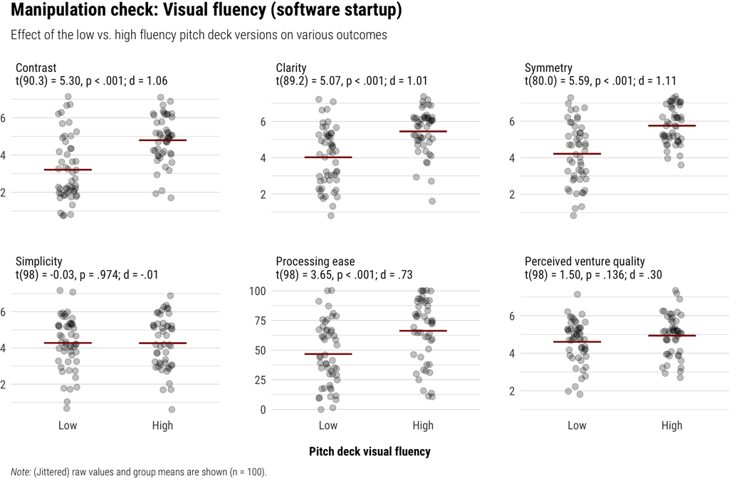

Figure A2: Summary of the fluency manipulation checks for the software startup

```r
mc_d <- mc_design_sw

# change factor labels for fluency
mc_d$fluency_condition <- factor(mc_d$fluency_condition, levels = c("high", "low"), labels = c("High", "Low"))

# create long dataset for plot
mc_long <- mc_d |> select(contrast:symmetry, fluency, quality, fluency_condition) |>
  tidyr::pivot_longer(contrast:quality, names_to="measure", values_to="value")

# create labels that include statistical inference
mc_str_contrast <- mc_ttest_str(contrast ~ fluency_condition, data = mc_d)
mc_str_clarity <- mc_ttest_str(clarity ~ fluency_condition, data = mc_d)
mc_str_symmetry <- mc_ttest_str(symmetry ~ fluency_condition, data = mc_d)
mc_str_simplicity <- mc_ttest_str(simplicity ~ fluency_condition, data = mc_d)
mc_str_fluency <- mc_ttest_str(fluency ~ fluency_condition, data = mc_d)
mc_str_quality <- mc_ttest_str(quality ~ fluency_condition, data = mc_d)

mc_str_fluency <- stringr::str_replace(mc_str_fluency, "Fluency", "Processing ease")
mc_str_quality <- stringr::str_replace(mc_str_quality, "Quality", "Perceived venture quality")

mc_long$measure <- factor(mc_long$measure, levels = c("contrast", "clarity", "symmetry", "simplicity", "fluency", "quality"),
                          labels = c(mc_str_contrast, mc_str_clarity, mc_str_symmetry, mc_str_simplicity, mc_str_fluency, mc_str_quality))

mc_long |> mutate(ymin = case_when(measure == "fluency" ~ 0,
                                   .default = 1),
                  ymax = case_when(measure == "fluency" ~ 100,
                                   .default = 7
                  )) -> mc_long

# plot result
ggplot(mc_long, aes(x=fluency_condition, y=value)) +
  geom_point(size = 2.5, alpha = 0.25, position=position_jitter(.1, seed = 42)) +
  stat_summary(color = "darkred", geom = "errorbar",
               fun.min = mean, fun = mean, fun.max = mean,
               width = .5, linewidth = 0.75) +
  facet_wrap(vars(measure), ncol = 3, scales = "free_y") +
  scale_x_discrete(limits = rev) +
  geom_blank(aes(y = ymin)) +
  geom_blank(aes(y = ymax)) +
  hrbrthemes::theme_ipsum_rc() +
  theme(panel.grid.major.x = element_blank(),
        plot.margin=grid::unit(c(1,0,3,0), "mm"),
        axis.title.x = element_text(hjust=0.5, margin=margin(t=15), size = 12, face = "bold"),
        axis.title.y = element_text(hjust=0.5),
        plot.caption = ggtext::element_markdown(hjust=0, size = 10)
  ) +
  labs(title="Manipulation check: Visual fluency (software startup)",
       subtitle = "Effect of the low vs. high fluency pitch deck versions on various outcomes",
       x = "Pitch deck visual fluency",
       y = NULL,
       caption = paste0("<i>Note:</i> ", "(Jittered) raw values and group means are shown (n = ", nrow(mc_d), ")."))
```

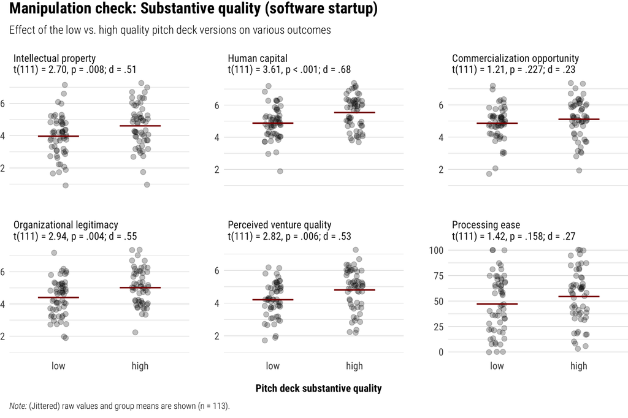

Figure A3: Summary of the quality manipulation checks for the software startup

```r
mc_d <- mc_quality_sw

# create long dataset for plot
mc_long <- mc_d |> select(intell_prop:legitim, quality, fluency, quality_condition) |>
  tidyr::pivot_longer(intell_prop:fluency, names_to="measure", values_to="value")

# create labels that include statistical inference
mc_str_intell_prop <- mc_ttest_str(intell_prop ~ quality_condition, data = mc_d)
mc_str_hum_cap <- mc_ttest_str(hum_cap ~ quality_condition, data = mc_d)
mc_str_commerc <- mc_ttest_str(commerc ~ quality_condition, data = mc_d)
mc_str_legitim <- mc_ttest_str(legitim ~ quality_condition, data = mc_d)
mc_str_quality <- mc_ttest_str(quality ~ quality_condition, data = mc_d)
mc_str_fluency <- mc_ttest_str(fluency ~ quality_condition, data = mc_d)

mc_str_intell_prop <- stringr::str_replace(mc_str_intell_prop, "Intell_prop", "Intellectual property")
mc_str_hum_cap <- stringr::str_replace(mc_str_hum_cap, "Hum_cap", "Human capital")
mc_str_commerc <- stringr::str_replace(mc_str_commerc, "Commerc", "Commercialization opportunity")
mc_str_legitim <- stringr::str_replace(mc_str_legitim, "Legitim", "Organizational legitimacy")
mc_str_quality <- stringr::str_replace(mc_str_quality, "Quality", "Perceived venture quality")
mc_str_fluency <- stringr::str_replace(mc_str_fluency, "Fluency", "Processing ease")

mc_long$measure <- factor(mc_long$measure, levels = c("intell_prop", "hum_cap", "commerc", "legitim","quality",  "fluency"),
                          labels = c(mc_str_intell_prop, mc_str_hum_cap, mc_str_commerc, mc_str_legitim, mc_str_quality, mc_str_fluency))

# create ymin and ymax for plot
mc_long |> mutate(ymin = case_when(measure == "fluency" ~ 0,
                                   .default = 1),
                  ymax = case_when(measure == "fluency" ~ 100,
                                   .default = 7
)) -> mc_long

# plot result
ggplot(mc_long, aes(x=quality_condition, y=value)) +
  geom_point(size = 2.5, alpha = 0.25, position=position_jitter(.1, seed = 42)) +
  stat_summary(color = "darkred", geom = "errorbar",
               fun.min = mean, fun = mean, fun.max = mean,
               width = .5, linewidth = 0.75) +
  facet_wrap(vars(measure), ncol = 3, scales = "free_y") +
  scale_x_discrete(limits = rev) +
  geom_blank(aes(y = ymin)) +
  geom_blank(aes(y = ymax)) +
  hrbrthemes::theme_ipsum_rc() +
  theme(panel.grid.major.x = element_blank(),
        plot.margin=grid::unit(c(1,0,3,0), "mm"),
        axis.title.x = element_text(hjust=0.5, margin=margin(t=15), size = 12, face = "bold"),
        axis.title.y = element_text(hjust=0.5),
        plot.caption = ggtext::element_markdown(hjust=0, size = 10)
  ) +
  labs(title="Manipulation check: Substantive quality (software startup)",
       subtitle = "Effect of the low vs. high quality pitch deck versions on various outcomes",
       x = "Pitch deck substantive quality",
       y = NULL,
       caption = paste0("<i>Note:</i> ", "(Jittered) raw values and group means are shown (n = ", nrow(mc_d), ")."))
```

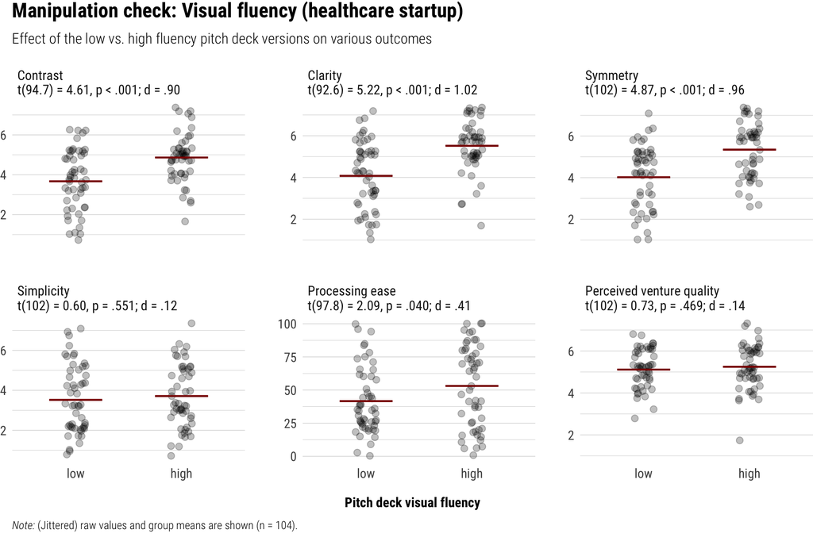

Figure A4: Summary of the fluency manipulation checks for the healthcare startup

```r
mc_d <- mc_design_hc

# create long dataset for plot
mc_long <- mc_d |> select(contrast:symmetry, fluency, quality, fluency_condition) |>
  tidyr::pivot_longer(contrast:quality, names_to="measure", values_to="value")

# create labels that include statistical inference
mc_str_contrast <- mc_ttest_str(contrast ~ fluency_condition, data = mc_d)
mc_str_clarity <- mc_ttest_str(clarity ~ fluency_condition, data = mc_d)
mc_str_symmetry <- mc_ttest_str(symmetry ~ fluency_condition, data = mc_d)
mc_str_simplicity <- mc_ttest_str(simplicity ~ fluency_condition, data = mc_d)
mc_str_fluency <- mc_ttest_str(fluency ~ fluency_condition, data = mc_d)
mc_str_quality <- mc_ttest_str(quality ~ fluency_condition, data = mc_d)

mc_str_fluency <- stringr::str_replace(mc_str_fluency, "Fluency", "Processing ease")
mc_str_quality <- stringr::str_replace(mc_str_quality, "Quality", "Perceived venture quality")

mc_long$measure <- factor(mc_long$measure, levels = c("contrast", "clarity", "symmetry", "simplicity", "fluency", "quality"),
                          labels = c(mc_str_contrast, mc_str_clarity, mc_str_symmetry, mc_str_simplicity, mc_str_fluency, mc_str_quality))

mc_long |> mutate(ymin = case_when(measure == "fluency" ~ 0,
                                   .default = 1),
                  ymax = case_when(measure == "fluency" ~ 100,
                                   .default = 7
                  )) -> mc_long

# plot result
ggplot(mc_long, aes(x=fluency_condition, y=value)) +
  geom_point(size = 2.5, alpha = 0.25, position=position_jitter(.1, seed = 42)) +
  stat_summary(color = "darkred", geom = "errorbar",
               fun.min = mean, fun = mean, fun.max = mean,
               width = .5, linewidth = 0.75) +
  facet_wrap(vars(measure), ncol = 3, scales = "free_y") +
  scale_x_discrete(limits = rev) +
  geom_blank(aes(y = ymin)) +
  geom_blank(aes(y = ymax)) +
  hrbrthemes::theme_ipsum_rc() +
  theme(panel.grid.major.x = element_blank(),
        plot.margin=grid::unit(c(1,0,3,0), "mm"),
        axis.title.x = element_text(hjust=0.5, margin=margin(t=15), size = 12, face = "bold"),
        axis.title.y = element_text(hjust=0.5),
        plot.caption = ggtext::element_markdown(hjust=0, size = 10)
  ) +
  labs(title="Manipulation check: Visual fluency (healthcare startup)",
       subtitle = "Effect of the low vs. high fluency pitch deck versions on various outcomes",
       x = "Pitch deck visual fluency",
       y = NULL,
       caption = paste0("<i>Note:</i> ", "(Jittered) raw values and group means are shown (n = ", nrow(mc_d), ")."))
```

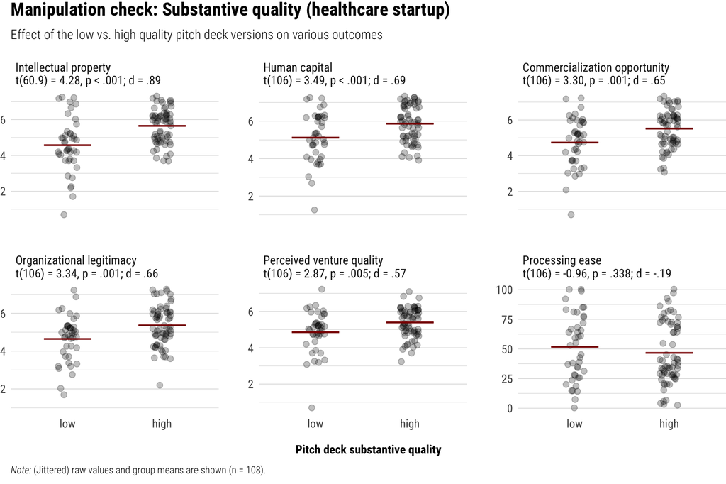

Figure A5: Summary of the quality manipulation checks for the healthcare startup

```r
mc_d <- mc_quality_hc

# create long dataset for plot
mc_long <- mc_d |> select(intell_prop:legitim, quality, fluency, quality_condition) |>
  tidyr::pivot_longer(intell_prop:fluency, names_to="measure", values_to="value")

# create labels that include statistical inference
mc_str_intell_prop <- mc_ttest_str(intell_prop ~ quality_condition, data = mc_d)
mc_str_hum_cap <- mc_ttest_str(hum_cap ~ quality_condition, data = mc_d)
mc_str_commerc <- mc_ttest_str(commerc ~ quality_condition, data = mc_d)
mc_str_legitim <- mc_ttest_str(legitim ~ quality_condition, data = mc_d)
mc_str_quality <- mc_ttest_str(quality ~ quality_condition, data = mc_d)
mc_str_fluency <- mc_ttest_str(fluency ~ quality_condition, data = mc_d)

mc_str_intell_prop <- stringr::str_replace(mc_str_intell_prop, "Intell_prop", "Intellectual property")
mc_str_hum_cap <- stringr::str_replace(mc_str_hum_cap, "Hum_cap", "Human capital")
mc_str_commerc <- stringr::str_replace(mc_str_commerc, "Commerc", "Commercialization opportunity")
mc_str_legitim <- stringr::str_replace(mc_str_legitim, "Legitim", "Organizational legitimacy")
mc_str_quality <- stringr::str_replace(mc_str_quality, "Quality", "Perceived venture quality")
mc_str_fluency <- stringr::str_replace(mc_str_fluency, "Fluency", "Processing ease")

mc_long$measure <- factor(mc_long$measure, levels = c("intell_prop", "hum_cap", "commerc", "legitim","quality",  "fluency"),
                          labels = c(mc_str_intell_prop, mc_str_hum_cap, mc_str_commerc, mc_str_legitim, mc_str_quality, mc_str_fluency))

# create ymin and ymax for plot
mc_long |> mutate(ymin = case_when(measure == "fluency" ~ 0,
                                   .default = 1),
                  ymax = case_when(measure == "fluency" ~ 100,
                                   .default = 7
)) -> mc_long

# plot result
ggplot(mc_long, aes(x=quality_condition, y=value)) +
  geom_point(size = 2.5, alpha = 0.25, position=position_jitter(.1, seed = 42)) +
  stat_summary(color = "darkred", geom = "errorbar",
               fun.min = mean, fun = mean, fun.max = mean,
               width = .5, linewidth = 0.75) +
  facet_wrap(vars(measure), ncol = 3, scales = "free_y") +
  scale_x_discrete(limits = rev) +
  geom_blank(aes(y = ymin)) +
  geom_blank(aes(y = ymax)) +
  hrbrthemes::theme_ipsum_rc() +
  theme(panel.grid.major.x = element_blank(),
        plot.margin=grid::unit(c(1,0,3,0), "mm"),
        axis.title.x = element_text(hjust=0.5, margin=margin(t=15), size = 12, face = "bold"),
        axis.title.y = element_text(hjust=0.5),
        plot.caption = ggtext::element_markdown(hjust=0, size = 10)
  ) +
  labs(title="Manipulation check: Substantive quality (healthcare startup)",
       subtitle = "Effect of the low vs. high quality pitch deck versions on various outcomes",
       x = "Pitch deck substantive quality",
       y = NULL,
       caption = paste0("<i>Note:</i> ", "(Jittered) raw values and group means are shown (n = ", nrow(mc_d), ")."))
```

## 3.3 LLM checks of the pitch decks

The LLM ratings, the prompts, and further analyses are documented in the LLM Ratings Reproducibility Report.

```r
# LLM checks of the pitch decks (not preregistered)
#
# ratings (one row per call and item), pitch decks of Studies 3 and 4: items of
# the human visual and quality questionnaires and the additional visual questions
llm_flu <- readr::read_csv(here(raw_dir, 'LLM_Panel_Studies_3_4_Decks_Fluency_Items.csv')) |> llm_prep()
llm_qua <- readr::read_csv(here(raw_dir, 'LLM_Panel_Studies_3_4_Decks_Quality_Items.csv')) |> llm_prep()
llm_vis <- readr::read_csv(here(raw_dir, 'LLM_Panel_Studies_3_4_Decks_Specific_Visual_Items.csv')) |> llm_prep()
# single-factor decks of the manipulation checks
llm_flu_mc <- readr::read_csv(here(raw_dir, 'LLM_Panel_MC_Decks_Fluency_Items.csv')) |> llm_prep()
llm_qua_mc <- readr::read_csv(here(raw_dir, 'LLM_Panel_MC_Decks_Quality_Items.csv')) |> llm_prep()
llm_vis_mc <- readr::read_csv(here(raw_dir, 'LLM_Panel_MC_Decks_Specific_Visual_Items.csv')) |> llm_prep()
# modified decks: text removed (visual questionnaire) and visual design removed
# (quality questionnaire)
llm_flu_notext <- readr::read_csv(here(raw_dir, 'LLM_Panel_Text_Removed_Fluency_Items.csv')) |> llm_prep()
llm_qua_nodesign <- readr::read_csv(here(raw_dir, 'LLM_Panel_Design_Removed_Quality_Items.csv')) |> llm_prep()
# human manipulation checks (processed data), pooled across both startups
llm_mc_design <- bind_rows(readr::read_csv(here(processed_dir, 'MC_1_Design_Software.csv')),
                           readr::read_csv(here(processed_dir, 'MC_3_Design_Healthcare.csv')))
llm_mc_quality <- bind_rows(readr::read_csv(here(processed_dir, 'MC_2_Quality_Software.csv')),
                            readr::read_csv(here(processed_dir, 'MC_4_Quality_Healthcare.csv')))

# model names for the figure
llm_model_labels <- c("anthropic/claude-sonnet-5" = "Claude Sonnet 5",
                      "google/gemini-3.5-flash" = "Gemini 3.5 Flash",
                      "openai/gpt-5.4" = "GPT-5.4",
                      "moonshotai/kimi-k2.6" = "Kimi K2.6",
                      "xiaomi/mimo-v2.5" = "MiMo V2.5",
                      "minimax/minimax-m3" = "MiniMax M3",
                      "qwen/qwen3.7-plus" = "Qwen3.7-plus")

# retained calls (complete set of valid ratings) and planned calls (decks x 7
# models x 3 repetitions) per questionnaire and deck set
llm_calls_retained <- c(nrow(distinct(llm_flu, file, model, rep)), nrow(distinct(llm_qua, file, model, rep)),
                        nrow(distinct(llm_vis, file, model, rep)), nrow(distinct(llm_flu_mc, file, model, rep)),
                        nrow(distinct(llm_qua_mc, file, model, rep)), nrow(distinct(llm_vis_mc, file, model, rep)),
                        nrow(distinct(llm_flu_notext, file, model, rep)), nrow(distinct(llm_qua_nodesign, file, model, rep)))
llm_calls_planned <- c(n_distinct(llm_flu$file), n_distinct(llm_qua$file), n_distinct(llm_vis$file),
                       n_distinct(llm_flu_mc$file), n_distinct(llm_qua_mc$file), n_distinct(llm_vis_mc$file),
                       n_distinct(llm_flu_notext$file), n_distinct(llm_qua_nodesign$file)) * 7 * 3
llm_calls_missing <- llm_calls_planned - llm_calls_retained

# human questionnaire: visual fluency on the visual items and substantive
# quality on the quality items
llm_res_flu <- bind_rows(llm_contrast(llm_flu, "contrast", "fluency", "HF", "LF"),
                         llm_contrast(llm_flu, "clear", "fluency", "HF", "LF"),
                         llm_contrast(llm_flu, "symmetrical", "fluency", "HF", "LF"),
                         llm_contrast(llm_flu, "simplicity", "fluency", "HF", "LF"),
                         llm_contrast(llm_flu, "ease", "fluency", "HF", "LF"))
llm_res_qua <- bind_rows(llm_contrast(llm_qua, "ip", "quality", "HQ", "LQ"),
                         llm_contrast(llm_qua, "management", "quality", "HQ", "LQ"),
                         llm_contrast(llm_qua, "commercialization", "quality", "HQ", "LQ"),
                         llm_contrast(llm_qua, "legitimacy", "quality", "HQ", "LQ"),
                         llm_contrast(llm_qua, "overall", "quality", "HQ", "LQ"))
# cross-effects: substantive quality on the visual items and on processing ease,
# visual fluency on the quality items and on the venture quality item
llm_res_cross_qua <- bind_rows(llm_contrast(llm_flu, "contrast", "quality", "HQ", "LQ"),
                               llm_contrast(llm_flu, "clear", "quality", "HQ", "LQ"),
                               llm_contrast(llm_flu, "symmetrical", "quality", "HQ", "LQ"),
                               llm_contrast(llm_flu, "simplicity", "quality", "HQ", "LQ"),
                               llm_contrast(llm_flu, "ease", "quality", "HQ", "LQ"),
                               llm_contrast(llm_qua, "ease", "quality", "HQ", "LQ"))
llm_res_cross_flu <- bind_rows(llm_contrast(llm_qua, "ip", "fluency", "HF", "LF"),
                               llm_contrast(llm_qua, "management", "fluency", "HF", "LF"),
                               llm_contrast(llm_qua, "commercialization", "fluency", "HF", "LF"),
                               llm_contrast(llm_qua, "legitimacy", "fluency", "HF", "LF"),
                               llm_contrast(llm_qua, "overall", "fluency", "HF", "LF"),
                               llm_contrast(llm_flu, "potential", "fluency", "HF", "LF"))

# comparison with the human manipulation checks (single-factor decks): condition
# means of the human participants and of the models, pooled across both startups
llm_human <- data.frame(
  high = c(mean(llm_mc_design$contrast[llm_mc_design$fluency_condition == "high"]),
           mean(llm_mc_design$clarity[llm_mc_design$fluency_condition == "high"]),
           mean(llm_mc_design$symmetry[llm_mc_design$fluency_condition == "high"]),
           mean(llm_mc_design$simplicity[llm_mc_design$fluency_condition == "high"]),
           mean(llm_mc_design$fluency[llm_mc_design$fluency_condition == "high"]),
           mean(llm_mc_design$quality[llm_mc_design$fluency_condition == "high"]),
           mean(llm_mc_quality$intell_prop[llm_mc_quality$quality_condition == "high"]),
           mean(llm_mc_quality$hum_cap[llm_mc_quality$quality_condition == "high"]),
           mean(llm_mc_quality$commerc[llm_mc_quality$quality_condition == "high"]),
           mean(llm_mc_quality$legitim[llm_mc_quality$quality_condition == "high"]),
           mean(llm_mc_quality$quality[llm_mc_quality$quality_condition == "high"]),
           mean(llm_mc_quality$fluency[llm_mc_quality$quality_condition == "high"])),
  low = c(mean(llm_mc_design$contrast[llm_mc_design$fluency_condition == "low"]),
          mean(llm_mc_design$clarity[llm_mc_design$fluency_condition == "low"]),
          mean(llm_mc_design$symmetry[llm_mc_design$fluency_condition == "low"]),
          mean(llm_mc_design$simplicity[llm_mc_design$fluency_condition == "low"]),
          mean(llm_mc_design$fluency[llm_mc_design$fluency_condition == "low"]),
          mean(llm_mc_design$quality[llm_mc_design$fluency_condition == "low"]),
          mean(llm_mc_quality$intell_prop[llm_mc_quality$quality_condition == "low"]),
          mean(llm_mc_quality$hum_cap[llm_mc_quality$quality_condition == "low"]),
          mean(llm_mc_quality$commerc[llm_mc_quality$quality_condition == "low"]),
          mean(llm_mc_quality$legitim[llm_mc_quality$quality_condition == "low"]),
          mean(llm_mc_quality$quality[llm_mc_quality$quality_condition == "low"]),
          mean(llm_mc_quality$fluency[llm_mc_quality$quality_condition == "low"]))
)
llm_models <- data.frame(
  high = c(mean(llm_flu_mc$rating[llm_flu_mc$item == "contrast" & llm_flu_mc$fluency == "HF"]),
           mean(llm_flu_mc$rating[llm_flu_mc$item == "clear" & llm_flu_mc$fluency == "HF"]),
           mean(llm_flu_mc$rating[llm_flu_mc$item == "symmetrical" & llm_flu_mc$fluency == "HF"]),
           mean(llm_flu_mc$rating[llm_flu_mc$item == "simplicity" & llm_flu_mc$fluency == "HF"]),
           mean(llm_flu_mc$rating[llm_flu_mc$item == "ease" & llm_flu_mc$fluency == "HF"]),
           mean(llm_flu_mc$rating[llm_flu_mc$item == "potential" & llm_flu_mc$fluency == "HF"]),
           mean(llm_qua_mc$rating[llm_qua_mc$item == "ip" & llm_qua_mc$quality == "HQ"]),
           mean(llm_qua_mc$rating[llm_qua_mc$item == "management" & llm_qua_mc$quality == "HQ"]),
           mean(llm_qua_mc$rating[llm_qua_mc$item == "commercialization" & llm_qua_mc$quality == "HQ"]),
           mean(llm_qua_mc$rating[llm_qua_mc$item == "legitimacy" & llm_qua_mc$quality == "HQ"]),
           mean(llm_qua_mc$rating[llm_qua_mc$item == "overall" & llm_qua_mc$quality == "HQ"]),
           mean(llm_qua_mc$rating[llm_qua_mc$item == "ease" & llm_qua_mc$quality == "HQ"])),
  low = c(mean(llm_flu_mc$rating[llm_flu_mc$item == "contrast" & llm_flu_mc$fluency == "LF"]),
          mean(llm_flu_mc$rating[llm_flu_mc$item == "clear" & llm_flu_mc$fluency == "LF"]),
          mean(llm_flu_mc$rating[llm_flu_mc$item == "symmetrical" & llm_flu_mc$fluency == "LF"]),
          mean(llm_flu_mc$rating[llm_flu_mc$item == "simplicity" & llm_flu_mc$fluency == "LF"]),
          mean(llm_flu_mc$rating[llm_flu_mc$item == "ease" & llm_flu_mc$fluency == "LF"]),
          mean(llm_flu_mc$rating[llm_flu_mc$item == "potential" & llm_flu_mc$fluency == "LF"]),
          mean(llm_qua_mc$rating[llm_qua_mc$item == "ip" & llm_qua_mc$quality == "LQ"]),
          mean(llm_qua_mc$rating[llm_qua_mc$item == "management" & llm_qua_mc$quality == "LQ"]),
          mean(llm_qua_mc$rating[llm_qua_mc$item == "commercialization" & llm_qua_mc$quality == "LQ"]),
          mean(llm_qua_mc$rating[llm_qua_mc$item == "legitimacy" & llm_qua_mc$quality == "LQ"]),
          mean(llm_qua_mc$rating[llm_qua_mc$item == "overall" & llm_qua_mc$quality == "LQ"]),
          mean(llm_qua_mc$rating[llm_qua_mc$item == "ease" & llm_qua_mc$quality == "LQ"]))
)
llm_human$diff <- llm_human$high - llm_human$low
llm_models$diff <- llm_models$high - llm_models$low
```

```r
# agreement between the seven models (pitch decks of Studies 3 and 4): mean of
# the four visual items and mean of the five quality items
llm_rel_flu <- llm_reliability(llm_flu, c("contrast", "clear", "symmetrical", "simplicity"))
llm_rel_qua <- llm_reliability(llm_qua, c("ip", "management", "commercialization", "legitimacy", "overall"))

# additional visual questions: visual fluency on the four visual items and the
# venture potential item, substantive quality on the revised ease item
llm_res_vis <- bind_rows(llm_contrast(llm_vis, "contrast", "fluency", "HF", "LF"),
                         llm_contrast(llm_vis, "clear", "fluency", "HF", "LF"),
                         llm_contrast(llm_vis, "symmetrical", "fluency", "HF", "LF"),
                         llm_contrast(llm_vis, "simplicity", "fluency", "HF", "LF"))
llm_vis_potential <- llm_contrast(llm_vis, "potential", "fluency", "HF", "LF")
llm_vis_ease_quality <- llm_contrast(llm_vis, "ease", "quality", "HQ", "LQ")

# removal checks: complete decks (same decks as the modified decks) vs. decks
# without text (visual items, high quality decks) and decks in plain formatting
# (quality items, high fluency decks)
llm_flu_hq <- llm_flu |> filter(quality == "HQ")
llm_qua_hf <- llm_qua |> filter(fluency == "HF")
llm_removal_flu_full <- bind_rows(llm_contrast(llm_flu_hq, "contrast", "fluency", "HF", "LF"),
                                  llm_contrast(llm_flu_hq, "clear", "fluency", "HF", "LF"),
                                  llm_contrast(llm_flu_hq, "symmetrical", "fluency", "HF", "LF"),
                                  llm_contrast(llm_flu_hq, "simplicity", "fluency", "HF", "LF"))
llm_removal_flu <- bind_rows(llm_contrast(llm_flu_notext, "contrast", "fluency", "HF", "LF"),
                             llm_contrast(llm_flu_notext, "clear", "fluency", "HF", "LF"),
                             llm_contrast(llm_flu_notext, "symmetrical", "fluency", "HF", "LF"),
                             llm_contrast(llm_flu_notext, "simplicity", "fluency", "HF", "LF"))
llm_removal_qua_full <- bind_rows(llm_contrast(llm_qua_hf, "ip", "quality", "HQ", "LQ"),
                                  llm_contrast(llm_qua_hf, "management", "quality", "HQ", "LQ"),
                                  llm_contrast(llm_qua_hf, "commercialization", "quality", "HQ", "LQ"),
                                  llm_contrast(llm_qua_hf, "legitimacy", "quality", "HQ", "LQ"),
                                  llm_contrast(llm_qua_hf, "overall", "quality", "HQ", "LQ"))
llm_removal_qua <- bind_rows(llm_contrast(llm_qua_nodesign, "ip", "quality", "HQ", "LQ"),
                             llm_contrast(llm_qua_nodesign, "management", "quality", "HQ", "LQ"),
                             llm_contrast(llm_qua_nodesign, "commercialization", "quality", "HQ", "LQ"),
                             llm_contrast(llm_qua_nodesign, "legitimacy", "quality", "HQ", "LQ"),
                             llm_contrast(llm_qua_nodesign, "overall", "quality", "HQ", "LQ"))
# difference for the decks in plain formatting as a percentage of the difference
# for the complete decks
llm_retained_qua <- llm_removal_qua$estimate / llm_removal_qua_full$estimate * 100

# substantive-quality scores (q-scores) of Studies 3 and 4 (AsPredicted
# Preregistration #304145): mean of the perceived venture quality item per startup,
# quality level, and model, then mean across the seven models, rescaled to 0-1
llm_qscores <- llm_qua |> filter(item == "overall") |>
  group_by(startup, quality, model) |> summarize(rating = mean(rating), .groups = "drop") |>
  group_by(startup, quality) |> summarize(q = (mean(rating) - 1) / 6, models = n(), .groups = "drop")
llm_qscores_wide <- llm_qscores |> tidyr::pivot_wider(id_cols = startup, names_from = quality, values_from = q)
llm_qscores_wide$diff <- llm_qscores_wide$HQ - llm_qscores_wide$LQ
```

**Note: The following analysis was not preregistered.** For the pitch decks of Studies 3 and 4 (the four versions of each of the eight AI startups), we extended the manipulation checks with seven vision-capable large language models (LLMs) from different developers, accessed through OpenRouter: Claude Sonnet 5, GPT-5.4, Gemini 3.5 Flash, MiniMax M3, Qwen3.7-plus, MiMo V2.5, and Kimi K2.6. In each call, a model received all slides of one deck as images together with either the visual or the quality questionnaire of the human manipulation checks (same items and response scales) and returned a rating and a brief reference to supporting slide content for each item. Simplicity is the reverse-coded complexity rating. Each model rated each deck three times per questionnaire. The models also rated the 8 single-factor decks of the manipulation checks for Studies 1 and 2, which allows a direct comparison with the human ratings. Across these questionnaires, the additional visual questions, and the removal checks (see Section 3.4), 3,018 of the 3,024 planned calls returned a complete set of valid ratings. The other 6 calls failed or returned incomplete ratings (decks of Studies 3 and 4 with the human visual questionnaire: 1, with the quality questionnaire: 3, with the additional visual questions: 1, and decks without text: 1).

For each item and startup, we averaged the ratings across the models, the repetitions, and the two versions of the other manipulated factor, which gives a high and a low condition mean per startup. The difference between the conditions is the mean of the eight startup-level differences, reported with a percentile bootstrap 95% confidence interval (4,000 resamples of the startups), the paired standardized effect (Cohen’s d<sub>z</sub>), and the p-value of an exact two-sided Wilcoxon signed-rank test. Thus, the startups are the units of analysis, and the repeated model ratings are not treated as independent observations. With eight startups, the smallest possible p-value of this test is .008, which results if the difference has the same sign for all eight startups. Table A3, Panel A reports the effects of each manipulation on the items it targeted, and Panel B its effects on the items of the other construct. For the single-factor decks, Panel C compares the condition means of the models with those of the human participants, both pooled across the software and the healthcare startup. The reliability of the ratings of the 32 decks of Studies 3 and 4 (Panel D) is based on the mean of the four visual items and the mean of the five quality items per deck and model. ICC(2,1) is the reliability of a single model and ICC(2,7) that of the average of the seven models (two-way random effects, absolute agreement). The weighted κ is the quadratic-weighted Cohen’s κ between two models, averaged across the 21 pairs of models and across the items (per item, a model’s three ratings of a deck were averaged and rounded). The 0–100 processing-ease item is not part of these means.

*Results.* Across the eight AI startups, high-fluency decks received higher ratings of contrast, clarity, symmetry, simplicity, and processing ease (all *p* = .008). Processing ease averaged 87.51 for high-fluency and 84.20 for low-fluency decks, a difference of 3.31 points (95% CI [2.85, 3.78]). High-quality decks received higher ratings on all four substantive dimensions and perceived venture quality (all *p* = .008). Perceived venture quality averaged 6.00 versus 3.42, a difference of 2.58 points (95% CI [2.44, 2.72]). The effects on the ratings of the other construct were smaller: substantive quality changed the four visual ratings by 0.02 to 0.20 points, and visual fluency changed the five quality ratings by -0.01 to 0.04 points. In the visual questionnaire, the effect of visual fluency on the separate perceived venture quality item was 0.01 points (95% CI [-0.04, 0.07], *p* = .742). Substantive quality also increased the processing-ease ratings in the quality questionnaire by 2.01 points (95% CI [1.59, 2.40], *p* = .008), so the models’ processing-ease ratings responded to substantive content as well as to visual design.

On the single-factor decks, the models, like the human participants, rated the high-fluency versions as easier to process and the high-quality versions as substantively stronger (Table A3, Panel C). The direction of the difference agreed in 11 of the 12 comparisons, with the perceived venture quality item of the visual questionnaire as the exception, and the models’ differences were mostly larger than the human participants’. The reliability of the seven-model average was .909 for visual design and .990 for substantive quality (ICC(2,7)). The corresponding single-model ICCs were .589 and .934, and the mean pairwise weighted κ values were .285 and .867 (Table A3, Panel D).

```r
bind_rows(llm_res_flu, llm_res_qua) |>
  mutate(Item = c("Contrast", "Clarity", "Symmetry", "Simplicity", "Processing ease",
                  "Intellectual property", "Human capital", "Commercialization opportunity",
                  "Organizational legitimacy", "Perceived venture quality"),
         High = f2(high), Low = f2(low), Difference = f2(estimate), CI = ci_txt(lower, upper),
         d = weights::rd(d, 2), p = p_tbl(p)) |>
  select(Item, High, Low, Difference, CI, d, p) |>
  kbl(col.names = c("Item", "High", "Low", "Difference", "95% CI", "d<sub>z</sub>", "p"),
      caption = "Table A3, Panel A: LLM manipulation checks with the human questionnaire, targeted items",
      align = "lcccccc", escape = FALSE) |>
  kable_styling() |>
  add_header_above(c(" " = 1, "Mean rating" = 2, " " = 4)) |>
  column_spec(c(1, 5), extra_css = "white-space: nowrap;", include_thead = TRUE) |>
  pack_rows(index = c("Visual fluency (visual questionnaire)" = 5, "Substantive quality (quality questionnaire)" = 5),
            label_row_css = "text-align: center;") |>
  repeat_header()
```

Table A3, Panel A: LLM manipulation checks with the human questionnaire, targeted items

| Item | Mean rating High | Mean rating Low | Difference | 95% CI | d<sub>z</sub> | p |
| --- | --- | --- | --- | --- | --- | --- |
| **Visual fluency (visual questionnaire)** |  |  |  |  |  |  |
| Contrast | 4.99 | 3.29 | 1.69 | [1.55, 1.83] | 7.57 | .008 |
| Clarity | 6.33 | 6.02 | 0.31 | [0.21, 0.42] | 1.88 | .008 |
| Symmetry | 5.14 | 4.31 | 0.83 | [0.54, 1.11] | 1.87 | .008 |
| Simplicity | 5.85 | 5.72 | 0.12 | [0.08, 0.17] | 1.81 | .008 |
| Processing ease | 87.51 | 84.20 | 3.31 | [2.85, 3.78] | 4.53 | .008 |
|  | Mean rating |  |  |  |  |  |
| Item | High | Low | Difference | 95% CI | d<sub>z</sub> | p |
| **Substantive quality (quality questionnaire)** |  |  |  |  |  |  |
| Intellectual property | 5.77 | 2.76 | 3.01 | [2.73, 3.32] | 6.59 | .008 |
| Human capital | 6.80 | 2.05 | 4.75 | [4.64, 4.85] | 29.43 | .008 |
| Commercialization opportunity | 5.95 | 4.06 | 1.90 | [1.69, 2.14] | 5.36 | .008 |
| Organizational legitimacy | 5.91 | 3.01 | 2.89 | [2.68, 3.10] | 8.80 | .008 |
| Perceived venture quality | 6.00 | 3.42 | 2.58 | [2.44, 2.72] | 11.46 | .008 |

```r
bind_rows(llm_res_cross_qua, llm_res_cross_flu) |>
  mutate(Item = c("Contrast", "Clarity", "Symmetry", "Simplicity", "Processing ease", "Processing ease",
                  "Intellectual property", "Human capital", "Commercialization opportunity",
                  "Organizational legitimacy", "Perceived venture quality", "Perceived venture quality"),
         Questionnaire = c(rep("Visual", 5), "Quality", rep("Quality", 5), "Visual"),
         Difference = f2(estimate), CI = ci_txt(lower, upper), d = weights::rd(d, 2), p = p_tbl(p)) |>
  select(Item, Questionnaire, Difference, CI, d, p) |>
  kbl(col.names = c("Item", "Questionnaire", "Difference", "95% CI", "d<sub>z</sub>", "p"),
      caption = "Table A3, Panel B: LLM manipulation checks with the human questionnaire, items of the other construct",
      align = "llcccc", escape = FALSE) |>
  kable_styling() |>
  column_spec(c(1, 4), extra_css = "white-space: nowrap;", include_thead = TRUE) |>
  pack_rows(index = c("Substantive quality (high minus low quality)" = 6, "Visual fluency (high minus low fluency)" = 6),
            label_row_css = "text-align: center;") |>
  repeat_header()
```

Table A3, Panel B: LLM manipulation checks with the human questionnaire, items of the other construct

| Item | Questionnaire | Difference | 95% CI | d<sub>z</sub> | p |
| --- | --- | --- | --- | --- | --- |
| **Substantive quality (high minus low quality)** |  |  |  |  |  |
| Contrast | Visual | 0.20 | [0.16, 0.24] | 3.12 | .008 |
| Clarity | Visual | 0.13 | [0.09, 0.17] | 1.99 | .008 |
| Symmetry | Visual | 0.03 | [-0.06, 0.13] | .22 | .461 |
| Simplicity | Visual | 0.02 | [-0.01, 0.05] | .48 | .242 |
| Processing ease | Visual | 1.61 | [1.14, 2.17] | 1.96 | .008 |
| Processing ease | Quality | 2.01 | [1.59, 2.40] | 3.19 | .008 |
| Item | Questionnaire | Difference | 95% CI | d<sub>z</sub> | p |
| **Visual fluency (high minus low fluency)** |  |  |  |  |  |
| Intellectual property | Quality | 0.03 | [-0.00, 0.06] | .59 | .125 |
| Human capital | Quality | 0.00 | [-0.05, 0.06] | .01 | .906 |
| Commercialization opportunity | Quality | 0.02 | [-0.03, 0.07] | .20 | .625 |
| Organizational legitimacy | Quality | 0.04 | [-0.00, 0.09] | .59 | .141 |
| Perceived venture quality | Quality | -0.01 | [-0.09, 0.06] | -.12 | .742 |
| Perceived venture quality | Visual | 0.01 | [-0.04, 0.07] | .14 | .742 |

```r
data.frame(
  Item = c("Contrast", "Clarity", "Symmetry", "Simplicity", "Processing ease", "Perceived venture quality",
           "Intellectual property", "Human capital", "Commercialization opportunity",
           "Organizational legitimacy", "Perceived venture quality", "Processing ease"),
  human_high = f2(llm_human$high), human_low = f2(llm_human$low), human_diff = f2(llm_human$diff),
  model_high = f2(llm_models$high), model_low = f2(llm_models$low), model_diff = f2(llm_models$diff),
  same = ifelse(sign(llm_human$diff) == sign(llm_models$diff), "Yes", "No")
) |>
  kbl(col.names = c("Item", "High", "Low", "Diff.", "High", "Low", "Diff.", "Same sign"),
      caption = "Table A3, Panel C: Comparison with the human manipulation checks (single-factor decks)",
      align = "lccccccc", escape = FALSE) |>
  kable_styling() |>
  add_header_above(c(" " = 1, "Human participants" = 3, "LLMs" = 3, " " = 1)) |>
  column_spec(c(1, 8), extra_css = "white-space: nowrap;", include_thead = TRUE) |>
  pack_rows(index = c("Visual fluency (visual questionnaire)" = 6, "Substantive quality (quality questionnaire)" = 6),
            label_row_css = "text-align: center;") |>
  repeat_header()
```

Table A3, Panel C: Comparison with the human manipulation checks (single-factor decks)

| Item | Human participants High | Human participants Low | Human participants Diff. | LLMs High | LLMs Low | LLMs Diff. | Same sign |
| --- | --- | --- | --- | --- | --- | --- | --- |
| **Visual fluency (visual questionnaire)** |  |  |  |  |  |  |  |
| Contrast | 4.83 | 3.45 | 1.39 | 5.29 | 2.88 | 2.40 | Yes |
| Clarity | 5.49 | 4.05 | 1.44 | 6.19 | 4.67 | 1.52 | Yes |
| Symmetry | 5.54 | 4.12 | 1.43 | 5.98 | 3.64 | 2.33 | Yes |
| Simplicity | 3.98 | 3.89 | 0.09 | 5.81 | 4.93 | 0.88 | Yes |
| Processing ease | 59.48 | 44.13 | 15.35 | 86.74 | 68.43 | 18.31 | Yes |
| Perceived venture quality | 5.10 | 4.86 | 0.23 | 5.26 | 5.31 | -0.05 | No |
|  | Human participants |  |  | LLMs |  |  |  |
| Item | High | Low | Diff. | High | Low | Diff. | Same sign |
| **Substantive quality (quality questionnaire)** |  |  |  |  |  |  |  |
| Intellectual property | 5.17 | 4.22 | 0.95 | 5.31 | 2.19 | 3.12 | Yes |
| Human capital | 5.71 | 4.98 | 0.73 | 6.26 | 3.86 | 2.40 | Yes |
| Commercialization opportunity | 5.33 | 4.81 | 0.52 | 5.60 | 3.50 | 2.10 | Yes |
| Organizational legitimacy | 5.20 | 4.51 | 0.70 | 5.55 | 2.33 | 3.21 | Yes |
| Perceived venture quality | 5.12 | 4.48 | 0.64 | 5.71 | 3.33 | 2.38 | Yes |
| Processing ease | 50.21 | 49.09 | 1.12 | 87.93 | 84.50 | 3.43 | Yes |

```r
bind_rows(llm_rel_flu, llm_rel_qua) |>
  mutate(Scale = c("Visual design (four visual items)", "Substantive quality (five quality items)"),
         icc_1 = weights::rd(icc_1, 3), icc_k = weights::rd(icc_k, 3), kappa = weights::rd(kappa, 3)) |>
  select(Scale, decks, models, icc_1, icc_k, kappa) |>
  kbl(col.names = c("Scale", "Decks", "Models", "ICC(2,1)", "ICC(2,7)", "Weighted κ"),
      caption = "Table A3, Panel D: Reliability of the LLM ratings (pitch decks of Studies 3 and 4)",
      align = "lccccc", escape = FALSE) |>
  kable_styling() |>
  column_spec(1, extra_css = "white-space: nowrap;", include_thead = TRUE)
```

Table A3, Panel D: Reliability of the LLM ratings (pitch decks of Studies 3 and 4)

| Scale | Decks | Models | ICC(2,1) | ICC(2,7) | Weighted κ |
| --- | --- | --- | --- | --- | --- |
| Visual design (four visual items) | 32 | 7 | .589 | .909 | .285 |
| Substantive quality (five quality items) | 32 | 7 | .934 | .990 | .867 |

*Notes:* Panels A, B, and D are based on the 32 pitch decks of Studies 3 and 4, Panel C on the 8 single-factor decks of the manipulation checks. Processing ease was rated on a scale from 0–100, all other items on 1–7 scales. Simplicity is the reverse-coded complexity rating, and the intellectual-property item measured organizational capital. In Panels A and B, High and Low are the means of the eight startup-level condition means, differences are high minus low, confidence intervals are percentile bootstrap intervals (4,000 resamples of the startups), d<sub>z</sub> is the mean startup-level difference divided by its standard deviation, and p-values are from exact two-sided Wilcoxon signed-rank tests of the eight startup-level differences. In Panel C, the human ratings are those of the 204 participants of the two visual checks and the 221 participants of the two quality checks, and all means are pooled across the software and the healthcare startup. In Panel D, the scale scores are the means of the items per deck and model. κ is not defined if two models gave all decks the same rating on an item, which was the case for 6 of the 84 combinations of model pairs and visual items (0 of 105 for the quality items), and these combinations are not part of the averages.

## 3.4 Additional visual questions and removal checks

**Note: The following analysis was not preregistered.** The models also rated the 32 decks of Studies 3 and 4 with a later questionnaire of more specific visual questions (labeled “specific visual items” in Figure A6): legibility of the text (clarity), color and tonal strength (contrast), left-right balance (symmetry), and clutter on the visual surface (simplicity), each on a 1–7 scale with described anchors, a revised ease question that focuses on taking in the deck visually (0–100), and the venture’s potential judged from the substance alone. These questions form a separate instrument and do not replace the results using the human questionnaire. To assess what the ratings reflected, the models also rated two modified versions of the decks: the 16 high-quality decks with all readable text removed and the visual design kept (human visual questionnaire), and the 16 high-fluency decks in plain formatting with the text kept (quality questionnaire). Each comparison used the same complete decks as its baseline. All tests are those of Table A3. The complete item results, the reliability of the later questions, and the matched contrasts of the removal checks are in the LLM Ratings Reproducibility Report.

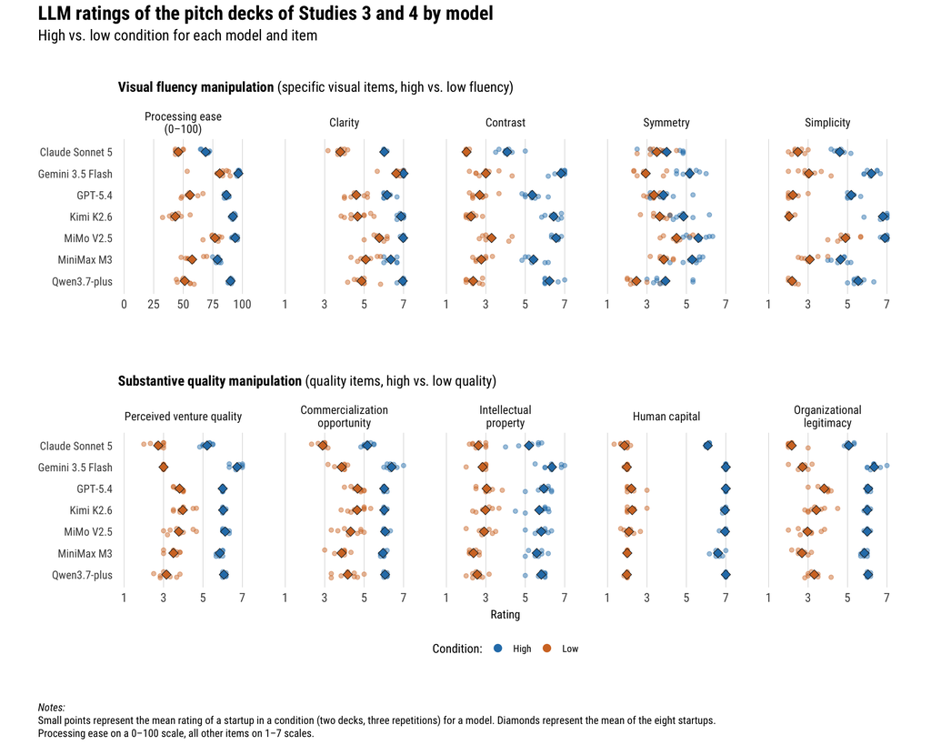

Figure A6: LLM ratings of the pitch decks of Studies 3 and 4 by model

```r
# aesthetics
#
# colors of the high and the low condition: the main blue and a burnt orange as
# its complementary color
llm_col_high <- blue_main
llm_col_low <- "#D4772C"

# theme settings
llm_theme <- theme(panel.grid.major.y = element_blank(),
                   panel.grid.minor = element_blank(),
                   plot.title = element_markdown(size = 13, family = "Roboto Condensed", face = "plain", hjust = 0),
                   strip.text = element_text(size = 11, hjust = .5),
                   axis.title.x = element_text(size = 11, hjust = .5, margin = margin(t = 5, r = 0, b = 0, l = 0)),
                   axis.text.y = element_text(size = 10.5),
                   legend.position = "bottom")

# data prep
#
# mean rating per model, startup, item, and condition (i.e., across the two
# decks of a startup and condition and the three repetitions)
llm_fig_vis <- llm_vis |>
  filter(item %in% c("ease", "clear", "contrast", "symmetrical", "simplicity")) |>
  group_by(model, startup, item, level = fluency) |>
  summarize(rating = mean(rating), .groups = "drop")
llm_fig_qua <- llm_qua |>
  filter(item %in% c("overall", "commercialization", "ip", "management", "legitimacy")) |>
  group_by(model, startup, item, level = quality) |>
  summarize(rating = mean(rating), .groups = "drop")
# labels
llm_fig_vis$item <- factor(llm_fig_vis$item, levels = c("ease", "clear", "contrast", "symmetrical", "simplicity"),
                           labels = c("Processing ease\n(0–100)", "Clarity", "Contrast", "Symmetry", "Simplicity"))
llm_fig_qua$item <- factor(llm_fig_qua$item, levels = c("overall", "commercialization", "ip", "management", "legitimacy"),
                           labels = c("Perceived venture quality", "Commercialization\nopportunity", "Intellectual\nproperty",
                                      "Human capital", "Organizational\nlegitimacy"))
llm_fig_vis$level <- factor(llm_fig_vis$level, levels = c("HF", "LF"), labels = c("High", "Low"))
llm_fig_qua$level <- factor(llm_fig_qua$level, levels = c("HQ", "LQ"), labels = c("High", "Low"))
# models in alphabetical order (from top to bottom)
llm_fig_vis$model <- factor(llm_model_labels[llm_fig_vis$model], levels = rev(llm_model_labels))
llm_fig_qua$model <- factor(llm_model_labels[llm_fig_qua$model], levels = rev(llm_model_labels))
# means per model and condition
llm_fig_vis |> group_by(model, item, level) |> summarize(rating = mean(rating), .groups = "drop") -> llm_fig_vis_means
llm_fig_qua |> group_by(model, item, level) |> summarize(rating = mean(rating), .groups = "drop") -> llm_fig_qua_means
# scale limits (processing ease: 0-100; all other items: 1-7)
llm_fig_vis_limits <- data.frame(item = factor(rep(levels(llm_fig_vis$item), each = 2), levels = levels(llm_fig_vis$item)),
                                 rating = c(0, 100, 1, 7, 1, 7, 1, 7, 1, 7), model = levels(llm_fig_vis$model)[1])

# figure: visual fluency (specific visual items)
llm_panel_1 <- ggplot(llm_fig_vis, aes(x = rating, y = model)) +
  geom_blank(data = llm_fig_vis_limits) +
  geom_point(aes(color = level), size = 1.6, alpha = .45,
             position = position_jitter(width = 0, height = .15, seed = 42)) +
  geom_point(data = llm_fig_vis_means, aes(fill = level), shape = 23, size = 3, color = "gray15", stroke = .4) +
  facet_wrap(vars(item), nrow = 1, scales = "free_x") +
  scale_x_continuous(breaks = function(lim) if(lim[2] > 10) c(0, 25, 50, 75, 100) else c(1, 3, 5, 7)) +
  scale_color_manual(values = c("High" = llm_col_high, "Low" = llm_col_low), name = "Condition:",
                     guide = guide_legend(override.aes = list(alpha = 1, size = 3))) +
  scale_fill_manual(values = c("High" = llm_col_high, "Low" = llm_col_low), guide = "none") +
  hrbrthemes::theme_ipsum_rc() + llm_theme +
  labs(x = NULL, y = NULL,
       title = "<b>Visual fluency manipulation</b> (specific visual items, high vs. low fluency)")

# figure: substantive quality (quality items)
llm_panel_2 <- ggplot(llm_fig_qua, aes(x = rating, y = model)) +
  geom_point(aes(color = level), size = 1.6, alpha = .45,
             position = position_jitter(width = 0, height = .15, seed = 42)) +
  geom_point(data = llm_fig_qua_means, aes(fill = level), shape = 23, size = 3, color = "gray15", stroke = .4) +
  facet_wrap(vars(item), nrow = 1) +
  scale_x_continuous(limits = c(1, 7), breaks = c(1, 3, 5, 7)) +
  scale_color_manual(values = c("High" = llm_col_high, "Low" = llm_col_low), name = "Condition:",
                     guide = guide_legend(override.aes = list(alpha = 1, size = 3))) +
  scale_fill_manual(values = c("High" = llm_col_high, "Low" = llm_col_low), guide = "none") +
  hrbrthemes::theme_ipsum_rc() + llm_theme +
  labs(x = "Rating", y = NULL,
       title = "<b>Substantive quality manipulation</b> (quality items, high vs. low quality)")

# final (combined) figure
llm_panel_1 / llm_panel_2 + plot_layout(guides = "collect") +
  plot_annotation(
    title = "<b>LLM ratings of the pitch decks of Studies 3 and 4 by model</b>",
    subtitle = "High vs. low condition for each model and item",
    caption = paste0("<i>Notes:</i><br>", "Small points represent the mean rating of a startup in a condition (two decks, three repetitions) for a model. ",
                     "Diamonds represent the mean of the eight startups.<br>",
                     "Processing ease on a 0–100 scale, all other items on 1–7 scales."),
    # --Note: `theme` inside `plot_annotation`, so that the titles of the two
    #         parts keep their (smaller) size
    theme = theme(
      plot.title = element_markdown(size = 18, family = "Roboto Condensed", face = "plain"),
      plot.subtitle = element_text(size = 14, family = "Roboto Condensed"),
      plot.caption.position = "plot", plot.caption = element_markdown(hjust = 0, lineheight = 1.2, family = "Roboto Condensed", size = 10, margin = margin(t = 7, r = 0, b = 0, l = 0)))
  ) & theme(legend.position = "bottom")
```

## 3.5 Substantive-quality scores

The LLM Ratings Reproducibility Report lists the score of each startup and quality level.

Studies 3 and 4 used a common substantive-quality score (q-score) to determine the performance bonuses. For each of the eight startups at each quality level, we averaged the perceived venture quality item of the quality questionnaire across both visual versions and the repetitions within each model (three per deck, two for three combinations of model and deck). We then averaged the seven model means and rescaled the result from the 1–7 scale to the range from 0 to 1, that is, q = (M − 1) / 6. This construction was preregistered for Study 3 (AsPredicted #304145), and Study 4 reused the same scores (AsPredicted #309446).

*Results.* The 16 scores ranged from .341 to .845, and each is based on all 7 models. Each startup’s high-quality version had a higher score than its low-quality version (differences from .389 to .484). Since each score averages across both visual versions, the high- and the low-fluency version of a deck received the same score, so the score rewarded identifying the stronger substantive case without a direct payoff advantage for visual design.

# 4 Benchmarking and Ecological Validity

This section reproduces the benchmark results of the paper and Appendix B. The contrast, simplicity, and symmetry scores of the real pitch decks, the text-based quality ratings, the construction of the scores, and further analyses are documented in the Deck Benchmarking Reproducibility Report. **Note that the following analyses were not preregistered.**

```r
# Benchmark against real pitch decks (not preregistered)
#
# contrast, simplicity, and symmetry scores of the real pitch decks (means across
# the slides of a deck)
bm_bench <- readr::read_csv(here(raw_dir, 'Pitchdeck_Benchmarks.csv'))
# text-based quality ratings of the real pitch decks: three prompt versions (a, b,
# c) per dimension and model, model-level scores, and dimension scores
bm_text <- readr::read_csv(here(raw_dir, 'Pitchdeck_Benchmarks_Text_Quality.csv'))
# archived responses without a rating ("I cannot determine")
bm_refusals <- readr::read_csv(here(raw_dir, 'Pitchdeck_Benchmarks_Text_Quality_Refusals.csv'))
# contrast, simplicity, and symmetry scores of the 40 experimental pitch decks
bm_decks <- readr::read_csv(here(raw_dir, 'Pitchdeck_Benchmarks_Experimental_Decks.csv'))
# founder characteristics and venture outcomes (as recorded by the VC firm)
bm_founders <- readr::read_csv(here(raw_dir, 'Pitchdeck_Benchmarks_Founders_Outcomes.csv'))

# one row per real pitch deck
bm_d <- bm_bench |> left_join(bm_text, by = "id")
# image-based fluency score: mean of the standardized contrast, simplicity, and
# symmetry scores
bm_d$fluency_score <- (as.numeric(scale(bm_d$contrast)) + as.numeric(scale(bm_d$simplicity)) +
                         as.numeric(scale(bm_d$symmetry))) / 3
# text-based quality score: mean of the four standardized dimension scores
# (i.e., without overall quality)
bm_d$quality_score <- (as.numeric(scale(bm_d$ip_score)) + as.numeric(scale(bm_d$hc_score)) +
                         as.numeric(scale(bm_d$co_score)) + as.numeric(scale(bm_d$ol_score))) / 4

# visual benchmark: percentile ranks of the experimental decks among the real
# decks (percentage of real decks with a score at or below the score of the deck)
bm_decks$contrast_pr <- ecdf(bm_bench$contrast)(bm_decks$contrast) * 100
bm_decks$simplicity_pr <- ecdf(bm_bench$simplicity)(bm_decks$simplicity) * 100
bm_decks$symmetry_pr <- ecdf(bm_bench$symmetry)(bm_decks$symmetry) * 100
# median percentile ranks of the high and the low fluency versions
bm_pr_hf <- c(contrast = median(bm_decks$contrast_pr[bm_decks$fluency == "HF"]),
              simplicity = median(bm_decks$simplicity_pr[bm_decks$fluency == "HF"]),
              symmetry = median(bm_decks$symmetry_pr[bm_decks$fluency == "HF"]))
bm_pr_lf <- c(contrast = median(bm_decks$contrast_pr[bm_decks$fluency == "LF"]),
              simplicity = median(bm_decks$simplicity_pr[bm_decks$fluency == "LF"]),
              symmetry = median(bm_decks$symmetry_pr[bm_decks$fluency == "LF"]))
# long format (one row per deck and measure)
bm_decks_long <- bm_decks |>
  tidyr::pivot_longer(c(contrast, simplicity, symmetry), names_to = "measure", values_to = "score") |>
  mutate(pr = case_when(measure == "contrast" ~ contrast_pr,
                        measure == "simplicity" ~ simplicity_pr,
                        measure == "symmetry" ~ symmetry_pr))

# scoring consistency: agreement across the three prompt versions (ICC(2,1)) per
# dimension and model
bm_icc_qwen <- c(llm_icc(bm_d[, c("ip_a_qwen", "ip_b_qwen", "ip_c_qwen")])[["icc_1"]],
                 llm_icc(bm_d[, c("hc_a_qwen", "hc_b_qwen", "hc_c_qwen")])[["icc_1"]],
                 llm_icc(bm_d[, c("co_a_qwen", "co_b_qwen", "co_c_qwen")])[["icc_1"]],
                 llm_icc(bm_d[, c("ol_a_qwen", "ol_b_qwen", "ol_c_qwen")])[["icc_1"]],
                 llm_icc(bm_d[, c("oq_a_qwen", "oq_b_qwen", "oq_c_qwen")])[["icc_1"]])
bm_icc_mistral <- c(llm_icc(bm_d[, c("ip_a_mistral", "ip_b_mistral", "ip_c_mistral")])[["icc_1"]],
                    llm_icc(bm_d[, c("hc_a_mistral", "hc_b_mistral", "hc_c_mistral")])[["icc_1"]],
                    llm_icc(bm_d[, c("co_a_mistral", "co_b_mistral", "co_c_mistral")])[["icc_1"]],
                    llm_icc(bm_d[, c("ol_a_mistral", "ol_b_mistral", "ol_c_mistral")])[["icc_1"]],
                    llm_icc(bm_d[, c("oq_a_mistral", "oq_b_mistral", "oq_c_mistral")])[["icc_1"]])
# agreement between the models (quadratic-weighted kappa of the rounded
# model-level scores)
bm_kappa <- c(irr::kappa2(cbind(round(bm_d$ip_score_qwen), round(bm_d$ip_score_mistral)), weight = "squared")$value,
              irr::kappa2(cbind(round(bm_d$hc_score_qwen), round(bm_d$hc_score_mistral)), weight = "squared")$value,
              irr::kappa2(cbind(round(bm_d$co_score_qwen), round(bm_d$co_score_mistral)), weight = "squared")$value,
              irr::kappa2(cbind(round(bm_d$ol_score_qwen), round(bm_d$ol_score_mistral)), weight = "squared")$value,
              irr::kappa2(cbind(round(bm_d$oq_score_qwen), round(bm_d$oq_score_mistral)), weight = "squared")$value)
# prompt sensitivity: percentage of decks for which the three ratings of at least
# one model differ by two or more points
bm_flip <- c(mean(bm_prompt_range(bm_d, c("ip_a_qwen", "ip_b_qwen", "ip_c_qwen")) >= 2 |
                    bm_prompt_range(bm_d, c("ip_a_mistral", "ip_b_mistral", "ip_c_mistral")) >= 2),
             mean(bm_prompt_range(bm_d, c("hc_a_qwen", "hc_b_qwen", "hc_c_qwen")) >= 2 |
                    bm_prompt_range(bm_d, c("hc_a_mistral", "hc_b_mistral", "hc_c_mistral")) >= 2),
             mean(bm_prompt_range(bm_d, c("co_a_qwen", "co_b_qwen", "co_c_qwen")) >= 2 |
                    bm_prompt_range(bm_d, c("co_a_mistral", "co_b_mistral", "co_c_mistral")) >= 2),
             mean(bm_prompt_range(bm_d, c("ol_a_qwen", "ol_b_qwen", "ol_c_qwen")) >= 2 |
                    bm_prompt_range(bm_d, c("ol_a_mistral", "ol_b_mistral", "ol_c_mistral")) >= 2),
             mean(bm_prompt_range(bm_d, c("oq_a_qwen", "oq_b_qwen", "oq_c_qwen")) >= 2 |
                    bm_prompt_range(bm_d, c("oq_a_mistral", "oq_b_mistral", "oq_c_mistral")) >= 2)) * 100

# relationship between fluency and quality: correlation of the two scores, of
# the three visual features with the four dimension scores, and of the fluency
# score with the rated human capital
bm_r_scores <- bm_cor(bm_d$fluency_score, bm_d$quality_score)
bm_r_features <- cor(bm_d[, c("contrast", "simplicity", "symmetry")], bm_d[, c("ip_score", "hc_score", "co_score", "ol_score")])
bm_r_hc <- bm_cor(bm_d$fluency_score, bm_d$hc_score)
# top-quality decks (highest quartile of the text-based quality score) and
# fluency groups (quartiles, deciles, and median split of the fluency score)
bm_d$quality_top <- bm_d$quality_score >= quantile(bm_d$quality_score, .75)
bm_d$fluency_quartile <- cut(bm_d$fluency_score, quantile(bm_d$fluency_score, 0:4 / 4),
                             include.lowest = TRUE, labels = FALSE)
bm_d$fluency_decile <- cut(bm_d$fluency_score, quantile(bm_d$fluency_score, 0:10 / 10),
                           include.lowest = TRUE, labels = FALSE)
bm_d$fluency_below_median <- bm_d$fluency_score < median(bm_d$fluency_score)
# decks, mean quality score (standardized across all decks), and top-quality
# decks per fluency quartile
bm_quartiles <- bm_d |>
  mutate(quality_z = as.numeric(scale(quality_score))) |>
  group_by(fluency_quartile) |>
  summarize(N = n(), mean_quality = mean(quality_z), top = sum(quality_top), .groups = "drop") |>
  mutate(share = top / N * 100)

# founder characteristics and venture outcomes
bm_d <- bm_d |> left_join(bm_founders, by = "id")
# prior funding raised (log-transformed, i.e., log(1 + x))
bm_d$log_prior_funding <- log1p(bm_d$prior_funding_raised)

# founder characteristics: linear regression of the fluency score
bm_lm_founders <- lm(fluency_score ~ founder_prior_exit + serial_founder + log_prior_funding + num_slides, data = bm_d)
bm_founders_coef <- coef(summary(bm_lm_founders))
bm_founders_ci <- confint(bm_lm_founders)

# venture outcomes: correlations with the fluency score and the quality score
bm_r_outcomes <- bind_rows(bm_cor(bm_d$fluency_score, bm_d$followon_funding),
                           bm_cor(bm_d$fluency_score, bm_d$survival),
                           bm_cor(bm_d$fluency_score, bm_d$exit_ipo_acq),
                           bm_cor(bm_d$quality_score, bm_d$followon_funding),
                           bm_cor(bm_d$quality_score, bm_d$survival),
                           bm_cor(bm_d$quality_score, bm_d$exit_ipo_acq))
# joint logistic regressions (both scores and funding by the partner firm), with
# 95% confidence intervals from the profile likelihood
bm_glm_followon <- glm(followon_funding ~ fluency_score + quality_score + funded_by_partner, data = bm_d, family = binomial)
bm_glm_survival <- glm(survival ~ fluency_score + quality_score + funded_by_partner, data = bm_d, family = binomial)
bm_glm_exit <- glm(exit_ipo_acq ~ fluency_score + quality_score + funded_by_partner, data = bm_d, family = binomial)
bm_glm_coef <- rbind(coef(summary(bm_glm_followon)), coef(summary(bm_glm_survival)), coef(summary(bm_glm_exit)))
bm_glm_ci <- rbind(suppressMessages(confint(bm_glm_followon)), suppressMessages(confint(bm_glm_survival)),
                   suppressMessages(confint(bm_glm_exit)))
```

## 4.1 Visual benchmark

We compared the 40 experimental pitch decks (the 8 versions of the software and the healthcare startup of Studies 1 and 2 and the 32 versions of the eight AI startups of Studies 3 and 4) with 3,510 real pitch decks submitted to a European VC firm focused on seed-stage investment. To maintain confidentiality, the firm computed the contrast, simplicity, and symmetry of its decks with an R script that uses the *imagefluency* package (Mayer, [2024](https://imagefluency.com/)), and the same measures were computed for the experimental decks. The deck-level scores are the means across the slides of a deck. For each measure, the percentile rank of an experimental deck is the percentage of real decks with a score at or below its score, and we report the median percentile rank of the high- and the low-fluency versions.

*Results.* All experimental decks lay within the observed ranges of the real decks on all three measures (contrast: .077 to .282, simplicity: .813 to .974, symmetry: .010 to .777). The high-fluency versions had median percentile ranks of 82.4 (contrast), 80.6 (simplicity), and 86.0 (symmetry), and the low-fluency versions had medians of 19.0, 13.2, and 16.8. Figure B1 shows the positions of all experimental decks and the median of each fluency condition.

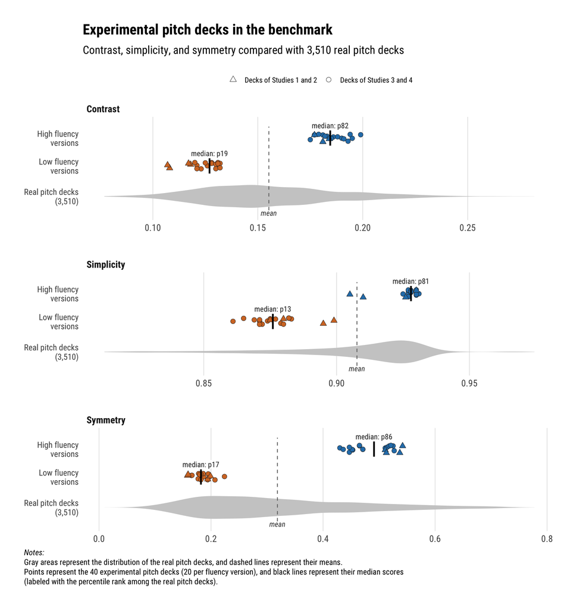

Figure B1: Contrast, simplicity, and symmetry scores of the 40 experimental pitch decks compared with 3,510 real pitch decks

```r
# aesthetics
#
# colors of high and low fluency: the main blue and a burnt orange as its
# complementary color
bm_col_high <- blue_main
bm_col_low <- "#D4772C"

# data prep
#
# long format of the real pitch decks
bm_bench_long <- bm_bench |>
  tidyr::pivot_longer(c(contrast, simplicity, symmetry), names_to = "measure", values_to = "score")
bm_bench_long$measure <- factor(bm_bench_long$measure, levels = c("contrast", "simplicity", "symmetry"),
                                labels = c("Contrast", "Simplicity", "Symmetry"))
# mean of the real pitch decks
bm_bench_long |> group_by(measure) |> summarize(score = mean(score)) -> bm_bench_mean
# experimental pitch decks (rows: 1 = real decks, 2 = low fluency, 3 = high fluency)
bm_decks_fig <- bm_decks_long
bm_decks_fig$measure <- factor(bm_decks_fig$measure, levels = c("contrast", "simplicity", "symmetry"),
                               labels = c("Contrast", "Simplicity", "Symmetry"))
bm_decks_fig$row <- ifelse(bm_decks_fig$fluency == "HF", 3.3, 2.2)
bm_decks_fig$level <- factor(bm_decks_fig$fluency, levels = c("HF", "LF"), labels = c("High", "Low"))
bm_decks_fig$set <- factor(bm_decks_fig$set, levels = c("Studies 1 and 2", "Studies 3 and 4"),
                           labels = c("Decks of Studies 1 and 2", "Decks of Studies 3 and 4"))
# median score and percentile rank per measure and fluency version
bm_decks_fig |> group_by(measure, row) |>
  summarize(score = median(score), pr = median(pr), .groups = "drop") -> bm_decks_medians

# plot
ggplot() +
  geom_violin(data = bm_bench_long, aes(x = score, y = 1), fill = "gray80", color = NA,
              orientation = "y", width = .9) +
  geom_segment(data = bm_bench_mean, aes(x = score, xend = score, y = .45, yend = 3.75),
               color = "gray45", linetype = "dashed", linewidth = .5) +
  geom_text(data = bm_bench_mean, aes(x = score, y = .35, label = "mean"), size = 3.3,
            color = "gray25", fontface = "italic", family = "Roboto Condensed") +
  geom_point(data = bm_decks_fig, aes(x = score, y = row, fill = level, shape = set), size = 2.6,
             color = "gray15", stroke = .3, position = position_jitter(width = 0, height = .15, seed = 42)) +
  geom_segment(data = bm_decks_medians, aes(x = score, xend = score, y = row - .3, yend = row + .3),
               color = "black", linewidth = 1) +
  geom_label(data = bm_decks_medians, aes(x = score, y = row + .5, label = paste0("median: p", sprintf('%.0f', pr))),
             size = 3.3, family = "Roboto Condensed", color = "gray15", fill = "white", linewidth = 0,
             label.padding = unit(.1, "lines")) +
  facet_wrap(vars(measure), ncol = 1, scales = "free_x") +
  scale_y_continuous(breaks = c(1, 2.2, 3.3), labels = c("Real pitch decks\n(3,510)", "Low fluency\nversions",
                                                         "High fluency\nversions"),
                     limits = c(.25, 3.95)) +
  scale_fill_manual(values = c("High" = bm_col_high, "Low" = bm_col_low), guide = "none") +
  scale_shape_manual(values = c(24, 21), name = NULL) +
  hrbrthemes::theme_ipsum_rc() +
  theme(panel.grid.major.y = element_blank(),
        panel.grid.minor = element_blank(),
        strip.text = element_text(size = 12, face = "bold", hjust = 0),
        axis.text.y = element_text(size = 10.5),
        legend.position = "top",
        plot.title = element_markdown(size = 18, family = "Roboto Condensed", face = "plain"),
        plot.subtitle = element_text(size = 14, family = "Roboto Condensed"),
        plot.caption.position = "plot",
        plot.caption = element_markdown(hjust = 0, lineheight = 1.2, family = "Roboto Condensed", size = 10, margin = margin(t = 7, r = 0, b = 0, l = 0))) +
  labs(x = NULL, y = NULL,
       title = "<b>Experimental pitch decks in the benchmark</b>",
       subtitle = "Contrast, simplicity, and symmetry compared with 3,510 real pitch decks",
       caption = paste0("<i>Notes:</i><br>", "Gray areas represent the distribution of the real pitch decks, and dashed lines represent their means.<br>",
                        "Points represent the 40 experimental pitch decks (20 per fluency version), and black lines represent their median scores<br>",
                        "(labeled with the percentile rank among the real pitch decks)."))
```

## 4.2 Text-based substantive-quality measurement

We assessed the substantive evidence in the same 3,510 real decks separately from their visual design. The pipeline, which ran within the firm’s environment, rendered the slides as images, extracted their text with GLM-OCR, and replaced company names, founder names, and locations with placeholders (spaCy). Two open-weight models from different developers, Qwen 3.5 and Mistral 3 Large, then rated the anonymized text on 1–7 scales whose anchors described the evidence associated with low, intermediate, and high ratings: organizational capital (documented intellectual property and certifications), human capital, commercialization opportunity, organizational legitimacy, and a separate overall quality item. Each model rated each dimension of each deck with three meaning-preserving versions of the prompt, which results in 105,300 ratings (3,510 decks × 5 dimensions × 3 prompt versions × 2 models). Of these responses, 526 (0.5%) did not contain a rating (“I cannot determine”) and were replaced by the median of the available ratings of the same model, dimension, and prompt version. For each model and dimension, each prompt version was standardized across the decks, and the mean of the three standardized ratings was rescaled with the mean and the population standard deviation of all ratings of the model and dimension, bounded to the range from 1 to 7, and rounded to two decimals. The dimension score is the mean of the two model-level scores (rounded to two decimals), and the text-based quality score is the mean of the four standardized dimension scores (i.e., without overall quality). Correspondingly, the image-based fluency score is the mean of the standardized contrast, simplicity, and symmetry scores. Table B1 reports the scoring consistency for every dimension, including overall quality: the agreement across the three prompt versions (ICC(2,1), separately for each model), the agreement between the two models (quadratic-weighted Cohen’s κ of their rounded model-level scores), and the prompt sensitivity (the percentage of decks for which the three ratings of at least one model differ by two or more points).

*Results.* Agreement across the prompt versions ranged from .876 to .902, and agreement between the models from .844 to .924. The ratings of at least one model differed by two or more points across the prompt versions for 24.1% of the decks for organizational capital, 18.4% for human capital, 25.5% for commercialization opportunity, 13.0% for organizational legitimacy, and 15.1% for overall quality. Thus, the ratings were generally consistent, while some assessments, in particular of organizational capital and commercialization opportunity, remained sensitive to the wording of the prompt.

```r
data.frame(Dimension = c("Organizational capital", "Human capital", "Commercialization opportunity",
                         "Organizational legitimacy", "Overall quality"),
           icc_qwen = bm_r(bm_icc_qwen), icc_mistral = bm_r(bm_icc_mistral), kappa = bm_r(bm_kappa),
           flip = paste0(sprintf('%.1f', bm_flip), "%")) |>
  kbl(col.names = c("Dimension", "Qwen 3.5", "Mistral 3 Large", "Between models", "Prompt sensitivity"),
      caption = "Table B1: Scoring consistency and prompt sensitivity", align = "lcccc", escape = FALSE) |>
  kable_styling() |>
  add_header_above(c(" " = 1, "ICC(2,1) across prompts" = 2, "Weighted κ" = 1, " " = 1)) |>
  column_spec(1:5, extra_css = "white-space: nowrap;", include_thead = TRUE)
```

Table B1: Scoring consistency and prompt sensitivity

| Dimension | ICC(2,1) across prompts Qwen 3.5 | ICC(2,1) across prompts Mistral 3 Large | Weighted κ Between models | Prompt sensitivity |
| --- | --- | --- | --- | --- |
| Organizational capital | .899 | .902 | .924 | 24.1% |
| Human capital | .886 | .881 | .924 | 18.4% |
| Commercialization opportunity | .876 | .876 | .914 | 25.5% |
| Organizational legitimacy | .902 | .899 | .884 | 13.0% |
| Overall quality | .894 | .900 | .844 | 15.1% |

*Notes:* Agreement across prompt versions is the ICC(2,1) of the three ratings per deck (two-way random effects, absolute agreement), separately for each model. Agreement between the models is the quadratic-weighted Cohen’s κ of the two rounded model-level scores. Prompt sensitivity is the percentage of decks for which the three ratings of at least one model differ by two or more points. All values are based on the 3,510 real pitch decks.

## 4.3 Relationship between visual fluency and substantive evidence

We correlated the image-based fluency score with the text-based quality score and each of the three visual features with each of the four dimension scores (Pearson correlations). Top-quality decks are the 878 decks in the highest quartile of the text-based quality score. Figure B2 relates the two scores (left panel) and shows the distribution of all top-quality decks across the deciles of the fluency score (right panel, the bars add up to 100%). Table B2 reports, for each quartile of the fluency score, the mean text-based quality score (standardized across all decks) and the number and share of top-quality decks among the decks of the quartile.

*Results.* The image-based fluency score was weakly positively correlated with the text-based quality score (*r* = .153, 95% CI [.121, .186], *p* < .001), which corresponds to 2.4% shared variance. Correlations between the individual visual features and the four quality dimensions ranged from .041 to .095. Among the decks in the lowest fluency quartile, 178 of 878 (20.3%) were top-quality decks. The corresponding share in the highest fluency quartile was 289 of 878 (32.9%). Viewed from the other direction, 41.8% of the top-quality decks had fluency scores below the median of all decks (Figure B2, right panel). Thus, highly rated substantive evidence frequently appeared in less fluent decks, while the two scores remained positively associated.

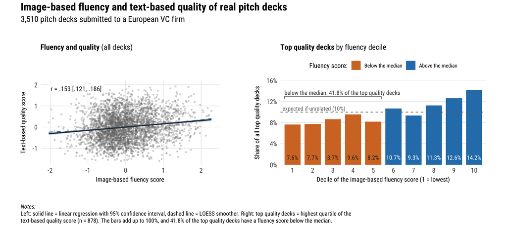

Figure B2: Image-based fluency and text-based quality of 3,510 real pitch decks

```r
# data prep
#
# share of all top quality decks per fluency decile (in %)
bm_d |> filter(quality_top) |> count(fluency_decile) |>
  mutate(share = n / sum(n) * 100,
         below_median = factor(fluency_decile <= 5, levels = c(TRUE, FALSE),
                               labels = c("Below the median", "Above the median"))) -> bm_deciles
# correlation (for the label)
bm_r_label <- paste0("r = ", weights::rd(cor(bm_d$fluency_score, bm_d$quality_score), 3), " [",
                     weights::rd(cor.test(bm_d$fluency_score, bm_d$quality_score)$conf.int[1], 3), ", ",
                     weights::rd(cor.test(bm_d$fluency_score, bm_d$quality_score)$conf.int[2], 3), "]")

# figure: scatter plot
bm_ortho_1 <- ggplot(bm_d, aes(x = fluency_score, y = quality_score)) +
  geom_point(size = .9, alpha = .25, color = "gray45") +
  geom_smooth(method = "loess", formula = y ~ x, se = FALSE, color = blue_main, linewidth = .8, linetype = "dashed") +
  geom_smooth(method = "lm", formula = y ~ x, se = TRUE, color = blue_dark, fill = blue_light, linewidth = 1) +
  annotate("label", x = min(bm_d$fluency_score), y = max(bm_d$quality_score), label = bm_r_label, hjust = 0, vjust = 1,
           size = 4, color = "gray15", fill = "white", linewidth = 0, family = "Roboto Condensed") +
  hrbrthemes::theme_ipsum_rc() +
  theme(panel.grid.minor = element_blank(),
        plot.title = element_markdown(size = 13, family = "Roboto Condensed", face = "plain", hjust = 0),
        axis.title.y = element_text(size = 11, hjust = .5, margin = margin(t = 0, r = 10, b = 0, l = 0)),
        axis.title.x = element_text(size = 11, hjust = .5, margin = margin(t = 5, r = 0, b = 0, l = 0))) +
  labs(x = "Image-based fluency score", y = "Text-based quality score",
       title = "<b>Fluency and quality</b> (all decks)")

# figure: top quality decks per fluency decile
bm_ortho_2 <- ggplot(bm_deciles, aes(x = factor(fluency_decile), y = share, fill = below_median)) +
  geom_col(width = .8) +
  geom_hline(yintercept = 10, linetype = "dashed", color = "gray45", linewidth = .5) +
  # shares as labels inside the bars
  geom_text(aes(y = 1, label = sprintf("%.1f%%", share), color = below_median), vjust = 0, size = 3.6,
            family = "Roboto Condensed") +
  annotate("text", x = .5, y = 10.3, label = "expected if unrelated (10%)", hjust = 0, vjust = 0, size = 3.5,
           color = "gray45", family = "Roboto Condensed") +
  # bracket over the deciles below the median
  annotate("segment", x = .6, xend = 5.4, y = 13, yend = 13, color = "gray45", linewidth = .5) +
  annotate("segment", x = c(.6, 5.4), xend = c(.6, 5.4), y = 13, yend = 12.5, color = "gray45", linewidth = .5) +
  annotate("text", x = .6, y = 13.3, label = paste0("below the median: ", sprintf('%.1f', sum(bm_deciles$share[bm_deciles$fluency_decile <= 5])),
                                                   "% of the top quality decks"),
           hjust = 0, vjust = 0, size = 3.6, color = "gray25", family = "Roboto Condensed") +
  scale_fill_manual(values = c("Below the median" = bm_col_low, "Above the median" = bm_col_high), name = "Fluency score:") +
  scale_color_manual(values = c("Below the median" = "gray15", "Above the median" = "white"), guide = "none") +
  scale_y_continuous(labels = scales::label_percent(scale = 1), limits = c(0, 16), expand = expansion(mult = c(0, 0))) +
  hrbrthemes::theme_ipsum_rc() +
  theme(panel.grid.major.x = element_blank(),
        panel.grid.minor = element_blank(),
        legend.position = "top",
        plot.title = element_markdown(size = 13, family = "Roboto Condensed", face = "plain", hjust = 0),
        axis.title.y = element_text(size = 11, hjust = .5, margin = margin(t = 0, r = 10, b = 0, l = 0)),
        axis.title.x = element_text(size = 11, hjust = .5, margin = margin(t = 5, r = 0, b = 0, l = 0))) +
  labs(x = "Decile of the image-based fluency score (1 = lowest)", y = "Share of all top quality decks",
       title = "<b>Top quality decks</b> by fluency decile")

# final (combined) figure
bm_ortho_1 + bm_ortho_2 + plot_layout(widths = c(1, 1.15)) +
  plot_annotation(
    title = "<b>Image-based fluency and text-based quality of real pitch decks</b>",
    subtitle = "3,510 pitch decks submitted to a European VC firm",
    caption = paste0("<i>Notes:</i><br>", "Left: solid line = linear regression with 95% confidence interval, dashed line = LOESS smoother. ",
                     "Right: top quality decks = highest quartile of the<br>text-based quality score (n = ", sum(bm_d$quality_top),
                     "). The bars add up to 100%, and ", sprintf('%.1f', mean(bm_d$fluency_below_median[bm_d$quality_top]) * 100),
                     "% of the top quality decks have a fluency score below the median."),
    theme = theme(
      plot.title = element_markdown(size = 18, family = "Roboto Condensed", face = "plain"),
      plot.subtitle = element_text(size = 14, family = "Roboto Condensed"),
      plot.caption.position = "plot", plot.caption = element_markdown(hjust = 0, lineheight = 1.2, family = "Roboto Condensed", size = 10, margin = margin(t = 7, r = 0, b = 0, l = 0)))
  )
```

```r
bm_quartiles |>
  mutate(quartile = c("1 (lowest fluency)", "2", "3", "4 (highest fluency)"),
         N = scales::comma(N), mean_quality = sprintf('%.3f', mean_quality), share = sprintf('%.1f', share)) |>
  select(quartile, N, mean_quality, top, share) |>
  kbl(col.names = c("Fluency-score quartile", "N", "Mean quality score", "n", "%"),
      caption = "Table B2: Substantive quality by fluency-score quartile", align = "lcccc", escape = FALSE) |>
  kable_styling() |>
  add_header_above(c(" " = 3, "Top-quality decks" = 2)) |>
  column_spec(1:5, extra_css = "white-space: nowrap;", include_thead = TRUE)
```

Table B2: Substantive quality by fluency-score quartile

| Fluency-score quartile | N | Mean quality score | Top-quality decks n | Top-quality decks % |
| --- | --- | --- | --- | --- |
| 1 (lowest fluency) | 878 | -0.160 | 178 | 20.3 |
| 2 | 877 | -0.078 | 189 | 21.6 |
| 3 | 877 | 0.008 | 222 | 25.3 |
| 4 (highest fluency) | 878 | 0.230 | 289 | 32.9 |

*Notes:* Quartile 1 has the lowest image-based fluency scores. Mean quality scores are text-based quality scores standardized across all 3,510 decks. Top-quality decks are the decks in the highest quartile of the text-based quality score, and the percentages use the decks of each fluency quartile as the denominator.

## 4.4 Founder characteristics

We related the fluency score to the rated human-capital evidence (Pearson correlation) and regressed it on four characteristics that the VC firm recorded, in a linear regression (OLS): whether a founder had previously exited a venture (prior exit), serial-founder status, the prior funding raised (log-transformed, i.e., log(1 + x)), and the number of slides of the deck (Table B3).

*Results.* The correlation of the fluency score with the rated human-capital evidence was small (*r* = .116, 95% CI [.083, .149]). The four characteristics explained 2.3% of the variation in the fluency score after adjustment for the number of predictors (adjusted *R*<sup>2</sup>). Serial-founder status was positively associated with the score (*b* = 0.188, *p* < .001), whereas a prior exit was negatively associated with it (*b* = -0.421, *p* < .001). Neither the prior funding nor the number of slides had a significant conditional association (*p* = .471 and *p* = .626).

```r
data.frame(Predictor = c("Founder prior exit", "Serial founder", "Prior funding raised (log)", "Number of slides"),
           b = bm_f3(bm_founders_coef[-1, "Estimate"]), SE = bm_f3(bm_founders_coef[-1, "Std. Error"]),
           CI = bm_ci3(bm_founders_ci[-1, 1], bm_founders_ci[-1, 2]), p = p_tbl(bm_founders_coef[-1, "Pr(>|t|)"])) |>
  kbl(col.names = c("Predictor", "b", "SE", "95% CI", "p"), row.names = FALSE,
      caption = "Table B3: Founder characteristics and visual fluency", align = "lcccc", escape = FALSE) |>
  kable_styling() |>
  column_spec(c(1, 4), extra_css = "white-space: nowrap;", include_thead = TRUE)
```

Table B3: Founder characteristics and visual fluency

| Predictor | b | SE | 95% CI | p |
| --- | --- | --- | --- | --- |
| Founder prior exit | -0.421 | 0.048 | [-0.515, -0.328] | < .001 |
| Serial founder | 0.188 | 0.029 | [0.131, 0.246] | < .001 |
| Prior funding raised (log) | 0.001 | 0.002 | [-0.003, 0.006] | .471 |
| Number of slides | -0.001 | 0.002 | [-0.005, 0.003] | .626 |

*Notes:* Linear regression of the image-based fluency score (*N* = 3,510, adjusted *R*<sup>2</sup> = .023). Prior funding raised is log-transformed, log(1 + x).

## 4.5 Venture outcomes

The VC firm also recorded whether a startup received follow-on funding, whether it survived, and whether it had an exit through an IPO or an acquisition, together with whether the partner firm had funded the startup. Follow-on funding is a separate outcome from funding by the partner firm. We correlated both scores with each outcome (Table B4, Panel A) and estimated one joint logistic regression per outcome with both scores and funding by the partner firm as predictors (Panel B), with 95% profile-likelihood confidence intervals.

*Results.* Of the 3,510 decks, 599 were associated with funding by the partner firm and 2,911 were not. Both scores were positively associated with all three outcomes. The correlations with follow-on funding, survival, and exit were .235, .190, and .128 for the image-based fluency score and .104, .073, and .076 for the text-based quality score (all *p* < .001). In the joint models, the fluency score remained positively associated with follow-on funding (*b* = 0.747), survival (*b* = 0.629), and exit (*b* = 0.430, all *p* < .001). The quality score retained a positive association with follow-on funding (*b* = 0.130, *p* = .029), whereas its conditional associations with survival (*b* = 0.091, *p* = .117) and exit (*b* = 0.115, *p* = .109) were not significant.

```r
data.frame(Outcome = c("Follow-on funding", "Survival", "Exit via IPO or acquisition"),
           r_fluency = bm_r(bm_r_outcomes$r[1:3]), ci_fluency = bm_ci_r(bm_r_outcomes$lower[1:3], bm_r_outcomes$upper[1:3]),
           p_fluency = p_tbl(bm_r_outcomes$p[1:3]),
           r_quality = bm_r(bm_r_outcomes$r[4:6]), ci_quality = bm_ci_r(bm_r_outcomes$lower[4:6], bm_r_outcomes$upper[4:6]),
           p_quality = p_tbl(bm_r_outcomes$p[4:6])) |>
  kbl(col.names = c("Outcome", "r", "95% CI", "p", "r", "95% CI", "p"),
      caption = "Table B4, Panel A: Correlations of visual fluency and substantive quality with venture outcomes",
      align = "lcccccc", escape = FALSE) |>
  kable_styling() |>
  add_header_above(c(" " = 1, "Image-based fluency score" = 3, "Text-based quality score" = 3)) |>
  column_spec(c(1, 3, 6), extra_css = "white-space: nowrap;", include_thead = TRUE)
```

Table B4, Panel A: Correlations of visual fluency and substantive quality with venture outcomes

| Outcome | Image-based fluency score r | Image-based fluency score 95% CI | Image-based fluency score p | Text-based quality score r | Text-based quality score 95% CI | Text-based quality score p |
| --- | --- | --- | --- | --- | --- | --- |
| Follow-on funding | .235 | [.203, .266] | < .001 | .104 | [.071, .137] | < .001 |
| Survival | .190 | [.157, .221] | < .001 | .073 | [.040, .106] | < .001 |
| Exit via IPO or acquisition | .128 | [.096, .161] | < .001 | .076 | [.043, .109] | < .001 |

```r
data.frame(Predictor = rep(c("Intercept", "Image-based fluency score", "Text-based quality score",
                             "Funding by the partner firm"), 3),
           b = bm_f3(bm_glm_coef[, "Estimate"]), SE = bm_f3(bm_glm_coef[, "Std. Error"]),
           CI = bm_ci3(bm_glm_ci[, 1], bm_glm_ci[, 2]), p = p_tbl(bm_glm_coef[, "Pr(>|z|)"])) |>
  kbl(col.names = c("Predictor", "b", "SE", "95% CI", "p"), row.names = FALSE,
      caption = "Table B4, Panel B: Joint logistic regressions of venture outcomes", align = "lcccc", escape = FALSE) |>
  kable_styling() |>
  column_spec(c(1, 4), extra_css = "white-space: nowrap;", include_thead = TRUE) |>
  pack_rows(index = c("Follow-on funding" = 4, "Survival" = 4, "Exit via IPO or acquisition" = 4),
            label_row_css = "text-align: center;") |>
  repeat_header()
```

Table B4, Panel B: Joint logistic regressions of venture outcomes

| Predictor | b | SE | 95% CI | p |
| --- | --- | --- | --- | --- |
| **Follow-on funding** |  |  |  |  |
| Intercept | -0.959 | 0.043 | [-1.043, -0.876] | < .001 |
| Image-based fluency score | 0.747 | 0.061 | [0.629, 0.867] | < .001 |
| Text-based quality score | 0.130 | 0.059 | [0.014, 0.246] | .029 |
| Funding by the partner firm | 1.636 | 0.100 | [1.442, 1.833] | < .001 |
| Predictor | b | SE | 95% CI | p |
| **Survival** |  |  |  |  |
| Intercept | 0.623 | 0.040 | [0.545, 0.702] | < .001 |
| Image-based fluency score | 0.629 | 0.063 | [0.508, 0.753] | < .001 |
| Text-based quality score | 0.091 | 0.058 | [-0.023, 0.206] | .117 |
| Funding by the partner firm | 1.247 | 0.129 | [0.999, 1.506] | < .001 |
| Predictor | b | SE | 95% CI | p |
| **Exit via IPO or acquisition** |  |  |  |  |
| Intercept | -1.914 | 0.056 | [-2.025, -1.806] | < .001 |
| Image-based fluency score | 0.430 | 0.070 | [0.293, 0.567] | < .001 |
| Text-based quality score | 0.115 | 0.072 | [-0.026, 0.255] | .109 |
| Funding by the partner firm | 1.444 | 0.102 | [1.245, 1.643] | < .001 |

*Notes:* *N* = 3,510 decks in each analysis. Panel A reports Pearson correlations with two-sided tests. Panel B reports the log-odds coefficients of one logistic regression per outcome, with profile-likelihood 95% confidence intervals and two-sided Wald tests. Funding by the partner firm is coded 1 if the partner firm funded the startup and 0 otherwise. These observational associations do not establish causality.

# 5 Study 1: Investor Engagement in the Field

This section reproduces the results of Study 1 and Appendix C. The data processing, exclusions, and further analyses are documented in the Study 1: Investor Engagement in the Field Reproducibility Report. The analyses use three outcomes. Opening duration is the cumulative time (in seconds) that an investor kept the deck open, summed across the investor’s viewing sessions in the observation window. Slide coverage is the proportion of pitch deck slides viewed (0–1), the highest value recorded across these sessions. Positive reaction indicates whether the investor scheduled a meeting through the link in the deck or sent an email reply that clearly demonstrated investor interest (1 = yes, 0 = no).

```r
# Study 1: Investor Engagement in the Field
# AsPredicted Preregistration #118675
#
# processed data (one row per retained deck viewer, and one row per contacted
# investor for the Sankey diagrams)
s1_sw <- readr::read_csv(here(processed_dir, 'Study_1_Software.csv'))
s1_hc <- readr::read_csv(here(processed_dir, 'Study_1_Healthcare.csv'))
s1_sankey_sw <- readr::read_csv(here(processed_dir, 'Study_1_Software_Sankey.csv'))
s1_sankey_hc <- readr::read_csv(here(processed_dir, 'Study_1_Healthcare_Sankey.csv'))
# email exports: sent emails, hard bounces, and delivered emails
s1_emails_sw <- readr::read_csv(here(raw_dir, 'Study_1-1_Software_Emails.csv'))
s1_emails_hc <- readr::read_csv(here(raw_dir, 'Study_1-2_Healthcare_Emails.csv'))
s1_n_sw <- c(sent = nrow(s1_emails_sw), bounced = sum(s1_emails_sw$hard_bounce == 1),
             delivered = sum(s1_emails_sw$hard_bounce == 0))
s1_n_hc <- c(sent = nrow(s1_emails_hc), bounced = sum(s1_emails_hc$hard_bounce == 1),
             delivered = sum(s1_emails_hc$hard_bounce == 0))
# investors with an eligible first click: first click on a session not flagged as
# atypical, with an identifier in the outreach sample, within 21 days of receiving the email
s1_visits_sw <- readr::read_csv(here(raw_dir, 'Study_1-1_Software_Visits.csv'))
s1_visits_sw$date_visit <- lubridate::as_date(s1_visits_sw$date_visit, format = "%d%b%Y")
s1_first_sw <- s1_visits_sw |>
  filter(atypical != 1, uuid %in% s1_emails_sw$uuid) |>
  group_by(uuid) |>
  summarize(date_first_click = min(date_visit)) |>
  left_join(s1_emails_sw |> select(uuid, date_sent), by = "uuid")
s1_eligible_sw <- sum(s1_first_sw$date_first_click < lubridate::as_date(s1_first_sw$date_sent, format = "%d%b%Y") + 21)
s1_visits_hc <- readr::read_csv(here(raw_dir, 'Study_1-2_Healthcare_Visits.csv'))
s1_visits_hc$date_visit <- lubridate::as_date(s1_visits_hc$date_visit, format = "%d%b%Y")
s1_first_hc <- s1_visits_hc |>
  filter(atypical != 1, uuid %in% s1_emails_hc$uuid) |>
  group_by(uuid) |>
  summarize(date_first_click = min(date_visit)) |>
  left_join(s1_emails_hc |> select(uuid, date_sent), by = "uuid")
s1_eligible_hc <- sum(s1_first_hc$date_first_click < lubridate::as_date(s1_first_hc$date_sent, format = "%d%b%Y") + 21)
# coded email replies: agreement between the two independent raters
s1_coded_sw <- readr::read_csv(here(raw_dir, 'Study_1-1_Software_Replies_coded.csv'))
s1_coded_hc <- readr::read_csv(here(raw_dir, 'Study_1-2_Healthcare_Replies_coded.csv'))
s1_agree_sw <- irr::agree(cbind(s1_coded_sw$positive_RA1, s1_coded_sw$positive_RA2))$value
s1_kappa_sw <- irr::kappa2(cbind(s1_coded_sw$positive_RA1, s1_coded_sw$positive_RA2))$value
s1_agree_hc <- irr::agree(cbind(s1_coded_hc$positive_RA1, s1_coded_hc$positive_RA2))$value
s1_kappa_hc <- irr::kappa2(cbind(s1_coded_hc$positive_RA1, s1_coded_hc$positive_RA2))$value

# convert conditions into factors with effect coding (high = 1, low = -1) and
# set the reference levels of the covariates
s1_sw$fluency <- as.factor(s1_sw$fluency)
s1_sw$quality <- as.factor(s1_sw$quality)
contrasts(s1_sw$fluency) <- contr.sum
contrasts(s1_sw$quality) <- contr.sum
s1_sw$type <- relevel(as.factor(s1_sw$type), "Angel")
s1_sw$gender <- relevel(as.factor(s1_sw$gender), "female")
s1_sw$location <- relevel(as.factor(s1_sw$location), "United States")
s1_hc$fluency <- as.factor(s1_hc$fluency)
s1_hc$quality <- as.factor(s1_hc$quality)
contrasts(s1_hc$fluency) <- contr.sum
contrasts(s1_hc$quality) <- contr.sum
s1_hc$type <- relevel(as.factor(s1_hc$type), "Angel")
s1_hc$gender <- relevel(as.factor(s1_hc$gender), "female")
s1_hc$location <- relevel(as.factor(s1_hc$location), "United States")

# preregistered models: two-factor ANOVAs (Type III) for opening duration and
# slide coverage, logistic regression for positive reactions
s1_m_dur_sw <- lm(duration ~ fluency * quality, s1_sw)
s1_m_cov_sw <- lm(completion ~ fluency * quality, s1_sw)
s1_m_pos_sw <- glm(positive ~ fluency * quality, family = binomial(link = "logit"), s1_sw)
s1_m_dur_hc <- lm(duration ~ fluency * quality, s1_hc)
s1_m_cov_hc <- lm(completion ~ fluency * quality, s1_hc)
s1_m_pos_hc <- glm(positive ~ fluency * quality, family = binomial(link = "logit"), s1_hc)
s1_aov_dur_sw <- supernova::supernova(s1_m_dur_sw, type = 3)$tbl
s1_aov_cov_sw <- supernova::supernova(s1_m_cov_sw, type = 3)$tbl
s1_aov_dur_hc <- supernova::supernova(s1_m_dur_hc, type = 3)$tbl
s1_aov_cov_hc <- supernova::supernova(s1_m_cov_hc, type = 3)$tbl

# high-minus-low contrasts (two times the coefficient) and interaction
# contrasts (four times the coefficient) in seconds and percentage points; for
# positive reactions, differences of the model-based probabilities in
# percentage points (interaction: fluency difference under high minus under
# low quality, the order of the `by` groups)
s1_effects <- bind_rows(
  coef_contrast(s1_m_dur_sw, "fluency1", 2), coef_contrast(s1_m_dur_sw, "quality1", 2),
  coef_contrast(s1_m_dur_sw, "fluency1:quality1", 4),
  coef_contrast(s1_m_cov_sw, "fluency1", 2 * 100), coef_contrast(s1_m_cov_sw, "quality1", 2 * 100),
  coef_contrast(s1_m_cov_sw, "fluency1:quality1", 4 * 100),
  pp_contrast(s1_m_pos_sw, "fluency"), pp_contrast(s1_m_pos_sw, "quality"),
  pp_contrast(s1_m_pos_sw, "fluency", by = "quality", hypothesis = "b1 - b2 = 0"),
  coef_contrast(s1_m_dur_hc, "fluency1", 2), coef_contrast(s1_m_dur_hc, "quality1", 2),
  coef_contrast(s1_m_dur_hc, "fluency1:quality1", 4),
  coef_contrast(s1_m_cov_hc, "fluency1", 2 * 100), coef_contrast(s1_m_cov_hc, "quality1", 2 * 100),
  coef_contrast(s1_m_cov_hc, "fluency1:quality1", 4 * 100),
  pp_contrast(s1_m_pos_hc, "fluency"), pp_contrast(s1_m_pos_hc, "quality"),
  pp_contrast(s1_m_pos_hc, "fluency", by = "quality", hypothesis = "b1 - b2 = 0")
) |>
  mutate(startup = rep(c("Software", "Healthcare"), each = 9),
         outcome = rep(rep(c("duration", "coverage", "positive"), each = 3), 2),
         effect = rep(c("fluency", "quality", "interaction"), 6),
         # F tests of the preregistered ANOVAs and delta-method z tests
         test = c(paste0("<i>F</i>(1, ", s1_aov_dur_sw$df[s1_aov_dur_sw$term == "Error"], ") = ", f2(s1_aov_dur_sw$F[2:4])),
                  paste0("<i>F</i>(1, ", s1_aov_cov_sw$df[s1_aov_cov_sw$term == "Error"], ") = ", f2(s1_aov_cov_sw$F[2:4])),
                  paste0("<i>z</i> = ", f2(statistic[7:9])),
                  paste0("<i>F</i>(1, ", s1_aov_dur_hc$df[s1_aov_dur_hc$term == "Error"], ") = ", f2(s1_aov_dur_hc$F[2:4])),
                  paste0("<i>F</i>(1, ", s1_aov_cov_hc$df[s1_aov_cov_hc$term == "Error"], ") = ", f2(s1_aov_cov_hc$F[2:4])),
                  paste0("<i>z</i> = ", f2(statistic[16:18]))),
         p = c(s1_aov_dur_sw$p[2:4], s1_aov_cov_sw$p[2:4], p[7:9],
               s1_aov_dur_hc$p[2:4], s1_aov_cov_hc$p[2:4], p[16:18]))
```

```r
# preregistered Wald tests of the logistic regressions (log-odds scale)
s1_logit <- bind_rows(
  coef_contrast(s1_m_pos_sw, "fluency1", 2), coef_contrast(s1_m_pos_sw, "quality1", 2),
  coef_contrast(s1_m_pos_sw, "fluency1:quality1", 4),
  coef_contrast(s1_m_pos_hc, "fluency1", 2), coef_contrast(s1_m_pos_hc, "quality1", 2),
  coef_contrast(s1_m_pos_hc, "fluency1:quality1", 4)
)

# model-based means at the two levels of each factor (equal weights over the
# levels of the other factor, averaged on the response scale) and percentage
# increases from the low to the high level
s1_mm_dur_flu_sw <- marginaleffects::predictions(s1_m_dur_sw, by = "fluency", type = "response",
                      newdata = marginaleffects::datagrid(grid_type = "balanced"))
s1_mm_dur_flu_hc <- marginaleffects::predictions(s1_m_dur_hc, by = "fluency", type = "response",
                      newdata = marginaleffects::datagrid(grid_type = "balanced"))
s1_mm_pos_flu_sw <- marginaleffects::predictions(s1_m_pos_sw, by = "fluency", type = "response",
                      newdata = marginaleffects::datagrid(grid_type = "balanced"))
s1_mm_pos_qual_sw <- marginaleffects::predictions(s1_m_pos_sw, by = "quality", type = "response",
                       newdata = marginaleffects::datagrid(grid_type = "balanced"))
s1_mm_pos_flu_hc <- marginaleffects::predictions(s1_m_pos_hc, by = "fluency", type = "response",
                      newdata = marginaleffects::datagrid(grid_type = "balanced"))
s1_mm_pos_qual_hc <- marginaleffects::predictions(s1_m_pos_hc, by = "quality", type = "response",
                       newdata = marginaleffects::datagrid(grid_type = "balanced"))
s1_incr_dur_flu_sw <- 100 * (s1_mm_dur_flu_sw$estimate[s1_mm_dur_flu_sw$fluency == "high"] /
                               s1_mm_dur_flu_sw$estimate[s1_mm_dur_flu_sw$fluency == "low"] - 1)
s1_incr_dur_flu_hc <- 100 * (s1_mm_dur_flu_hc$estimate[s1_mm_dur_flu_hc$fluency == "high"] /
                               s1_mm_dur_flu_hc$estimate[s1_mm_dur_flu_hc$fluency == "low"] - 1)
s1_incr_pos_flu_sw <- 100 * (s1_mm_pos_flu_sw$estimate[s1_mm_pos_flu_sw$fluency == "high"] /
                               s1_mm_pos_flu_sw$estimate[s1_mm_pos_flu_sw$fluency == "low"] - 1)
s1_incr_pos_qual_sw <- 100 * (s1_mm_pos_qual_sw$estimate[s1_mm_pos_qual_sw$quality == "high"] /
                                s1_mm_pos_qual_sw$estimate[s1_mm_pos_qual_sw$quality == "low"] - 1)
s1_incr_pos_flu_hc <- 100 * (s1_mm_pos_flu_hc$estimate[s1_mm_pos_flu_hc$fluency == "high"] /
                               s1_mm_pos_flu_hc$estimate[s1_mm_pos_flu_hc$fluency == "low"] - 1)
s1_incr_pos_qual_hc <- 100 * (s1_mm_pos_qual_hc$estimate[s1_mm_pos_qual_hc$quality == "high"] /
                                s1_mm_pos_qual_hc$estimate[s1_mm_pos_qual_hc$quality == "low"] - 1)

# preregistered covariate models: investment experience, investor type,
# gender, and country added (linear, logit, and Tobit models)
s1_mc_dur_sw <- lm(duration ~ fluency * quality + investments + type + gender + location, s1_sw)
s1_mc_cov_sw <- lm(completion ~ fluency * quality + investments + type + gender + location, s1_sw)
s1_mc_pos_sw <- glm(positive ~ fluency * quality + investments + type + gender + location,
                    family = binomial(link = "logit"), s1_sw)
s1_mc_tob_sw <- AER::tobit(positive ~ fluency * quality + investments + type + gender + location, data = s1_sw)
s1_mc_dur_hc <- lm(duration ~ fluency * quality + investments + type + gender + location, s1_hc)
s1_mc_cov_hc <- lm(completion ~ fluency * quality + investments + type + gender + location, s1_hc)
s1_mc_pos_hc <- glm(positive ~ fluency * quality + investments + type + gender + location,
                    family = binomial(link = "logit"), s1_hc)
s1_mc_tob_hc <- AER::tobit(positive ~ fluency * quality + investments + type + gender + location, data = s1_hc)
# p-values of the fluency, quality, and interaction terms (linear and logit models)
s1_mc_p <- bind_rows(reg_coefs(s1_mc_dur_sw)[2:3, ], reg_coefs(s1_mc_cov_sw)[2:3, ], reg_coefs(s1_mc_pos_sw)[2:3, ],
                     reg_coefs(s1_mc_dur_hc)[2:3, ], reg_coefs(s1_mc_cov_hc)[2:3, ], reg_coefs(s1_mc_pos_hc)[2:3, ])$p
s1_mc_int_sw <- c(reg_coefs(s1_mc_dur_sw)$p[reg_coefs(s1_mc_dur_sw)$term == "fluency1:quality1"],
                  reg_coefs(s1_mc_cov_sw)$p[reg_coefs(s1_mc_cov_sw)$term == "fluency1:quality1"],
                  reg_coefs(s1_mc_pos_sw)$p[reg_coefs(s1_mc_pos_sw)$term == "fluency1:quality1"])
s1_mc_int_hc <- c(reg_coefs(s1_mc_dur_hc)$p[reg_coefs(s1_mc_dur_hc)$term == "fluency1:quality1"],
                  reg_coefs(s1_mc_cov_hc)$p[reg_coefs(s1_mc_cov_hc)$term == "fluency1:quality1"],
                  reg_coefs(s1_mc_pos_hc)$p[reg_coefs(s1_mc_pos_hc)$term == "fluency1:quality1"])
# term labels of the covariate tables
s1_terms <- c("(Intercept)" = "Intercept", "fluency1" = "Fluency", "quality1" = "Quality",
              "fluency1:quality1" = "Fluency × Quality", "investments" = "Investment experience",
              "typeVenture Capital" = "Investor type [Venture capital]", "gendermale" = "Gender [Male]",
              "locationBrazil" = "Country [Brazil]", "locationCanada" = "Country [Canada]",
              "locationChina" = "Country [China]", "locationFrance" = "Country [France]",
              "locationGermany" = "Country [Germany]", "locationIndia" = "Country [India]",
              "locationIsrael" = "Country [Israel]", "locationSingapore" = "Country [Singapore]",
              "locationUnited Kingdom" = "Country [United Kingdom]")

# preregistered exploratory domain comparison: full-factorial models of
# visual fluency x substantive quality x startup domain on the pooled samples,
# all factors effect coded (software = 1, healthcare = -1)
s1_both <- bind_rows(Software = select(s1_sw, duration, completion, positive, fluency, quality),
                     Healthcare = select(s1_hc, duration, completion, positive, fluency, quality),
                     .id = "startup")
s1_both$startup <- factor(s1_both$startup, levels = c("Software", "Healthcare"))
s1_both$fluency <- as.factor(s1_both$fluency)
s1_both$quality <- as.factor(s1_both$quality)
contrasts(s1_both$startup) <- contr.sum
contrasts(s1_both$fluency) <- contr.sum
contrasts(s1_both$quality) <- contr.sum
s1_m_dom_dur <- lm(duration ~ fluency * quality * startup, s1_both)
s1_m_dom_cov <- lm(completion ~ fluency * quality * startup, s1_both)
s1_m_dom_pos <- glm(positive ~ fluency * quality * startup, family = binomial(link = "logit"), s1_both)
# software minus healthcare: four times the two-way domain coefficients
# (fluency and quality contrasts) and eight times the three-way coefficient
# (interaction contrasts); for positive reactions, the same differences of the
# percentage-point contrasts (`by` groups: software, healthcare; for the
# interaction high quality software, high healthcare, low software, low
# healthcare)
s1_domain <- bind_rows(
  coef_contrast(s1_m_dom_dur, "fluency1:startup1", 4), coef_contrast(s1_m_dom_dur, "quality1:startup1", 4),
  coef_contrast(s1_m_dom_dur, "fluency1:quality1:startup1", 8),
  coef_contrast(s1_m_dom_cov, "fluency1:startup1", 4 * 100), coef_contrast(s1_m_dom_cov, "quality1:startup1", 4 * 100),
  coef_contrast(s1_m_dom_cov, "fluency1:quality1:startup1", 8 * 100),
  pp_contrast(s1_m_dom_pos, "fluency", by = "startup", hypothesis = "b1 - b2 = 0"),
  pp_contrast(s1_m_dom_pos, "quality", by = "startup", hypothesis = "b1 - b2 = 0"),
  pp_contrast(s1_m_dom_pos, "fluency", by = c("quality", "startup"), hypothesis = "(b1 - b3) - (b2 - b4) = 0")
)
```

## 5.1 Sample

The pitch emails were sent to 24,961 software investors and 15,016 healthcare investors. Of these, 3,809 and 1,681 emails were returned as hard bounces (for example, because an address was no longer valid), so that 21,152 and 13,335 emails were delivered, reaching 34,487 investors. Investors entered the sample if they clicked the link to the deck within 21 days of receiving the email, and only their activity within 21 days after the first click was analyzed. Viewing sessions flagged by DocSend as an “Atypical Source Visit”, sessions without an identifier, and sessions with an identifier outside the outreach sample were removed. 4,891 software investors and 2,480 healthcare investors had an eligible first click, corresponding to 23.1% and 18.6% of the delivered emails. Investors whose cumulative opening duration was below 3 seconds or above 30 minutes were then excluded. The analysis samples comprise the remaining 4,445 software and 2,408 healthcare investors (the retained deck viewers), 21.0% and 18.1% of the delivered emails. Table C1, Panel A gives the delivered emails and the retained deck viewers per condition, and Panel B describes the retained deck viewers. Figures C1 and C2 show the flow from the sent emails to the replies as Sankey diagrams.

Two independent raters, blind to the hypotheses, classified all 1,125 software and 761 healthcare email replies as to whether they demonstrated investor interest. Their agreement was 97.16% for the software startup (Cohen’s κ = .939) and 96.45% for the healthcare startup (κ = .919). The authors resolved the cases in which the raters disagreed. Only replies within 21 days after the first click count as positive reactions, and investors without such a reply are coded 0.

```r
# delivered emails per condition (email exports; the treatment is coded as
# "fluency/quality")
s1_delivered <- bind_rows(Software = s1_emails_sw, Healthcare = s1_emails_hc, .id = "startup") |>
  filter(hard_bounce == 0) |>
  mutate(fluency = stringr::str_split(treatment, "/", simplify = TRUE)[, 1],
         quality = stringr::str_split(treatment, "/", simplify = TRUE)[, 2]) |>
  count(startup, fluency, quality, name = "delivered")
# retained deck viewers per condition
s1_viewers <- bind_rows(Software = s1_sw, Healthcare = s1_hc, .id = "startup") |>
  mutate(fluency = as.character(fluency), quality = as.character(quality)) |>
  count(startup, fluency, quality, name = "viewers")

left_join(s1_viewers, s1_delivered, by = c("startup", "fluency", "quality")) |>
  mutate(startup = factor(startup, levels = c("Software", "Healthcare"))) |>
  arrange(startup, fluency, quality) |>
  mutate(Fluency = ifelse(fluency == "high", "High", "Low"), Quality = ifelse(quality == "high", "High", "Low"),
         Delivered = scales::comma(delivered), Viewers = scales::comma(viewers),
         Rate = sprintf('%.2f', 100 * viewers / delivered)) |>
  select(startup, Fluency, Quality, Delivered, Viewers, Rate) |>
  kbl(col.names = c("Startup", "Fluency", "Quality", "Delivered emails", "Retained deck viewers", "Click rate (%)"),
      caption = "Table C1, Panel A: Condition counts, Study 1", align = "lllccc") |>
  kable_styling() |>
  row_spec(4, extra_css = "border-bottom: 1px solid") |>
  collapse_rows(columns = 1, valign = "top")
```

Table C1, Panel A: Condition counts, Study 1

| Startup | Fluency | Quality | Delivered emails | Retained deck viewers | Click rate (%) |
| --- | --- | --- | --- | --- | --- |
| Software | High | High | 5,301 | 1,092 | 20.60 |
|  | High | Low | 5,271 | 1,080 | 20.49 |
|  | Low | High | 5,284 | 1,126 | 21.31 |
|  | Low | Low | 5,296 | 1,147 | 21.66 |
| Healthcare | High | High | 3,313 | 589 | 17.78 |
|  | High | Low | 3,367 | 605 | 17.97 |
|  | Low | High | 3,326 | 594 | 17.86 |
|  | Low | Low | 3,329 | 620 | 18.62 |

```r
data.frame(
  Characteristic = c("Delivered emails", "Click rate (retained deck viewers)", "Replies", "Positive reactions",
                     "Investment experience (number of investments)",
                     "Investor type", "Business angel", "Venture capitalist",
                     "Gender", "Female", "Male",
                     "Country", "United States", "Other countries"),
  Software = c(scales::comma(s1_n_sw["delivered"]), paste0(sprintf('%.1f', 100 * nrow(s1_sw) / s1_n_sw["delivered"]), "%"),
               n_pct(sum(s1_sw$reply), nrow(s1_sw)), n_pct(sum(s1_sw$positive), nrow(s1_sw)),
               mean_sd(s1_sw$investments),
               "", n_pct(sum(s1_sw$type == "Angel"), nrow(s1_sw)), n_pct(sum(s1_sw$type == "Venture Capital"), nrow(s1_sw)),
               "", n_pct(sum(s1_sw$gender == "female"), nrow(s1_sw)), n_pct(sum(s1_sw$gender == "male"), nrow(s1_sw)),
               "", n_pct(sum(s1_sw$location == "United States"), nrow(s1_sw)),
               n_pct(sum(s1_sw$location != "United States"), nrow(s1_sw))),
  Healthcare = c(scales::comma(s1_n_hc["delivered"]), paste0(sprintf('%.1f', 100 * nrow(s1_hc) / s1_n_hc["delivered"]), "%"),
                 n_pct(sum(s1_hc$reply), nrow(s1_hc)), n_pct(sum(s1_hc$positive), nrow(s1_hc)),
                 mean_sd(s1_hc$investments),
                 "", n_pct(sum(s1_hc$type == "Angel"), nrow(s1_hc)), n_pct(sum(s1_hc$type == "Venture Capital"), nrow(s1_hc)),
                 "", n_pct(sum(s1_hc$gender == "female"), nrow(s1_hc)), n_pct(sum(s1_hc$gender == "male"), nrow(s1_hc)),
                 "", n_pct(sum(s1_hc$location == "United States"), nrow(s1_hc)),
                 n_pct(sum(s1_hc$location != "United States"), nrow(s1_hc)))
) |>
  kbl(col.names = c("Characteristic", paste0("Software (<i>N</i> = ", scales::comma(nrow(s1_sw)), ")"),
                    paste0("Healthcare (<i>N</i> = ", scales::comma(nrow(s1_hc)), ")")),
      caption = "Table C1, Panel B: Investor characteristics, Study 1", align = "lrr", escape = FALSE) |>
  kable_styling() |>
  row_spec(c(6, 9, 12), bold = TRUE)
```

Table C1, Panel B: Investor characteristics, Study 1

| Characteristic | Software (*N* = 4,445) | Healthcare (*N* = 2,408) |
| --- | --- | --- |
| Delivered emails | 21,152 | 13,335 |
| Click rate (retained deck viewers) | 21.0% | 18.1% |
| Replies | 918 (20.7%) | 733 (30.4%) |
| Positive reactions | 331 (7.4%) | 236 (9.8%) |
| Investment experience (number of investments) | 1.84 (3.80) | 1.95 (1.94) |
| Investor type |  |  |
| Business angel | 3,555 (80.0%) | 1,424 (59.1%) |
| Venture capitalist | 890 (20.0%) | 984 (40.9%) |
| Gender |  |  |
| Female | 420 (9.4%) | 274 (11.4%) |
| Male | 4,025 (90.6%) | 2,134 (88.6%) |
| Country |  |  |
| United States | 3,547 (79.8%) | 1,854 (77.0%) |
| Other countries | 898 (20.2%) | 554 (23.0%) |

*Notes:* Panel A: The click rate is the number of retained deck viewers as a percentage of the delivered emails (after exclusions). Panel B describes the retained deck viewers. Replies and positive reactions count the replies within 21 days after the first click. Investment experience is the number of previous startup investments.

```r
# define custom geom
s1_geom_sankey_label_richtext <- function (mapping = NULL, data = NULL, position = "identity",
  na.rm = FALSE, show.legend = NA, space = NULL, type = "sankey", width = 0.1,
  inherit.aes = TRUE, family =
    if (.Platform$OS.type == "windows") "Roboto Condensed" else "Roboto Condensed Light", ...)  # added font family
{
  label.aes <- list(...)
  list(label = ggplot2::layer(stat = ggsankey:::StatSankeyText, data = data,
    mapping = mapping, geom = "richtext", position = position, # changed: geom = "label"
    show.legend = show.legend, inherit.aes = inherit.aes,
    params = purrr::flatten(list(na.rm = na.rm, width = width,
      space = space, type = type, label.aes, family = family))))
}

# change ipsum theme to work for sankey plot
s1_theme_sankey_ipsum_rc <- function (base_family = "Roboto Condensed", base_size = 11.5, ...)
{
  {
    hrbrthemes::theme_ipsum_rc(base_family = base_family, base_size = base_size, ...) %+replace%
      ggplot2::theme(panel.border = ggplot2::element_blank(),
        panel.grid.major = ggplot2::element_blank(),
        panel.grid.minor = ggplot2::element_blank(),
        axis.line = ggplot2::element_line(colour = "black",
          linewidth = ggplot2::rel(1)), legend.key = ggplot2::element_blank(),
        strip.background = ggplot2::element_rect(fill = "white",
          colour = "transparent", linewidth = ggplot2::rel(2)),
        complete = TRUE, axis.line.y = ggplot2::element_blank(),
        axis.line.x = ggplot2::element_blank(),
        axis.text.x = ggplot2::element_blank(),
        axis.text.y = ggplot2::element_blank(),
        axis.ticks.y = ggplot2::element_blank(),
        axis.ticks.x = ggplot2::element_blank(),
        # set background to white for quarto to avoid transparency issues
        panel.background = ggplot2::element_rect(fill='white', color='white'),
        plot.background = ggplot2::element_rect(fill='white', color='white')
      )
  }
}


# Software startup --------------------------------------------------
#
# create binary indicators for the different stages
s1_sankey_sw |> mutate(
  `Sent mails` = case_when(
    hard_bounce == 1 ~ "Hard bounce",
    hard_bounce == 0 ~ "Delivered"
  ),
  Delivered = case_when(
    hard_bounce == 0 & is.na(date_first_click) ~ "Recipient did not open deck",
    hard_bounce == 0 & !is.na(date_first_click) ~ "Recipient opened deck"
  ),
  `Recipient opened deck` = case_when(
    hard_bounce == 0 & !is.na(date_first_click) & is.na(date_reply) ~ "Recipient did not reply",
    hard_bounce == 0 & !is.na(date_reply) ~ "Recipient replied"
  ),
  `Recipient replied` = case_when(
    positive == 0 ~ "Negative reply",
    positive == 1 ~ "Positive reply"
  ),
  Category = category,
  `Initial sample` = "Software<br>startup"
) -> s1_sankey_sw

# make data long for sankey graph
s1_sankey_sw |> ggsankey::make_long(`Initial sample`, `Sent mails`, Delivered,
                                    `Recipient opened deck`, `Recipient replied`,
                                    Category) -> s1_df

# add group_nodes (needed for calculation of group percentages later)
s1_df |> mutate(
  group_node = case_when(
    node == "Hard bounce" | node == "Delivered" ~ "Software<br>startup",
    node == "Recipient did not open deck" | node == "Recipient opened deck" ~ "Delivered",
    node == "Recipient did not reply" | node == "Recipient replied" ~ "Recipient opened deck",
    node == "Negative reply" | node == "Positive reply" ~ "Recipient replied",
    node == "other" | node == "geography" | node == "no investments" | node == "stage" | node == "investment strategy" | node == "industry" | node == "no specific reason" ~ "Negative reply",
    node == "more info/clarification" | node == "meeting" | node == "formal application" | node == "updates" | node == "referral" ~ "Positive reply"
  )
) -> s1_df

# add information about node N and group_node N and calculate percentages
s1_df |>
  # count obs per node
  group_by(node) |> mutate(n = n()) |>
  ungroup() |>
  # count obs per group_node
  group_by(group_node) |> mutate(n_group = ifelse(is.na(group_node), NA, n())) |>
  ungroup() |>
  # add percentages
  mutate(pct = n/n_group) -> s1_df

# manually change order of nodes
s1_df |> mutate(
  node = factor(node,
                levels = c("Software<br>startup",
                           "Hard bounce", "Delivered",
                           "Recipient did not open deck", "Recipient opened deck",
                           "Recipient did not reply", "Recipient replied",
                           "Negative reply", "Positive reply",
                           "other", "geography", "no investments", "stage", "investment strategy", "industry", "no specific reason",
                           "more info/clarification", "meeting", "formal application", "updates", "referral"
                )
  ),
  next_node = factor(next_node,
                levels = c("Software<br>startup",
                           "Hard bounce", "Delivered",
                           "Recipient did not open deck", "Recipient opened deck",
                           "Recipient did not reply", "Recipient replied",
                           "Negative reply", "Positive reply",
                           "other", "geography", "no investments", "stage", "investment strategy", "industry", "no specific reason",
                           "more info/clarification", "meeting", "formal application", "updates", "referral"
                )
  )
) -> s1_df

# make sankey plot
#
# first change the data so that percentages are displayed in the node texts
s1_df |> tidyr::drop_na(node) |>
  mutate(
    pct = ifelse(is.na(pct), 9999, pct), # dummy-replace NA with 9999, otherwise later ifelse does not work
    node_text = ifelse(
      # group_node and thus pct empty (here: 9999)
      pct == 9999,
      # yes, pct empty -> no percentages
      sprintf("<span style='font-weight:bold; font-family:Roboto Condensed'>%s</span><br><span style='color:gray25'>N = %s</span>",
                        node, scales::comma(n)),
      # no, pct not empty -> add percentages
      sprintf("<span style='font-weight:bold; font-family:Roboto Condensed'>%s</span><br><span style='color:gray25'>N = %s (%s%%)</span>",
                        node,
                        scales::comma(n),
                 ifelse(pct<.01, paste0("0",weights::rd(pct*100,2)), weights::rd(pct*100,2)))
      )) |>
  # now create the plot
  ggplot(aes(x = x,
             next_x = next_x,
             node = node,
             next_node = next_node,
             fill = factor(node),
             label = node_text,
             color = factor(node)
             )) +
  ggsankey::geom_sankey(flow.alpha = 0.65, show.legend = FALSE, node.color = blue_dark, node.fill = blue_dark) +
  s1_geom_sankey_label_richtext(size = 3, color = "black", fill = "white") +
  labs(x = element_blank()) +
  # apply customized theme
  s1_theme_sankey_ipsum_rc(base_size = 11, plot_margin = margin(5, 5, 5, 5)) -> s1_p

# more customizing
#
# now: change the color of the segments
# to this end, first decompose the plot into its parts using `ggplot_build`
s1_q <- ggplot_build(s1_p)

# first data layer is for line color of flows
s1_l1 <- s1_q$data[[1]]$colour
# second data layer is for line color of nodes
s1_l2 <- s1_q$data[[2]]$colour

# fill colors
s1_f1 <- s1_q$data[[1]]$fill # flows
s1_f2 <- s1_q$data[[2]]$fill # nodes

# relevant flows are all of length 600, and only starting color value is relevant
# thus, color change points (ccp) are
s1_ccp <- seq(1, length(s1_f1), by = 600)
s1_q$data[[1]]$fill[s1_ccp[1]] <- blue_light # hard bounce
s1_q$data[[1]]$fill[s1_ccp[2]] <- blue_main # delivered
s1_q$data[[1]]$fill[s1_ccp[3]] <- blue_light # deck not opened
s1_q$data[[1]]$fill[s1_ccp[4]] <- blue_main # deck opened
s1_q$data[[1]]$fill[s1_ccp[5]] <- blue_light # no reply
s1_q$data[[1]]$fill[s1_ccp[6]] <- blue_main # reply
s1_q$data[[1]]$fill[s1_ccp[7]] <- blue_light # negative reply
s1_q$data[[1]]$fill[s1_ccp[8]] <- blue_main # positive reply
s1_q$data[[1]]$fill[s1_ccp[9:15]] <- blue_light # negative categories
s1_q$data[[1]]$fill[s1_ccp[16:20]] <- blue_main # positive categories

s1_q$data[[1]]$colour[s1_ccp[1]] <- blue_light # hard bounce
s1_q$data[[1]]$colour[s1_ccp[2]] <- blue_main # delivered
s1_q$data[[1]]$colour[s1_ccp[3]] <- blue_light # deck not opened
s1_q$data[[1]]$colour[s1_ccp[4]] <- blue_main # deck opened
s1_q$data[[1]]$colour[s1_ccp[5]] <- blue_light # no reply
s1_q$data[[1]]$colour[s1_ccp[6]] <- blue_main # reply
s1_q$data[[1]]$colour[s1_ccp[7]] <- blue_light # negative reply
s1_q$data[[1]]$colour[s1_ccp[8]] <- blue_main # positive reply
s1_q$data[[1]]$colour[s1_ccp[9:15]] <- blue_light # negative categories
s1_q$data[[1]]$colour[s1_ccp[16:20]] <- blue_main # positive categories

# put all back together and plot the modified, final plot
s1_p_mod <- ggplot_gtable(s1_q)
plot(s1_p_mod)
```

[figure not shown]

Figure C1: Sankey diagram of the field experiment flow for the software startup

```r
# Healthcare startup ------------------------------------------------
#
# create binary indicators for the different stages
s1_sankey_hc |> mutate(
  `Sent mails` = case_when(
    hard_bounce == 1 ~ "Hard bounce",
    hard_bounce == 0 ~ "Delivered"
  ),
  Delivered = case_when(
    hard_bounce == 0 & is.na(date_first_click) ~ "Recipient did not open deck",
    hard_bounce == 0 & !is.na(date_first_click) ~ "Recipient opened deck"
  ),
  `Recipient opened deck` = case_when(
    hard_bounce == 0 & !is.na(date_first_click) & is.na(date_reply) ~ "Recipient did not reply",
    hard_bounce == 0 & !is.na(date_reply) ~ "Recipient replied"
  ),
  `Recipient replied` = case_when(
    positive == 0 ~ "Negative reply",
    positive == 1 ~ "Positive reply"
  ),
  Category = category,
  `Initial sample` = "Healthcare<br>startup"
) -> s1_sankey_hc

# make data long for sankey graph
s1_sankey_hc |> ggsankey::make_long(`Initial sample`, `Sent mails`, Delivered,
                                    `Recipient opened deck`, `Recipient replied`,
                                    Category) -> s1_df

# add group_nodes (needed for calculation of group percentages later)
s1_df |> mutate(
  group_node = case_when(
    node == "Hard bounce" | node == "Delivered" ~ "Healthcare<br>startup",
    node == "Recipient did not open deck" | node == "Recipient opened deck" ~ "Delivered",
    node == "Recipient did not reply" | node == "Recipient replied" ~ "Recipient opened deck",
    node == "Negative reply" | node == "Positive reply" ~ "Recipient replied",
    node == "other" | node == "geography" | node == "no investments" | node == "stage" | node == "investment strategy" | node == "industry" | node == "no specific reason" ~ "Negative reply",
    node == "more info/clarification" | node == "meeting" | node == "formal application" | node == "updates" | node == "referral" ~ "Positive reply"
  )
) -> s1_df

# add information about node N and group_node N and calculate percentages
s1_df |>
  # count obs per node
  group_by(node) |> mutate(n = n()) |>
  ungroup() |>
  # count obs per group_node
  group_by(group_node) |> mutate(n_group = ifelse(is.na(group_node), NA, n())) |>
  ungroup() |>
  # add percentages
  mutate(pct = n/n_group) -> s1_df

# manually change order of nodes
s1_df |> mutate(
  node = factor(node,
                levels = c("Healthcare<br>startup",
                           "Hard bounce", "Delivered",
                           "Recipient did not open deck", "Recipient opened deck",
                           "Recipient did not reply", "Recipient replied",
                           "Negative reply", "Positive reply",
                           "other", "geography", "no investments", "stage", "investment strategy", "industry", "no specific reason",
                           "more info/clarification", "meeting", "formal application", "updates", "referral"
                )
  ),
  next_node = factor(next_node,
                levels = c("Healthcare<br>startup",
                           "Hard bounce", "Delivered",
                           "Recipient did not open deck", "Recipient opened deck",
                           "Recipient did not reply", "Recipient replied",
                           "Negative reply", "Positive reply",
                           "other", "geography", "no investments", "stage", "investment strategy", "industry", "no specific reason",
                           "more info/clarification", "meeting", "formal application", "updates", "referral"
                )
  )
) -> s1_df

# make sankey plot
#
# first change the data so that percentages are displayed in the node texts
s1_df |> tidyr::drop_na(node) |>
  mutate(
    pct = ifelse(is.na(pct), 9999, pct), # dummy-replace NA with 9999, otherwise later ifelse does not work
    node_text = ifelse(
      # group_node and thus pct empty (here: 9999)
      pct == 9999,
      # yes, pct empty -> no percentages
      sprintf("<span style='font-weight:bold; font-family:Roboto Condensed'>%s</span><br><span style='color:gray25'>N = %s</span>",
                        node, scales::comma(n)),
      # no, pct not empty -> add percentages
      sprintf("<span style='font-weight:bold; font-family:Roboto Condensed'>%s</span><br><span style='color:gray25'>N = %s (%s%%)</span>",
                        node,
                        scales::comma(n),
                 ifelse(pct<.01, paste0("0",weights::rd(pct*100,2)), weights::rd(pct*100,2)))
      )) |>
  # now create the plot
  ggplot(aes(x = x,
             next_x = next_x,
             node = node,
             next_node = next_node,
             fill = factor(node),
             label = node_text,
             color = factor(node)
             )) +
  ggsankey::geom_sankey(flow.alpha = 0.65, show.legend = FALSE, node.color = blue_dark, node.fill = blue_dark) +
  s1_geom_sankey_label_richtext(size = 3, color = "black", fill = "white") +
  labs(x = element_blank()) +
  # apply customized theme
  s1_theme_sankey_ipsum_rc(base_size = 11, plot_margin = margin(5, 5, 5, 5)) -> s1_p

# more customizing
#
# now: change the color of the segments
# to this end, first decompose the plot into its parts using `ggplot_build`
s1_q <- ggplot_build(s1_p)

# first data layer is for line color of flows
s1_l1 <- s1_q$data[[1]]$colour
# second data layer is for line color of nodes
s1_l2 <- s1_q$data[[2]]$colour

# fill colors
s1_f1 <- s1_q$data[[1]]$fill # flows
s1_f2 <- s1_q$data[[2]]$fill # nodes

# relevant flows are all of length 600, and only starting color value is relevant
# thus, color change points (ccp) are
s1_ccp <- seq(1, length(s1_f1), by = 600)
s1_q$data[[1]]$fill[s1_ccp[1]] <- blue_light # hard bounce
s1_q$data[[1]]$fill[s1_ccp[2]] <- blue_main # delivered
s1_q$data[[1]]$fill[s1_ccp[3]] <- blue_light # deck not opened
s1_q$data[[1]]$fill[s1_ccp[4]] <- blue_main # deck opened
s1_q$data[[1]]$fill[s1_ccp[5]] <- blue_light # no reply
s1_q$data[[1]]$fill[s1_ccp[6]] <- blue_main # reply
s1_q$data[[1]]$fill[s1_ccp[7]] <- blue_light # negative reply
s1_q$data[[1]]$fill[s1_ccp[8]] <- blue_main # positive reply
s1_q$data[[1]]$fill[s1_ccp[9:15]] <- blue_light # negative categories
s1_q$data[[1]]$fill[s1_ccp[16:20]] <- blue_main # positive categories

s1_q$data[[1]]$colour[s1_ccp[1]] <- blue_light # hard bounce
s1_q$data[[1]]$colour[s1_ccp[2]] <- blue_main # delivered
s1_q$data[[1]]$colour[s1_ccp[3]] <- blue_light # deck not opened
s1_q$data[[1]]$colour[s1_ccp[4]] <- blue_main # deck opened
s1_q$data[[1]]$colour[s1_ccp[5]] <- blue_light # no reply
s1_q$data[[1]]$colour[s1_ccp[6]] <- blue_main # reply
s1_q$data[[1]]$colour[s1_ccp[7]] <- blue_light # negative reply
s1_q$data[[1]]$colour[s1_ccp[8]] <- blue_main # positive reply
s1_q$data[[1]]$colour[s1_ccp[9:15]] <- blue_light # negative categories
s1_q$data[[1]]$colour[s1_ccp[16:20]] <- blue_main # positive categories

# put all back together and plot the modified, final plot
s1_p_mod <- ggplot_gtable(s1_q)
plot(s1_p_mod)
```

[figure not shown]

Figure C2: Sankey diagram of the field experiment flow for the healthcare startup

## 5.2 Preregistered analyses

As preregistered, the two startups were analyzed separately, based on the retained deck viewers. Two-factor ANOVAs (Type III sums of squares) related opening duration and slide coverage to visual fluency, substantive quality, and their interaction, and a logistic regression related positive reactions to the same predictors. Both factors were effect coded (low = −1, high = +1). With this coding, the difference between the high and the low level of a factor, averaged over the two levels of the other factor, is two times its coefficient. The interaction contrast, the fluency effect under high quality minus the fluency effect under low quality, is four times the interaction coefficient. We report these contrasts in seconds for opening duration and in percentage points for slide coverage. For positive reactions, the contrasts are the differences between the model-based probabilities of a positive reaction (predicted probabilities with equal weights over the levels of the other factor), in percentage points, with delta-method confidence intervals and z tests. The preregistered Wald tests of the logistic regression refer to the log-odds scale. They agree with the percentage-point tests on the main effects and differ on the interaction, so we report both for the interaction. The preregistration predicted that both factors would increase all three outcomes (for visual fluency, Hypothesis 1) and specified the fluency × quality interaction without a directional prediction. All tests are two-sided (α = .05). To describe the size of the effects, we also computed model-based means at the two levels of each factor, with equal weights over the levels of the other factor and averaged on the response scale (for positive reactions, predicted probabilities), and the percentage increase from the low to the high level. Table 2, Panel A reports the descriptive statistics per condition, Panel B the contrasts and their tests, and Figure 1 shows the fluency and quality effects.

*Results.* Both visual fluency and substantive quality increased the time investors kept the decks open. High-fluency decks stayed open 42.37 seconds longer than low-fluency decks for the software startup (95% CI [34.69, 50.06]) and 28.65 seconds longer for the healthcare startup (95% CI [22.19, 35.12], both *p* < .001), increases of 34.8% and 34.0% over the model-based means of the low-fluency decks. Higher substantive quality increased opening duration by 44.50 and 27.74 seconds (both *p* < .001). Visual fluency also increased slide coverage, by 5.92 percentage points for the software startup (95% CI [4.23, 7.60]) and by 9.28 percentage points for the healthcare startup (95% CI [7.23, 11.33], both *p* < .001). Higher substantive quality increased slide coverage by 5.59 and 9.64 percentage points (both *p* < .001). Visual fluency also increased positive reactions. The model-based probability of a positive reaction rose from 5.26% for the low-fluency software decks to 9.75% for the high-fluency versions, and from 6.74% to 13.03% for the healthcare startup, increases of 4.49 percentage points (95% CI [2.95, 6.03]) and 6.29 percentage points (95% CI [3.93, 8.66], both *p* < .001) or relative increases of 85.3% and 93.4%. Higher substantive quality increased the probability of a positive reaction by 4.51 and 6.64 percentage points, or by 85.9% and 101.1% (both *p* < .001). The fluency results support Hypothesis 1. For the software startup, the fluency × quality interactions showed a stronger fluency effect for the low-quality deck on opening duration (*p* = .015), slide coverage (*p* = .042), and, on the log-odds scale of the preregistered logistic regression, positive reactions (*z* = -3.52, *p* < .001). In percentage points, the fluency effect on positive reactions was also smaller for the high-quality deck, by 2.61 points, but this difference was not significant (95% CI [-5.70, 0.48], *p* = .098). The corresponding interactions for the healthcare startup were not significant (*p* = .448, *p* = .351, and *p* = .630, log-odds scale *p* = .219).

```r
bind_rows(Software = s1_sw, Healthcare = s1_hc, .id = "startup") |>
  mutate(startup = factor(startup, levels = c("Software", "Healthcare"))) |>
  group_by(startup, fluency, quality) |>
  summarize(N = scales::comma(n()),
            dur_mean = f2(mean(duration)), dur_sd = f2(sd(duration)),
            cov_mean = sprintf('%.3f', mean(completion)), cov_sd = sprintf('%.3f', sd(completion)),
            pos_n = sum(positive), pos_pct = f2(100 * mean(positive)), .groups = "drop") |>
  mutate(fluency = ifelse(fluency == "high", "High", "Low"),
         quality = ifelse(quality == "high", "High", "Low")) |>
  select(-startup) |>
  kbl(col.names = c("Fluency", "Quality", "N", "Mean", "SD", "Mean", "SD", "n", "%"),
      caption = "Table 2, Panel A: Descriptive statistics, Study 1", align = "llccccccc") |>
  kable_styling() |>
  add_header_above(c(" " = 3, "Opening duration (s)" = 2, "Slide coverage (0–1)" = 2, "Positive reactions" = 2)) |>
  row_spec(c(2, 6), extra_css = "border-bottom: 1px solid") |>
  collapse_rows(columns = 1, valign = "top") |>
  pack_rows(index = c("Software startup" = 4, "Healthcare startup" = 4), indent = FALSE,
            label_row_css = "text-align: center;") |>
  repeat_header()
```

Table 2, Panel A: Descriptive statistics, Study 1

| Fluency | Quality | N | Opening duration (s) Mean | Opening duration (s) SD | Slide coverage (0–1) Mean | Slide coverage (0–1) SD | Positive reactions n | Positive reactions % |
| --- | --- | --- | --- | --- | --- | --- | --- | --- |
| **Software startup** |  |  |  |  |  |  |  |  |
| High | High | 1,092 | 181.70 | 167.83 | 0.728 | 0.278 | 124 | 11.36 |
|  | Low | 1,080 | 146.71 | 127.48 | 0.690 | 0.272 | 88 | 8.15 |
| Low | High | 1,126 | 148.83 | 131.29 | 0.687 | 0.283 | 92 | 8.17 |
|  | Low | 1,147 | 94.83 | 84.08 | 0.613 | 0.313 | 27 | 2.35 |
|  |  |  | Opening duration (s) |  | Slide coverage (0–1) |  | Positive reactions |  |
| Fluency | Quality | N | Mean | SD | Mean | SD | n | % |
| **Healthcare startup** |  |  |  |  |  |  |  |  |
| High | High | 589 | 125.43 | 90.23 | 0.775 | 0.228 | 98 | 16.64 |
|  | Low | 605 | 100.20 | 88.42 | 0.688 | 0.245 | 57 | 9.42 |
| Low | High | 594 | 99.28 | 78.00 | 0.692 | 0.253 | 58 | 9.76 |
|  | Low | 620 | 69.04 | 64.89 | 0.586 | 0.294 | 23 | 3.71 |

```r
s1_effects |>
  mutate(Outcome = rep(rep(c("Opening duration (s)", "Slide coverage (pp)", "Positive reactions (pp)"), each = 3), 2),
         Effect = rep(c("Visual fluency", "Substantive quality", "Fluency × Quality"), 6),
         Estimate = f2(estimate), CI = ci_txt(lower, upper), p = p_tbl(p)) |>
  select(Outcome, Effect, Estimate, CI, test, p) |>
  kbl(col.names = c("Outcome", "Effect", "Estimate", "95% CI", "Test", "p"),
      caption = "Table 2, Panel B: Effects of visual fluency and substantive quality, Study 1",
      align = "llcccc", escape = FALSE) |>
  kable_styling() |>
  column_spec(1:6, extra_css = "white-space: nowrap;", include_thead = TRUE) |>
  row_spec(c(3, 6, 12, 15), extra_css = "border-bottom: 1px solid") |>
  collapse_rows(columns = 1, valign = "top") |>
  pack_rows(index = c("Software startup" = 9, "Healthcare startup" = 9), indent = FALSE,
            label_row_css = "text-align: center;") |>
  repeat_header()
```

Table 2, Panel B: Effects of visual fluency and substantive quality, Study 1

| Outcome | Effect | Estimate | 95% CI | Test | p |
| --- | --- | --- | --- | --- | --- |
| **Software startup** |  |  |  |  |  |
| Opening duration (s) | Visual fluency | 42.37 | [34.69, 50.06] | *F*(1, 4441) = 116.89 | < .001 |
|  | Substantive quality | 44.50 | [36.81, 52.18] | *F*(1, 4441) = 128.90 | < .001 |
|  | Fluency × Quality | -19.00 | [-34.37, -3.63] | *F*(1, 4441) = 5.88 | .015 |
| Slide coverage (pp) | Visual fluency | 5.92 | [4.23, 7.60] | *F*(1, 4441) = 47.09 | < .001 |
|  | Substantive quality | 5.59 | [3.90, 7.28] | *F*(1, 4441) = 41.98 | < .001 |
|  | Fluency × Quality | -3.51 | [-6.89, -0.13] | *F*(1, 4441) = 4.14 | .042 |
| Positive reactions (pp) | Visual fluency | 4.49 | [2.95, 6.03] | *z* = 5.70 | < .001 |
|  | Substantive quality | 4.51 | [2.97, 6.06] | *z* = 5.73 | < .001 |
|  | Fluency × Quality | -2.61 | [-5.70, 0.48] | *z* = -1.66 | .098 |
| Outcome | Effect | Estimate | 95% CI | Test | p |
| **Healthcare startup** |  |  |  |  |  |
| Opening duration (s) | Visual fluency | 28.65 | [22.19, 35.12] | *F*(1, 2404) = 75.53 | < .001 |
|  | Substantive quality | 27.74 | [21.27, 34.20] | *F*(1, 2404) = 70.78 | < .001 |
|  | Fluency × Quality | -5.01 | [-17.94, 7.92] | *F*(1, 2404) = 0.58 | .448 |
| Slide coverage (pp) | Visual fluency | 9.28 | [7.23, 11.33] | *F*(1, 2404) = 78.69 | < .001 |
|  | Substantive quality | 9.64 | [7.59, 11.69] | *F*(1, 2404) = 85.01 | < .001 |
|  | Fluency × Quality | -1.95 | [-6.06, 2.15] | *F*(1, 2404) = 0.87 | .351 |
| Positive reactions (pp) | Visual fluency | 6.29 | [3.93, 8.66] | *z* = 5.21 | < .001 |
|  | Substantive quality | 6.64 | [4.27, 9.00] | *z* = 5.50 | < .001 |
|  | Fluency × Quality | 1.16 | [-3.57, 5.89] | *z* = 0.48 | .630 |

*Notes:* Panel A: opening duration in seconds, slide coverage as the proportion of pitch deck slides viewed (0–1), and positive reactions as the number (n) and percentage (%) of retained deck viewers with a positive reaction. Panel B: both factors were effect-coded (low = −1, high = +1). Visual fluency and substantive quality are the differences between the high and the low level (two times the coefficient). Fluency × Quality is the interaction contrast (four times the coefficient), the fluency effect under high quality minus the fluency effect under low quality. Contrasts are in seconds (s) for opening duration and in percentage points (pp) for slide coverage and positive reactions. For positive reactions, they are differences between the model-based probabilities of the logistic regression (equal weights over the other factor), with delta-method confidence intervals and *z*-tests. The tests for opening duration and slide coverage are the preregistered *F*-tests of the two-factor ANOVAs (Type III sums of squares). All tests are two-sided, and confidence intervals are *t*-based for opening duration and slide coverage.

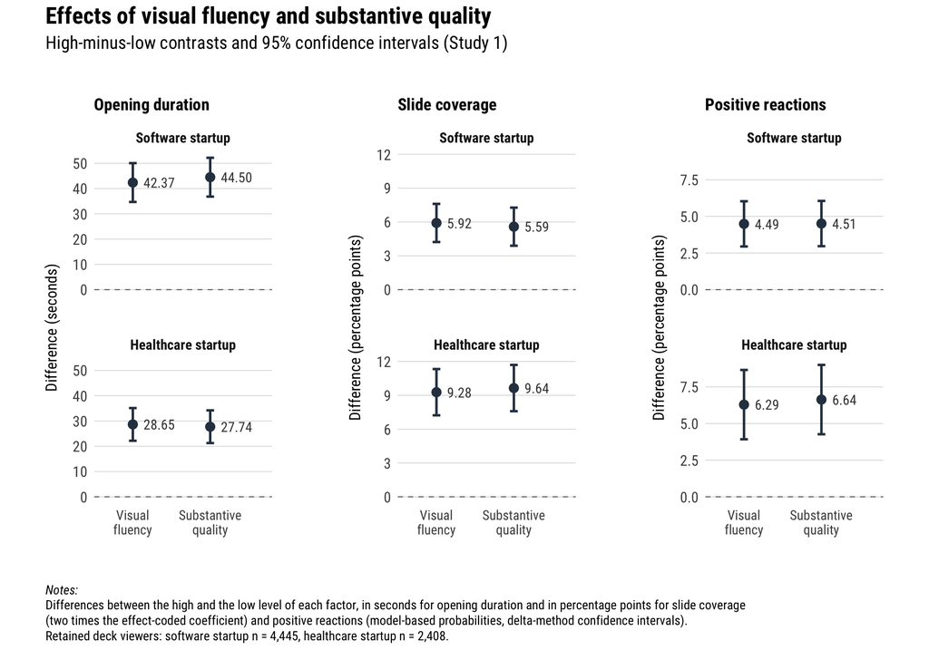

Figure 1: Effects of visual fluency and substantive quality in Study 1

```r
# theme settings
s1_theme <- theme(panel.grid.major.x = element_blank(),
        panel.grid.minor = element_blank(),
        plot.title = element_markdown(size = 13, family = "Roboto Condensed", face = "plain", hjust = 0),
        strip.text = element_markdown(size = 11, hjust = .5, lineheight = 1.2),
        axis.text.x = element_text(size = 10.5),
        axis.title.y = element_text(size = 12, hjust = .5, margin = margin(t = 0, r = 10, b = 0, l = 0)),
        axis.title.x = element_text(size = 12, hjust = .5, margin = margin(t = 5, r = 0, b = 0, l = 0)),
        )

# data prep: fluency and quality effects of Table 2, Panel B
s1_fig <- s1_effects |>
  filter(effect != "interaction") |>
  mutate(startup = factor(paste0("<b>", startup, " startup</b>"),
                          levels = c("<b>Software startup</b>", "<b>Healthcare startup</b>")),
         effect = factor(ifelse(effect == "fluency", "Visual\nfluency", "Substantive\nquality"),
                         levels = c("Visual\nfluency", "Substantive\nquality")))

# figure: opening duration (seconds)
s1_fig_dur <- ggplot(filter(s1_fig, outcome == "duration"), aes(x = effect, y = estimate)) +
  geom_hline(yintercept = 0, linetype = "dashed", color = "gray45", linewidth = .4) +
  geom_errorbar(aes(ymin = lower, ymax = upper), width = .1, linewidth = .9, color = blue_dark) +
  geom_point(size = 3, color = blue_dark) +
  geom_text(aes(label = sprintf("%.2f", estimate)), nudge_x = .14, hjust = 0, size = 3.8,
            color = "gray25", family = "Roboto Condensed") +
  facet_wrap(vars(startup), ncol = 1) +
  scale_x_discrete(expand = expansion(add = c(.5, .8))) +
  expand_limits(y = 0) +
  hrbrthemes::theme_ipsum_rc() + s1_theme +
  labs(x = NULL, y = "Difference (seconds)", title = "<b>Opening duration</b>")

# figure: slide coverage (percentage points)
s1_fig_cov <- ggplot(filter(s1_fig, outcome == "coverage"), aes(x = effect, y = estimate)) +
  geom_hline(yintercept = 0, linetype = "dashed", color = "gray45", linewidth = .4) +
  geom_errorbar(aes(ymin = lower, ymax = upper), width = .1, linewidth = .9, color = blue_dark) +
  geom_point(size = 3, color = blue_dark) +
  geom_text(aes(label = sprintf("%.2f", estimate)), nudge_x = .14, hjust = 0, size = 3.8,
            color = "gray25", family = "Roboto Condensed") +
  facet_wrap(vars(startup), ncol = 1) +
  scale_x_discrete(expand = expansion(add = c(.5, .8))) +
  expand_limits(y = 0) +
  hrbrthemes::theme_ipsum_rc() + s1_theme +
  labs(x = NULL, y = "Difference (percentage points)", title = "<b>Slide coverage</b>")

# figure: positive reactions (percentage points)
s1_fig_pos <- ggplot(filter(s1_fig, outcome == "positive"), aes(x = effect, y = estimate)) +
  geom_hline(yintercept = 0, linetype = "dashed", color = "gray45", linewidth = .4) +
  geom_errorbar(aes(ymin = lower, ymax = upper), width = .1, linewidth = .9, color = blue_dark) +
  geom_point(size = 3, color = blue_dark) +
  geom_text(aes(label = sprintf("%.2f", estimate)), nudge_x = .14, hjust = 0, size = 3.8,
            color = "gray25", family = "Roboto Condensed") +
  facet_wrap(vars(startup), ncol = 1) +
  scale_x_discrete(expand = expansion(add = c(.5, .8))) +
  expand_limits(y = 0) +
  hrbrthemes::theme_ipsum_rc() + s1_theme +
  labs(x = NULL, y = "Difference (percentage points)", title = "<b>Positive reactions</b>")

# final (combined) figure
s1_fig_dur + s1_fig_cov + s1_fig_pos +
  plot_annotation(
  title = "<b>Effects of visual fluency and substantive quality</b>",
  subtitle = "High-minus-low contrasts and 95% confidence intervals (Study 1)",
  caption = paste0("<i>Notes:</i><br>", "Differences between the high and the low level of each factor, in seconds for opening duration and in percentage points for slide coverage<br>",
                   "(two times the effect-coded coefficient) and positive reactions (model-based probabilities, delta-method confidence intervals).<br>",
                   "Retained deck viewers: software startup n = ", scales::comma(nrow(s1_sw)),
                   ", healthcare startup n = ", scales::comma(nrow(s1_hc)), "."),
  theme = theme(
    plot.title = element_markdown(size = 18, family = "Roboto Condensed", face = "plain"),
    plot.subtitle = element_text(size = 14, family = "Roboto Condensed"),
    plot.caption.position = "plot", plot.caption = element_markdown(hjust = 0, lineheight = 1.2, family = "Roboto Condensed", size = 10, margin = margin(t = 7, r = 0, b = 0, l = 0)))
)
```

## 5.3 Covariate models

The preregistered robustness models added investment experience (the number of previous startup investments), investor type (reference: business angel), gender (reference: female), and country (reference: United States) to visual fluency, substantive quality, and their interaction, with the same effect coding. They are linear regressions for opening duration and slide coverage (Table C2 for the software startup, Table C3 for the healthcare startup) and a logistic regression for positive reactions. As a further preregistered robustness check, positive reactions were also modeled with a Tobit specification (Tables C4 and C5).

*Results.* With the covariates, visual fluency and substantive quality increased all three outcomes in both startups (all *p* < .001), as they did without covariates. The fluency × quality interactions remained negative and significant for the software startup (opening duration *p* = .013, slide coverage *p* = .041, positive reactions *p* < .001) and not significant for the healthcare startup (*p* = .450, *p* = .376, and *p* = .209). The Tobit models showed the same pattern (fluency and quality both *p* < .001, interaction software *p* < .001, healthcare *p* = .303).

```r
bind_rows(coef_rows(s1_mc_dur_sw, s1_terms, digits = 2),
          data.frame(Term = c("R<sup>2</sup>", "Adjusted R<sup>2</sup>"),
                     Estimate = weights::rd(c(summary(s1_mc_dur_sw)$r.squared, summary(s1_mc_dur_sw)$adj.r.squared), 3)),
          coef_rows(s1_mc_cov_sw, s1_terms, digits = 3),
          data.frame(Term = c("R<sup>2</sup>", "Adjusted R<sup>2</sup>"),
                     Estimate = weights::rd(c(summary(s1_mc_cov_sw)$r.squared, summary(s1_mc_cov_sw)$adj.r.squared), 3))) |>
  kbl(col.names = c("", "Coeff.", "SE", "95% CI", "t", "p"),
      caption = "Table C2: Linear regressions with control variables for opening duration and slide coverage, Study 1 (software startup)",
      align = "lccccc", escape = FALSE) |>
  kable_styling() |>
  column_spec(1:6, extra_css = "white-space: nowrap;", include_thead = TRUE) |>
  pack_rows(index = c("Opening duration" = 18, "Slide coverage" = 18), label_row_css = "text-align: center;") |>
  repeat_header()
```

Table C2: Linear regressions with control variables for opening duration and slide coverage, Study 1 (software startup)

|  | Coeff. | SE | 95% CI | t | p |
| --- | --- | --- | --- | --- | --- |
| **Opening duration** |  |  |  |  |  |
| Intercept | 150.53 | 6.613 | [137.57, 163.50] | 22.76 | < .001 |
| Fluency | 21.30 | 1.961 | [17.46, 25.15] | 10.86 | < .001 |
| Quality | 22.34 | 1.963 | [18.49, 26.19] | 11.38 | < .001 |
| Fluency × Quality | -4.89 | 1.962 | [-8.74, -1.05] | -2.49 | .013 |
| Investment experience | 0.13 | 0.545 | [-0.94, 1.20] | 0.24 | .809 |
| Investor type [Venture capital] | 1.81 | 5.204 | [-8.39, 12.01] | 0.35 | .728 |
| Gender [Male] | -8.22 | 6.723 | [-21.40, 4.96] | -1.22 | .221 |
| Country [Brazil] | -4.54 | 25.717 | [-54.96, 45.88] | -0.18 | .860 |
| Country [Canada] | 8.39 | 13.659 | [-18.39, 35.17] | 0.61 | .539 |
| Country [China] | -26.28 | 28.021 | [-81.22, 28.65] | -0.94 | .348 |
| Country [France] | -9.67 | 15.470 | [-40.00, 20.66] | -0.63 | .532 |
| Country [Germany] | -0.27 | 13.131 | [-26.02, 25.47] | -0.02 | .983 |
| Country [India] | 12.18 | 10.928 | [-9.25, 33.60] | 1.11 | .265 |
| Country [Israel] | -23.51 | 17.964 | [-58.72, 11.71] | -1.31 | .191 |
| Country [Singapore] | -43.21 | 18.084 | [-78.66, -7.75] | -2.39 | .017 |
| Country [United Kingdom] | -1.83 | 7.580 | [-16.69, 13.03] | -0.24 | .809 |
| R<sup>2</sup> | .057 |  |  |  |  |
| Adjusted R<sup>2</sup> | .054 |  |  |  |  |
|  | Coeff. | SE | 95% CI | t | p |
| **Slide coverage** |  |  |  |  |  |
| Intercept | 0.671 | 0.015 | [0.643, 0.700] | 46.15 | < .001 |
| Fluency | 0.030 | 0.004 | [0.021, 0.038] | 6.89 | < .001 |
| Quality | 0.028 | 0.004 | [0.019, 0.036] | 6.47 | < .001 |
| Fluency × Quality | -0.009 | 0.004 | [-0.017, -0.000] | -2.05 | .041 |
| Investment experience | 0.001 | 0.001 | [-0.001, 0.003] | 0.83 | .406 |
| Investor type [Venture capital] | -0.002 | 0.011 | [-0.025, 0.020] | -0.20 | .841 |
| Gender [Male] | 0.005 | 0.015 | [-0.024, 0.034] | 0.32 | .753 |
| Country [Brazil] | 0.039 | 0.057 | [-0.072, 0.150] | 0.69 | .493 |
| Country [Canada] | 0.022 | 0.030 | [-0.037, 0.081] | 0.72 | .469 |
| Country [China] | -0.050 | 0.062 | [-0.171, 0.071] | -0.82 | .415 |
| Country [France] | 0.023 | 0.034 | [-0.043, 0.090] | 0.69 | .492 |
| Country [Germany] | 0.056 | 0.029 | [-0.000, 0.113] | 1.95 | .051 |
| Country [India] | 0.017 | 0.024 | [-0.031, 0.064] | 0.69 | .492 |
| Country [Israel] | -0.014 | 0.040 | [-0.092, 0.063] | -0.36 | .721 |
| Country [Singapore] | -0.030 | 0.040 | [-0.108, 0.048] | -0.75 | .453 |
| Country [United Kingdom] | 0.003 | 0.017 | [-0.030, 0.035] | 0.16 | .873 |
| R<sup>2</sup> | .023 |  |  |  |  |
| Adjusted R<sup>2</sup> | .019 |  |  |  |  |

```r
bind_rows(coef_rows(s1_mc_dur_hc, s1_terms, digits = 2),
          data.frame(Term = c("R<sup>2</sup>", "Adjusted R<sup>2</sup>"),
                     Estimate = weights::rd(c(summary(s1_mc_dur_hc)$r.squared, summary(s1_mc_dur_hc)$adj.r.squared), 3)),
          coef_rows(s1_mc_cov_hc, s1_terms, digits = 3),
          data.frame(Term = c("R<sup>2</sup>", "Adjusted R<sup>2</sup>"),
                     Estimate = weights::rd(c(summary(s1_mc_cov_hc)$r.squared, summary(s1_mc_cov_hc)$adj.r.squared), 3))) |>
  kbl(col.names = c("", "Coeff.", "SE", "95% CI", "t", "p"),
      caption = "Table C3: Linear regressions with control variables for opening duration and slide coverage, Study 1 (healthcare startup)",
      align = "lccccc", escape = FALSE) |>
  kable_styling() |>
  column_spec(1:6, extra_css = "white-space: nowrap;", include_thead = TRUE) |>
  pack_rows(index = c("Opening duration" = 18, "Slide coverage" = 18), label_row_css = "text-align: center;") |>
  repeat_header()
```

Table C3: Linear regressions with control variables for opening duration and slide coverage, Study 1 (healthcare startup)

|  | Coeff. | SE | 95% CI | t | p |
| --- | --- | --- | --- | --- | --- |
| **Opening duration** |  |  |  |  |  |
| Intercept | 94.95 | 5.429 | [84.30, 105.59] | 17.49 | < .001 |
| Fluency | 14.26 | 1.656 | [11.01, 17.51] | 8.61 | < .001 |
| Quality | 13.98 | 1.655 | [10.73, 17.22] | 8.44 | < .001 |
| Fluency × Quality | -1.25 | 1.652 | [-4.49, 1.99] | -0.76 | .450 |
| Investment experience | 0.51 | 0.941 | [-1.34, 2.35] | 0.54 | .591 |
| Investor type [Venture capital] | -1.68 | 3.813 | [-9.15, 5.80] | -0.44 | .660 |
| Gender [Male] | 3.30 | 5.233 | [-6.96, 13.56] | 0.63 | .529 |
| Country [Brazil] | 28.11 | 20.989 | [-13.04, 69.27] | 1.34 | .181 |
| Country [Canada] | 13.71 | 11.545 | [-8.93, 36.35] | 1.19 | .235 |
| Country [China] | -2.76 | 12.794 | [-27.84, 22.33] | -0.22 | .829 |
| Country [France] | -7.92 | 10.031 | [-27.59, 11.76] | -0.79 | .430 |
| Country [Germany] | 5.16 | 10.585 | [-15.60, 25.92] | 0.49 | .626 |
| Country [India] | 8.36 | 10.989 | [-13.19, 29.91] | 0.76 | .447 |
| Country [Israel] | 28.37 | 14.915 | [-0.88, 57.62] | 1.90 | .057 |
| Country [Singapore] | -11.10 | 13.436 | [-37.45, 15.25] | -0.83 | .409 |
| Country [United Kingdom] | -4.76 | 6.180 | [-16.88, 7.36] | -0.77 | .441 |
| R<sup>2</sup> | .062 |  |  |  |  |
| Adjusted R<sup>2</sup> | .056 |  |  |  |  |
|  | Coeff. | SE | 95% CI | t | p |
| **Slide coverage** |  |  |  |  |  |
| Intercept | 0.679 | 0.017 | [0.646, 0.713] | 39.43 | < .001 |
| Fluency | 0.046 | 0.005 | [0.036, 0.057] | 8.81 | < .001 |
| Quality | 0.048 | 0.005 | [0.038, 0.059] | 9.18 | < .001 |
| Fluency × Quality | -0.005 | 0.005 | [-0.015, 0.006] | -0.89 | .376 |
| Investment experience | 0.004 | 0.003 | [-0.002, 0.010] | 1.43 | .153 |
| Investor type [Venture capital] | -0.017 | 0.012 | [-0.041, 0.007] | -1.40 | .161 |
| Gender [Male] | 0.000 | 0.017 | [-0.032, 0.033] | 0.03 | .977 |
| Country [Brazil] | 0.056 | 0.067 | [-0.075, 0.186] | 0.84 | .403 |
| Country [Canada] | 0.032 | 0.037 | [-0.040, 0.104] | 0.88 | .381 |
| Country [China] | -0.031 | 0.041 | [-0.111, 0.049] | -0.77 | .444 |
| Country [France] | -0.012 | 0.032 | [-0.074, 0.051] | -0.37 | .712 |
| Country [Germany] | 0.018 | 0.034 | [-0.048, 0.084] | 0.54 | .590 |
| Country [India] | 0.021 | 0.035 | [-0.047, 0.090] | 0.61 | .543 |
| Country [Israel] | 0.004 | 0.047 | [-0.089, 0.096] | 0.08 | .939 |
| Country [Singapore] | 0.056 | 0.043 | [-0.028, 0.139] | 1.31 | .191 |
| Country [United Kingdom] | 0.023 | 0.020 | [-0.016, 0.061] | 1.17 | .243 |
| R<sup>2</sup> | .068 |  |  |  |  |
| Adjusted R<sup>2</sup> | .062 |  |  |  |  |

*Notes:* Fluency and quality were effect coded (low = −1, high = +1). Reference levels: business angel (investor type), female (gender), and United States (country). Investment experience is the number of previous startup investments. Opening duration in seconds, slide coverage as the proportion of pitch deck slides viewed (0–1). Two-sided *t*-tests and *t*-based 95% confidence intervals. *N* = 4,445 (Table C2) and 2,408 (Table C3) retained deck viewers.

```r
bind_rows(coef_rows(s1_mc_pos_sw, s1_terms, digits = 3),
          data.frame(Term = "Tjur’s R<sup>2</sup>", Estimate = weights::rd(unname(performance::r2_tjur(s1_mc_pos_sw)), 3)),
          coef_rows(s1_mc_tob_sw, s1_terms, digits = 3),
          data.frame(Term = "Nagelkerke’s R<sup>2</sup>", Estimate = weights::rd(unname(performance::r2_nagelkerke(s1_mc_tob_sw)), 3))) |>
  kbl(col.names = c("", "Coeff.", "SE", "95% CI", "z", "p"),
      caption = "Table C4: Binary logit and Tobit models with control variables for positive reactions, Study 1 (software startup)",
      align = "lccccc", escape = FALSE) |>
  kable_styling() |>
  column_spec(1:6, extra_css = "white-space: nowrap;", include_thead = TRUE) |>
  pack_rows(index = c("Binary logit" = 17, "Tobit" = 17), label_row_css = "text-align: center;") |>
  repeat_header()
```

Table C4: Binary logit and Tobit models with control variables for positive reactions, Study 1 (software startup)

|  | Coeff. | SE | 95% CI | z | p |
| --- | --- | --- | --- | --- | --- |
| **Binary logit** |  |  |  |  |  |
| Intercept | -2.653 | 0.200 | [-3.045, -2.262] | -13.30 | < .001 |
| Fluency | 0.416 | 0.067 | [0.286, 0.547] | 6.23 | < .001 |
| Quality | 0.420 | 0.067 | [0.289, 0.551] | 6.28 | < .001 |
| Fluency × Quality | -0.233 | 0.067 | [-0.364, -0.102] | -3.49 | < .001 |
| Investment experience | 0.014 | 0.012 | [-0.010, 0.039] | 1.14 | .255 |
| Investor type [Venture capital] | -0.030 | 0.152 | [-0.327, 0.267] | -0.20 | .845 |
| Gender [Male] | -0.002 | 0.201 | [-0.397, 0.392] | -0.01 | .991 |
| Country [Brazil] | -0.683 | 1.026 | [-2.694, 1.328] | -0.67 | .506 |
| Country [Canada] | -0.029 | 0.402 | [-0.817, 0.758] | -0.07 | .942 |
| Country [China] | -0.685 | 1.030 | [-2.704, 1.334] | -0.66 | .506 |
| Country [France] | -0.352 | 0.522 | [-1.374, 0.671] | -0.67 | .500 |
| Country [Germany] | 0.051 | 0.377 | [-0.688, 0.790] | 0.14 | .892 |
| Country [India] | -0.359 | 0.371 | [-1.086, 0.369] | -0.97 | .334 |
| Country [Israel] | 0.503 | 0.416 | [-0.312, 1.319] | 1.21 | .226 |
| Country [Singapore] | 0.631 | 0.416 | [-0.185, 1.447] | 1.51 | .130 |
| Country [United Kingdom] | -0.286 | 0.247 | [-0.769, 0.198] | -1.16 | .247 |
| Tjur’s R<sup>2</sup> | .018 |  |  |  |  |
|  | Coeff. | SE | 95% CI | z | p |
| **Tobit** |  |  |  |  |  |
| Intercept | -2.797 | 0.236 | [-3.259, -2.334] | -11.86 | < .001 |
| Fluency | 0.360 | 0.058 | [0.246, 0.475] | 6.16 | < .001 |
| Quality | 0.361 | 0.058 | [0.246, 0.475] | 6.17 | < .001 |
| Fluency × Quality | -0.191 | 0.057 | [-0.302, -0.080] | -3.36 | < .001 |
| Investment experience | 0.012 | 0.012 | [-0.012, 0.036] | 0.99 | .321 |
| Investor type [Venture capital] | -0.036 | 0.138 | [-0.307, 0.234] | -0.26 | .792 |
| Gender [Male] | 0.026 | 0.183 | [-0.333, 0.385] | 0.14 | .887 |
| Country [Brazil] | -0.589 | 0.845 | [-2.245, 1.067] | -0.70 | .486 |
| Country [Canada] | 0.009 | 0.361 | [-0.699, 0.716] | 0.02 | .981 |
| Country [China] | -0.577 | 0.859 | [-2.260, 1.106] | -0.67 | .502 |
| Country [France] | -0.329 | 0.456 | [-1.223, 0.564] | -0.72 | .470 |
| Country [Germany] | 0.126 | 0.337 | [-0.534, 0.785] | 0.37 | .708 |
| Country [India] | -0.336 | 0.323 | [-0.970, 0.297] | -1.04 | .298 |
| Country [Israel] | 0.447 | 0.409 | [-0.355, 1.250] | 1.09 | .275 |
| Country [Singapore] | 0.600 | 0.407 | [-0.198, 1.397] | 1.47 | .141 |
| Country [United Kingdom] | -0.239 | 0.216 | [-0.662, 0.184] | -1.11 | .268 |
| Nagelkerke’s R<sup>2</sup> | .041 |  |  |  |  |

```r
bind_rows(coef_rows(s1_mc_pos_hc, s1_terms, digits = 3),
          data.frame(Term = "Tjur’s R<sup>2</sup>", Estimate = weights::rd(unname(performance::r2_tjur(s1_mc_pos_hc)), 3)),
          coef_rows(s1_mc_tob_hc, s1_terms, digits = 3),
          data.frame(Term = "Nagelkerke’s R<sup>2</sup>", Estimate = weights::rd(unname(performance::r2_nagelkerke(s1_mc_tob_hc)), 3))) |>
  kbl(col.names = c("", "Coeff.", "SE", "95% CI", "z", "p"),
      caption = "Table C5: Binary logit and Tobit models with control variables for positive reactions, Study 1 (healthcare startup)",
      align = "lccccc", escape = FALSE) |>
  kable_styling() |>
  column_spec(1:6, extra_css = "white-space: nowrap;", include_thead = TRUE) |>
  pack_rows(index = c("Binary logit" = 17, "Tobit" = 17), label_row_css = "text-align: center;") |>
  repeat_header()
```

Table C5: Binary logit and Tobit models with control variables for positive reactions, Study 1 (healthcare startup)

|  | Coeff. | SE | 95% CI | z | p |
| --- | --- | --- | --- | --- | --- |
| **Binary logit** |  |  |  |  |  |
| Intercept | -2.033 | 0.215 | [-2.454, -1.613] | -9.47 | < .001 |
| Fluency | 0.398 | 0.078 | [0.245, 0.550] | 5.11 | < .001 |
| Quality | 0.432 | 0.078 | [0.279, 0.585] | 5.54 | < .001 |
| Fluency × Quality | -0.098 | 0.078 | [-0.250, 0.055] | -1.26 | .209 |
| Investment experience | -0.024 | 0.051 | [-0.125, 0.076] | -0.47 | .638 |
| Investor type [Venture capital] | 0.007 | 0.168 | [-0.323, 0.337] | 0.04 | .967 |
| Gender [Male] | -0.387 | 0.201 | [-0.782, 0.008] | -1.92 | .055 |
| Country [Brazil] | -0.477 | 1.044 | [-2.523, 1.570] | -0.46 | .648 |
| Country [Canada] | 0.488 | 0.425 | [-0.345, 1.320] | 1.15 | .251 |
| Country [China] | -0.152 | 0.545 | [-1.220, 0.917] | -0.28 | .781 |
| Country [France] | 0.809 | 0.328 | [0.167, 1.452] | 2.47 | .014 |
| Country [Germany] | 0.643 | 0.380 | [-0.102, 1.388] | 1.69 | .091 |
| Country [India] | -0.302 | 0.531 | [-1.343, 0.740] | -0.57 | .570 |
| Country [Israel] | 0.128 | 0.624 | [-1.095, 1.352] | 0.21 | .837 |
| Country [Singapore] | 0.421 | 0.495 | [-0.550, 1.391] | 0.85 | .396 |
| Country [United Kingdom] | 0.167 | 0.251 | [-0.325, 0.659] | 0.67 | .506 |
| Tjur’s R<sup>2</sup> | .031 |  |  |  |  |
|  | Coeff. | SE | 95% CI | z | p |
| **Tobit** |  |  |  |  |  |
| Intercept | -1.999 | 0.232 | [-2.455, -1.544] | -8.61 | < .001 |
| Fluency | 0.337 | 0.066 | [0.207, 0.467] | 5.09 | < .001 |
| Quality | 0.366 | 0.067 | [0.235, 0.496] | 5.49 | < .001 |
| Fluency × Quality | -0.066 | 0.064 | [-0.191, 0.059] | -1.03 | .303 |
| Investment experience | -0.021 | 0.043 | [-0.106, 0.063] | -0.49 | .622 |
| Investor type [Venture capital] | -0.018 | 0.144 | [-0.301, 0.265] | -0.13 | .900 |
| Gender [Male] | -0.360 | 0.181 | [-0.714, -0.006] | -1.99 | .046 |
| Country [Brazil] | -0.359 | 0.843 | [-2.011, 1.293] | -0.43 | .670 |
| Country [Canada] | 0.444 | 0.385 | [-0.310, 1.197] | 1.15 | .249 |
| Country [China] | -0.100 | 0.469 | [-1.020, 0.820] | -0.21 | .832 |
| Country [France] | 0.714 | 0.310 | [0.106, 1.323] | 2.30 | .021 |
| Country [Germany] | 0.591 | 0.348 | [-0.090, 1.273] | 1.70 | .089 |
| Country [India] | -0.220 | 0.439 | [-1.081, 0.640] | -0.50 | .616 |
| Country [Israel] | 0.047 | 0.558 | [-1.046, 1.141] | 0.08 | .932 |
| Country [Singapore] | 0.318 | 0.456 | [-0.577, 1.212] | 0.70 | .486 |
| Country [United Kingdom] | 0.171 | 0.219 | [-0.258, 0.600] | 0.78 | .436 |
| Nagelkerke’s R<sup>2</sup> | .054 |  |  |  |  |

*Notes:* Fluency and quality were effect coded (low = −1, high = +1). Reference levels: business angel (investor type), female (gender), and United States (country). Investment experience is the number of previous startup investments. Positive reaction is a binary indicator (1 = yes, 0 = no). Binary logit coefficients are on the log-odds scale, and the Tobit model is left-censored at 0. Two-sided Wald *z*-tests and Wald 95% confidence intervals. *N* = 4,445 (Table C4) and 2,408 (Table C5) retained deck viewers.

## 5.4 Domain comparison

The preregistration planned an exploratory comparison of the two startups if the main results differed between the domains, by adding the interaction with the domain to the analyses (AsPredicted #118675). It did not specify the model. For this comparison, we pooled the two samples and fitted a full-factorial model of visual fluency × substantive quality × startup domain for each outcome (linear regressions for opening duration and slide coverage, a logistic regression for positive reactions), with all three factors effect coded (software = +1, healthcare = −1). In these models, four times the fluency × domain and the quality × domain coefficients are the differences between the startups in the fluency and the quality contrasts of Table 2, Panel B (software minus healthcare), and eight times the three-way coefficient is the difference in the interaction contrasts. For positive reactions, the differences between the startups refer to the percentage-point contrasts of Table 2, Panel B, from the model-based probabilities of the pooled logistic regression, with delta-method confidence intervals and z tests. Table C6 reports all nine comparisons.

*Results.* The fluency and the quality effects on opening duration were larger for the software startup (*p* = .019 and *p* = .004), whereas their effects on slide coverage were larger for the healthcare startup (*p* = .016 and *p* = .004). Their effects on positive reactions did not differ significantly between the startups (*p* = .211 and *p* = .141). The fluency × quality interactions did not differ significantly between the startups for opening duration, slide coverage, or positive reactions (*p* = .232, *p* = .579, and *p* = .191). The significant interactions of the software startup on opening duration and slide coverage and the nonsignificant interactions of the healthcare startup therefore do not establish a difference between the domains.

```r
s1_domain |>
  mutate(Outcome = rep(c("Opening duration (s)", "Slide coverage (pp)", "Positive reactions (pp)"), each = 3),
         Effect = rep(c("Visual fluency", "Substantive quality", "Fluency × Quality"), 3),
         Software = f2(s1_effects$estimate[1:9]), Healthcare = f2(s1_effects$estimate[10:18]),
         Comparison = f2(estimate), CI = ci_txt(lower, upper), p = p_tbl(p)) |>
  select(Outcome, Effect, Software, Healthcare, Comparison, CI, p) |>
  kbl(col.names = c("Outcome", "Effect", "Software", "Healthcare", "Comparison", "95% CI", "p"),
      caption = "Table C6: Comparisons between the software and healthcare startups, Study 1",
      align = "llccccc", escape = FALSE) |>
  kable_styling() |>
  column_spec(1:7, extra_css = "white-space: nowrap;", include_thead = TRUE) |>
  row_spec(c(3, 6), extra_css = "border-bottom: 1px solid") |>
  collapse_rows(columns = 1, valign = "top")
```

Table C6: Comparisons between the software and healthcare startups, Study 1

| Outcome | Effect | Software | Healthcare | Comparison | 95% CI | p |
| --- | --- | --- | --- | --- | --- | --- |
| Opening duration (s) | Visual fluency | 42.37 | 28.65 | 13.72 | [2.25, 25.19] | .019 |
|  | Substantive quality | 44.50 | 27.74 | 16.76 | [5.29, 28.23] | .004 |
|  | Fluency × Quality | -19.00 | -5.01 | -13.99 | [-36.94, 8.95] | .232 |
| Slide coverage (pp) | Visual fluency | 5.92 | 9.28 | -3.36 | [-6.11, -0.62] | .016 |
|  | Substantive quality | 5.59 | 9.64 | -4.06 | [-6.81, -1.31] | .004 |
|  | Fluency × Quality | -3.51 | -1.95 | -1.56 | [-7.05, 3.94] | .579 |
| Positive reactions (pp) | Visual fluency | 4.49 | 6.29 | -1.80 | [-4.63, 1.02] | .211 |
|  | Substantive quality | 4.51 | 6.64 | -2.12 | [-4.95, 0.70] | .141 |
|  | Fluency × Quality | -2.61 | 1.16 | -3.77 | [-9.42, 1.88] | .191 |

*Notes:* Preregistered exploratory analysis with the full-factorial specification chosen for this comparison. Software and Healthcare are the contrasts of Table 2, Panel B. Comparison is the software minus the healthcare contrast, in seconds (s) for opening duration and in percentage points (pp) for slide coverage and positive reactions, from full-factorial models of visual fluency × substantive quality × startup domain on the pooled samples (*N* = 6,853). Two-sided *t*-tests (linear regressions) and delta-method *z*-tests (logistic regression), with the corresponding 95% confidence intervals.

# 6 Studies 2A–2C: Investment Evaluation

This section reproduces the results of Studies 2A–2C and Appendix D. The data processing, exclusions, and further analyses are documented in the Studies 2A–2C: Investment Evaluation Reproducibility Report. The dependent variable is investment likelihood, the stated probability of investing in the startup on a 0–100% scale, so that differences between conditions are in percentage points.

```r
# Study 2A: software startup, AsPredicted Preregistration #114380
# Study 2B: software startup (replication), AsPredicted Preregistration #116872
# Study 2C: healthcare startup, AsPredicted Preregistration #117215
#
# processed data (one row per participant)
s2a <- readr::read_csv(here(processed_dir, 'Study_2A_Software.csv'))
s2b <- readr::read_csv(here(processed_dir, 'Study_2B_Software_Replication.csv'))
s2c <- readr::read_csv(here(processed_dir, 'Study_2C_Healthcare.csv'))
# survey exports: number of recorded and finished responses
s2a_raw <- readr::read_csv(here(raw_dir, 'Study_2A_Software_Qualtrics.csv'))
s2b_raw <- readr::read_csv(here(raw_dir, 'Study_2B_Software_Replication_Qualtrics.csv'))
s2c_raw <- readr::read_csv(here(raw_dir, 'Study_2C_Healthcare_Qualtrics.csv'))
s2a_n <- c(recorded = nrow(s2a_raw), finished = sum(s2a_raw$Finished))
s2b_n <- c(recorded = nrow(s2b_raw), finished = sum(s2b_raw$Finished))
s2c_n <- c(recorded = nrow(s2c_raw), finished = sum(s2c_raw$Finished))

# manipulation checks of Studies 2B and 2C: processing ease (0-100) and
# perceived venture quality (1-7)
s2b <- s2b |> rename(mc_ease = fluency, mc_quality = quality)
s2c <- s2c |> rename(mc_ease = fluency, mc_quality = quality)

# recode the CVPA items into numeric values and average the 11 items
s2a <- s2a |> mutate_at(vars(cvpa_v_1:cvpa_r_3), dplyr::recode, 'Strongly disagree' = 1, 'Disagree' = 2,
                        'Neither agree nor disagree' = 3, 'Agree' = 4, 'Strongly agree' = 5)
s2a <- s2a |> rowwise() |> mutate(CVPA = mean(c_across(cvpa_v_1:cvpa_r_3))) |> ungroup()
s2b <- s2b |> mutate_at(vars(cvpa_v_1:cvpa_r_3), dplyr::recode, 'Strongly disagree' = 1, 'Disagree' = 2,
                        'Neither agree nor disagree' = 3, 'Agree' = 4, 'Strongly agree' = 5)
s2b <- s2b |> rowwise() |> mutate(CVPA = mean(c_across(cvpa_v_1:cvpa_r_3))) |> ungroup()
s2c <- s2c |> mutate_at(vars(cvpa_v_1:cvpa_r_3), dplyr::recode, 'Strongly disagree' = 1, 'Disagree' = 2,
                        'Neither agree nor disagree' = 3, 'Agree' = 4, 'Strongly agree' = 5)
s2c <- s2c |> rowwise() |> mutate(CVPA = mean(c_across(cvpa_v_1:cvpa_r_3))) |> ungroup()

# group "Non-binary" and "Prefer not to say" into one gender category
s2a$gender <- forcats::fct_collapse(s2a$gender, Female = "Female", Male = "Male", other_level = "Other")
s2b$gender <- forcats::fct_collapse(s2b$gender, Female = "Female", Male = "Male", other_level = "Other")
s2c$gender <- forcats::fct_collapse(s2c$gender, Female = "Female", Male = "Male", other_level = "Other")

# convert conditions into factors with effect coding (high = 1, low = -1)
s2a$fluency <- factor(s2a$fluency_condition, levels = c("high", "low"))
s2a$quality <- factor(s2a$quality_condition, levels = c("high", "low"))
contrasts(s2a$fluency) <- contr.sum
contrasts(s2a$quality) <- contr.sum
s2b$fluency <- factor(s2b$fluency_condition, levels = c("high", "low"))
s2b$quality <- factor(s2b$quality_condition, levels = c("high", "low"))
contrasts(s2b$fluency) <- contr.sum
contrasts(s2b$quality) <- contr.sum
s2c$fluency <- factor(s2c$fluency_condition, levels = c("high", "low"))
s2c$quality <- factor(s2c$quality_condition, levels = c("high", "low"))
contrasts(s2c$fluency) <- contr.sum
contrasts(s2c$quality) <- contr.sum

# preregistered two-factor ANOVAs (type III) and the high minus low contrasts
# of the same models
s2a_m <- lm(invest_prob ~ fluency * quality, s2a)
s2a_anova <- anova_3(s2a_m)
s2a_fluency <- lm_diff(s2a_m, "fluency1")
s2a_quality <- lm_diff(s2a_m, "quality1")
s2a_interaction <- lm_diff(s2a_m, "fluency1:quality1", multiplier = 4)
s2b_m <- lm(invest_prob ~ fluency * quality, s2b)
s2b_anova <- anova_3(s2b_m)
s2b_fluency <- lm_diff(s2b_m, "fluency1")
s2b_quality <- lm_diff(s2b_m, "quality1")
s2b_interaction <- lm_diff(s2b_m, "fluency1:quality1", multiplier = 4)
s2c_m <- lm(invest_prob ~ fluency * quality, s2c)
s2c_anova <- anova_3(s2c_m)
s2c_fluency <- lm_diff(s2c_m, "fluency1")
s2c_quality <- lm_diff(s2c_m, "quality1")
s2c_interaction <- lm_diff(s2c_m, "fluency1:quality1", multiplier = 4)

# condition counts, means, and standard deviations
s2a_cells <- s2a |> group_by(fluency, quality) |>
  summarize(N = n(), Mean = mean(invest_prob), SD = sd(invest_prob), .groups = "drop")
s2b_cells <- s2b |> group_by(fluency, quality) |>
  summarize(N = n(), Mean = mean(invest_prob), SD = sd(invest_prob), .groups = "drop")
s2c_cells <- s2c |> group_by(fluency, quality) |>
  summarize(N = n(), Mean = mean(invest_prob), SD = sd(invest_prob), .groups = "drop")

# Levene's tests of homogeneous group variances (preregistered condition for
# the robust regression): by fluency, by quality, and by the four cells
s2_levene <- c(
  car::leveneTest(invest_prob ~ fluency, s2a)$`Pr(>F)`[1],
  car::leveneTest(invest_prob ~ quality, s2a)$`Pr(>F)`[1],
  car::leveneTest(invest_prob ~ fluency * quality, s2a)$`Pr(>F)`[1],
  car::leveneTest(invest_prob ~ fluency, s2b)$`Pr(>F)`[1],
  car::leveneTest(invest_prob ~ quality, s2b)$`Pr(>F)`[1],
  car::leveneTest(invest_prob ~ fluency * quality, s2b)$`Pr(>F)`[1],
  car::leveneTest(invest_prob ~ fluency, s2c)$`Pr(>F)`[1],
  car::leveneTest(invest_prob ~ quality, s2c)$`Pr(>F)`[1],
  car::leveneTest(invest_prob ~ fluency * quality, s2c)$`Pr(>F)`[1]
)

# preregistered covariate models: age, gender (reference: female), investment
# experience, and CVPA added to the two factors and their interaction
s2a_m_cov <- lm(invest_prob ~ fluency * quality + age + gender + invest_experience + CVPA, s2a)
s2b_m_cov <- lm(invest_prob ~ fluency * quality + age + gender + invest_experience + CVPA, s2b)
s2c_m_cov <- lm(invest_prob ~ fluency * quality + age + gender + invest_experience + CVPA, s2c)

# manipulation checks, Studies 2B and 2C: t-tests of processing ease by visual
# fluency and of perceived venture quality by substantive quality
s2b_t_ease_fluency <- ttest_diff(mc_ease ~ fluency, s2b)
s2b_t_mcq_quality <- ttest_diff(mc_quality ~ quality, s2b)
s2c_t_ease_fluency <- ttest_diff(mc_ease ~ fluency, s2c)
s2c_t_mcq_quality <- ttest_diff(mc_quality ~ quality, s2c)
```

## 6.1 Sample

Each study used a 2 (visual fluency: high vs. low) × 2 (substantive quality: high vs. low) between-subjects design. Studies 2A and 2B used the software startup’s pitch deck, Study 2C the healthcare startup’s pitch deck. Participants studied one randomly assigned deck on DocSend and then answered the survey in Qualtrics. Qualtrics recorded 318 responses in Study 2A (296 finished), 331 in Study 2B (298 finished), and 329 in Study 2C (299 finished). The preregistered exclusions removed participants without consent, with incomplete responses, with a reported Prolific ID that differed from the recorded one, with a repeated Prolific ID or IP address, who took more than 30 minutes for the survey, whose cumulative deck-viewing time was below 30 seconds or above 30 minutes, who viewed less than 50% of the slides, or who failed the attention or the comprehension check. A further exclusion, which was not preregistered, removed participants whose condition recorded in Qualtrics differed from the deck condition recorded by DocSend. The final samples comprised 197 participants in Study 2A, 200 in Study 2B, and 193 in Study 2C. Table D1 describes the participants.

```r
s2a_gender <- table(factor(s2a$gender, levels = c("Male", "Female", "Other")))
s2b_gender <- table(factor(s2b$gender, levels = c("Male", "Female", "Other")))
s2c_gender <- table(factor(s2c$gender, levels = c("Male", "Female", "Other")))
data.frame(
  Characteristic = c("Age (years)", "Startup investment experience (years)",
                     "Gender", "Male", "Female", "Non-binary or prefer not to say",
                     "Ethnicity: White", "Country of residence: United States", "Employment: full-time"),
  Study_2A = c(paste0(f2(mean(s2a$age)), " (", f2(sd(s2a$age)), ")"),
               paste0(f2(mean(s2a$invest_experience)), " (", f2(sd(s2a$invest_experience)), ")"),
               "",
               paste0(as.vector(s2a_gender), " (", sprintf('%.1f', 100 * as.vector(s2a_gender) / nrow(s2a)), "%)"),
               paste0(sum(s2a$ethnicity == "White", na.rm = TRUE), " (",
                      sprintf('%.1f', 100 * mean(s2a$ethnicity == "White", na.rm = TRUE)), "%)"),
               paste0(sum(s2a$country == "United States", na.rm = TRUE), " (",
                      sprintf('%.1f', 100 * mean(s2a$country == "United States", na.rm = TRUE)), "%)"),
               paste0(sum(s2a$employment == "Full-Time", na.rm = TRUE), " (",
                      sprintf('%.1f', 100 * mean(s2a$employment == "Full-Time", na.rm = TRUE)), "%)")),
  Study_2B = c(paste0(f2(mean(s2b$age)), " (", f2(sd(s2b$age)), ")"),
               paste0(f2(mean(s2b$invest_experience)), " (", f2(sd(s2b$invest_experience)), ")"),
               "",
               paste0(as.vector(s2b_gender), " (", sprintf('%.1f', 100 * as.vector(s2b_gender) / nrow(s2b)), "%)"),
               paste0(sum(s2b$ethnicity == "White", na.rm = TRUE), " (",
                      sprintf('%.1f', 100 * mean(s2b$ethnicity == "White", na.rm = TRUE)), "%)"),
               paste0(sum(s2b$country == "United States", na.rm = TRUE), " (",
                      sprintf('%.1f', 100 * mean(s2b$country == "United States", na.rm = TRUE)), "%)"),
               paste0(sum(s2b$employment == "Full-Time", na.rm = TRUE), " (",
                      sprintf('%.1f', 100 * mean(s2b$employment == "Full-Time", na.rm = TRUE)), "%)")),
  Study_2C = c(paste0(f2(mean(s2c$age)), " (", f2(sd(s2c$age)), ")"),
               paste0(f2(mean(s2c$invest_experience)), " (", f2(sd(s2c$invest_experience)), ")"),
               "",
               paste0(as.vector(s2c_gender), " (", sprintf('%.1f', 100 * as.vector(s2c_gender) / nrow(s2c)), "%)"),
               paste0(sum(s2c$ethnicity == "White", na.rm = TRUE), " (",
                      sprintf('%.1f', 100 * mean(s2c$ethnicity == "White", na.rm = TRUE)), "%)"),
               paste0(sum(s2c$country == "United States", na.rm = TRUE), " (",
                      sprintf('%.1f', 100 * mean(s2c$country == "United States", na.rm = TRUE)), "%)"),
               paste0(sum(s2c$employment == "Full-Time", na.rm = TRUE), " (",
                      sprintf('%.1f', 100 * mean(s2c$employment == "Full-Time", na.rm = TRUE)), "%)"))
) |>
  kbl(col.names = c("Characteristic", paste0("Study 2A (<i>N</i> = ", nrow(s2a), ")"),
                    paste0("Study 2B (<i>N</i> = ", nrow(s2b), ")"), paste0("Study 2C (<i>N</i> = ", nrow(s2c), ")")),
      caption = "Table D1: Sample overview, Studies 2A–2C", align = "lrrr", escape = FALSE) |>
  kable_styling() |>
  column_spec(1:4, extra_css = "white-space: nowrap;", include_thead = TRUE) |>
  row_spec(3, bold = TRUE)
```

Table D1: Sample overview, Studies 2A–2C

| Characteristic | Study 2A (*N* = 197) | Study 2B (*N* = 200) | Study 2C (*N* = 193) |
| --- | --- | --- | --- |
| Age (years) | 41.86 (12.27) | 40.13 (12.15) | 40.34 (11.27) |
| Startup investment experience (years) | 5.02 (6.80) | 5.12 (6.78) | 3.87 (5.11) |
| Gender |  |  |  |
| Male | 125 (63.5%) | 138 (69.0%) | 131 (67.9%) |
| Female | 72 (36.5%) | 58 (29.0%) | 62 (32.1%) |
| Non-binary or prefer not to say | 0 (0.0%) | 4 (2.0%) | 0 (0.0%) |
| Ethnicity: White | 169 (86.2%) | 165 (82.5%) | 159 (82.8%) |
| Country of residence: United States | 26 (13.2%) | 61 (30.5%) | 101 (52.3%) |
| Employment: full-time | 122 (71.3%) | 115 (69.7%) | 122 (78.2%) |

*Notes:* Continuous characteristics are reported as means (standard deviations). Categories are reported as counts (percentages). Ethnicity, country of residence, and employment status are Prolific self-reports, and their percentages refer to the participants for whom Prolific provided this information. Studies 2A and 2B used the software startup’s pitch deck, Study 2C the healthcare startup’s pitch deck.

## 6.2 Preregistered analyses

Each study preregistered a two-factor ANOVA of investment likelihood with visual fluency, substantive quality, and their interaction (α = .05), which we estimated with Type III sums of squares. Both factors were effect coded (low = −1, high = +1). The contrasts in Table 3 are the differences between the high and the low condition in percentage points, estimated in the same factorial models as two times the effect-coded coefficient, so that they average equally over the two levels of the other factor. The interaction contrast, four times the interaction coefficient, is the fluency contrast under high substantive quality minus the fluency contrast under low substantive quality. All tests and 95% confidence intervals are two-sided. Study 2A preregistered positive effects of visual fluency and substantive quality and a test of the fluency × quality interaction without a directional prediction. Following Study 2A’s fluency result, Studies 2B and 2C preregistered that visual fluency would not increase investment likelihood, together with a positive effect of substantive quality and no significant interaction. Table 3 reports the contrasts, Table D2 the condition counts, means, and standard deviations, and Table D3, Panel A the ANOVAs.

*Results.* Visual fluency did not significantly affect investment likelihood in any of the three studies (Study 2A: Δ = -3.38 percentage points, 95% CI [-10.95, 4.20], *p* = .380; Study 2B: Δ = 2.03, 95% CI [-5.67, 9.73], *p* = .604; Study 2C: Δ = 7.17, 95% CI [-0.55, 14.90], *p* = .069). Study 2A thus did not support its preregistered positive fluency effect. As preregistered, substantive quality significantly increased investment likelihood in all three studies, by 7.89 percentage points in Study 2A (*p* = .041), 13.11 in Study 2B (*p* < .001), and 8.94 in Study 2C (*p* = .024). None of the fluency × quality interactions was significant (Study 2A *p* = .571, Study 2B *p* = .841, Study 2C *p* = .221).

```r
data.frame(
  Effect = rep(c("Visual fluency", "Substantive quality", "Fluency × Quality"), 3),
  Prediction = c("Higher investment likelihood", "Higher investment likelihood", "No directional prediction",
                 "No increase in investment likelihood", "Higher investment likelihood", "No significant interaction",
                 "No increase in investment likelihood", "Higher investment likelihood", "No significant interaction"),
  bind_rows(s2a_fluency, s2a_quality, s2a_interaction, s2b_fluency, s2b_quality, s2b_interaction,
            s2c_fluency, s2c_quality, s2c_interaction)
) |>
  mutate(Estimate = f2(estimate), CI = ci_txt(lower, upper), p = p_tbl(p)) |>
  select(Effect, Prediction, Estimate, CI, p) |>
  kbl(col.names = c("Effect", "Preregistered prediction", "Contrast", "95% CI", "p"),
      caption = "Table 3: Investment evaluation in Studies 2A–2C", align = "llccc", escape = FALSE) |>
  kable_styling() |>
  column_spec(c(1, 2, 4, 5), extra_css = "white-space: nowrap;", include_thead = TRUE) |>
  pack_rows(index = setNames(c(3, 3, 3),
                             c(paste0("Study 2A: software startup (<i>N</i> = ", nrow(s2a), ")"),
                               paste0("Study 2B: software startup (<i>N</i> = ", nrow(s2b), ")"),
                               paste0("Study 2C: healthcare startup (<i>N</i> = ", nrow(s2c), ")"))),
            label_row_css = "text-align: center;", escape = FALSE) |>
  repeat_header()
```

Table 3: Investment evaluation in Studies 2A–2C

| Effect | Preregistered prediction | Contrast | 95% CI | p |
| --- | --- | --- | --- | --- |
| **Study 2A: software startup (*N* = 197)** |  |  |  |  |
| Visual fluency | Higher investment likelihood | -3.38 | [-10.95, 4.20] | .380 |
| Substantive quality | Higher investment likelihood | 7.89 | [0.32, 15.47] | .041 |
| Fluency × Quality | No directional prediction | 4.36 | [-10.79, 19.51] | .571 |
| Effect | Preregistered prediction | Contrast | 95% CI | p |
| **Study 2B: software startup (*N* = 200)** |  |  |  |  |
| Visual fluency | No increase in investment likelihood | 2.03 | [-5.67, 9.73] | .604 |
| Substantive quality | Higher investment likelihood | 13.11 | [5.41, 20.82] | < .001 |
| Fluency × Quality | No significant interaction | -1.57 | [-16.97, 13.84] | .841 |
| Effect | Preregistered prediction | Contrast | 95% CI | p |
| **Study 2C: healthcare startup (*N* = 193)** |  |  |  |  |
| Visual fluency | No increase in investment likelihood | 7.17 | [-0.55, 14.90] | .069 |
| Substantive quality | Higher investment likelihood | 8.94 | [1.22, 16.67] | .024 |
| Fluency × Quality | No significant interaction | 9.63 | [-5.83, 25.08] | .221 |

*Notes:* Contrasts are high minus low in percentage points on the 0–100% investment-likelihood scale, averaging equally over the other factor’s two levels. The interaction contrast is the fluency contrast under high minus under low substantive quality (four times the coefficient). Estimates, two-sided 95% confidence intervals, and *p*-values come from the same factorial models.

```r
bind_rows(list("Study 2A<br>(software startup)" = s2a_cells, "Study 2B<br>(software startup,<br>replication)" = s2b_cells,
               "Study 2C<br>(healthcare startup)" = s2c_cells), .id = "Study") |>
  mutate(fluency = ifelse(fluency == "high", "High", "Low"),
         quality = ifelse(quality == "high", "High", "Low")) |>
  kbl(col.names = c("Study", "Fluency", "Quality", "N", "Mean", "SD"), digits = 2,
      caption = "Table D2: Condition counts, and investment likelihood means and standard deviations, Studies 2A–2C",
      align = "lllccc", escape = FALSE) |>
  kable_styling() |>
  row_spec(c(4, 8), extra_css = "border-bottom: 1px solid") |>
  collapse_rows(columns = 1, valign = "top")
```

Table D2: Condition counts, and investment likelihood means and standard deviations, Studies 2A–2C

| Study | Fluency | Quality | N | Mean | SD |
| --- | --- | --- | --- | --- | --- |
| Study 2A (software startup) | High | High | 54 | 45.76 | 28.55 |
|  | High | Low | 48 | 35.69 | 27.47 |
|  | Low | High | 50 | 46.96 | 24.29 |
|  | Low | Low | 45 | 41.24 | 26.96 |
| Study 2B (software startup, replication) | High | High | 60 | 52.18 | 24.95 |
|  | High | Low | 41 | 39.85 | 30.21 |
|  | Low | High | 47 | 50.94 | 28.14 |
|  | Low | Low | 52 | 37.04 | 26.91 |
| Study 2C (healthcare startup) | High | High | 56 | 61.04 | 24.24 |
|  | High | Low | 47 | 47.28 | 28.21 |
|  | Low | High | 41 | 49.05 | 27.35 |
|  | Low | Low | 49 | 44.92 | 28.64 |

```r
bind_rows(s2a_anova, s2b_anova, s2c_anova) |>
  mutate(Effect = rep(c("Fluency", "Quality", "Fluency × Quality"), 3),
         SS = f2(SS), F = f2(F), p = p_tbl(p), eta = ifelse(eta < .001, "&lt; .001", weights::rd(eta, 3))) |>
  select(Effect, SS, df, df_res, F, p, eta) |>
  kbl(col.names = c("Effect", "SS", "df", "df<sub>res</sub>", "F", "p", "η<sub>p</sub><sup>2</sup>"),
      caption = "Table D3, Panel A: Preregistered ANOVAs of investment likelihood, Studies 2A–2C",
      align = "lcccccc", escape = FALSE) |>
  kable_styling() |>
  pack_rows(index = c("Study 2A" = 3, "Study 2B" = 3, "Study 2C" = 3),
            label_row_css = "text-align: center;") |>
  repeat_header()
```

Table D3, Panel A: Preregistered ANOVAs of investment likelihood, Studies 2A–2C

| Effect | SS | df | df<sub>res</sub> | F | p | η<sub>p</sub><sup>2</sup> |
| --- | --- | --- | --- | --- | --- | --- |
| **Study 2A** |  |  |  |  |  |  |
| Fluency | 559.81 | 1 | 193 | 0.77 | .380 | .004 |
| Quality | 3055.37 | 1 | 193 | 4.22 | .041 | .021 |
| Fluency × Quality | 232.63 | 1 | 193 | 0.32 | .571 | .002 |
| Effect | SS | df | df<sub>res</sub> | F | p | η<sub>p</sub><sup>2</sup> |
| **Study 2B** |  |  |  |  |  |  |
| Fluency | 202.33 | 1 | 196 | 0.27 | .604 | .001 |
| Quality | 8433.54 | 1 | 196 | 11.28 | < .001 | .054 |
| Fluency × Quality | 30.14 | 1 | 196 | 0.04 | .841 | < .001 |
| Effect | SS | df | df<sub>res</sub> | F | p | η<sub>p</sub><sup>2</sup> |
| **Study 2C** |  |  |  |  |  |  |
| Fluency | 2451.79 | 1 | 189 | 3.35 | .069 | .017 |
| Quality | 3813.02 | 1 | 189 | 5.21 | .024 | .027 |
| Fluency × Quality | 1104.61 | 1 | 189 | 1.51 | .221 | .008 |

*Notes:* Two-factor ANOVAs with Type III sums of squares (SS) and effect coding (low = −1, high = +1). η<sub>p</sub><sup>2</sup> is the partial eta squared. Investment likelihood was measured on a scale from 0–100%.

## 6.3 Covariate models

The preregistered robustness regressions added age, gender, years of startup investment experience, and the centrality of visual product aesthetics (CVPA, the mean of the 11 items, each from 1 = strongly disagree to 5 = strongly agree) to the two effect-coded factors and their interaction (Table D3, Panel B). Gender was entered with female as the reference category, and the answers “Non-binary” and “Prefer not to say” were combined into the category “Other” (only in Study 2B, 4 participants). The preregistrations specified a robust regression instead if Levene’s test indicated unequal group variances. We therefore tested investment likelihood across the fluency conditions, across the quality conditions, and across the four cells in each study (nine tests).

*Results.* None of the nine Levene tests was significant (smallest *p* = .083), so the regressions were estimated with ordinary least squares. The covariates did not change the conclusions of the ANOVAs. The fluency coefficient was not significant in any study (Study 2A *p* = .240, Study 2B *p* = .371, Study 2C *p* = .052), the quality coefficient was significant in all three studies (Study 2A *p* = .016, Study 2B *p* = .004, Study 2C *p* = .013), and the interaction in none. CVPA was positively associated with investment likelihood in all three studies (*b* = 14.65, 14.33, and 14.04 percentage points per scale point, all *p* < .001).

```r
bind_rows(
  lm_tbl(s2a_m_cov,
         terms = c("(Intercept)", "fluency1", "quality1", "fluency1:quality1", "age", "genderMale",
                   "invest_experience", "CVPA"),
         labels = c("Intercept", "Fluency", "Quality", "Fluency × Quality", "Age", "Gender [Male]",
                    "Investment experience", "CVPA")),
  lm_tbl(s2b_m_cov,
         terms = c("(Intercept)", "fluency1", "quality1", "fluency1:quality1", "age", "genderMale",
                   "genderOther", "invest_experience", "CVPA"),
         labels = c("Intercept", "Fluency", "Quality", "Fluency × Quality", "Age", "Gender [Male]",
                    "Gender [Other]", "Investment experience", "CVPA")),
  lm_tbl(s2c_m_cov,
         terms = c("(Intercept)", "fluency1", "quality1", "fluency1:quality1", "age", "genderMale",
                   "invest_experience", "CVPA"),
         labels = c("Intercept", "Fluency", "Quality", "Fluency × Quality", "Age", "Gender [Male]",
                    "Investment experience", "CVPA"))
) |>
  kbl(col.names = c("Term", "Coeff.", "SE", "t", "p"),
      caption = "Table D3, Panel B: Preregistered covariate models of investment likelihood, Studies 2A–2C",
      align = "lcccc", escape = FALSE) |>
  kable_styling() |>
  pack_rows(index = setNames(c(10, 11, 10),
                             c(paste0("Study 2A (<i>N</i> = ", nobs(s2a_m_cov), ")"),
                               paste0("Study 2B (<i>N</i> = ", nobs(s2b_m_cov), ")"),
                               paste0("Study 2C (<i>N</i> = ", nobs(s2c_m_cov), ")"))),
            label_row_css = "text-align: center;", escape = FALSE) |>
  repeat_header()
```

Table D3, Panel B: Preregistered covariate models of investment likelihood, Studies 2A–2C

| Term | Coeff. | SE | t | p |
| --- | --- | --- | --- | --- |
| **Study 2A (*N* = 197)** |  |  |  |  |
| Intercept | 11.66 | 14.079 | 0.83 | .408 |
| Fluency | -2.08 | 1.770 | -1.18 | .240 |
| Quality | 4.34 | 1.779 | 2.44 | .016 |
| Fluency × Quality | 0.20 | 1.791 | 0.11 | .912 |
| Age | -0.44 | 0.165 | -2.66 | .008 |
| Gender [Male] | -4.11 | 3.678 | -1.12 | .265 |
| Investment experience | -0.20 | 0.298 | -0.66 | .511 |
| CVPA | 14.65 | 3.110 | 4.71 | < .001 |
| R<sup>2</sup> | .197 |  |  |  |
| R<sup>2</sup><sub>adj.</sub> | .167 |  |  |  |
| Term | Coeff. | SE | t | p |
| **Study 2B (*N* = 200)** |  |  |  |  |
| Intercept | -6.44 | 13.360 | -0.48 | .630 |
| Fluency | 1.68 | 1.868 | 0.90 | .371 |
| Quality | 5.41 | 1.881 | 2.88 | .004 |
| Fluency × Quality | -0.21 | 1.884 | -0.11 | .913 |
| Age | 0.00 | 0.169 | 0.01 | .992 |
| Gender [Male] | 0.77 | 4.114 | 0.19 | .852 |
| Gender [Other] | -1.43 | 13.520 | -0.11 | .916 |
| Investment experience | -0.21 | 0.304 | -0.70 | .485 |
| CVPA | 14.33 | 2.854 | 5.02 | < .001 |
| R<sup>2</sup> | .170 |  |  |  |
| R<sup>2</sup><sub>adj.</sub> | .135 |  |  |  |
| Term | Coeff. | SE | t | p |
| **Study 2C (*N* = 193)** |  |  |  |  |
| Intercept | 18.01 | 12.662 | 1.42 | .157 |
| Fluency | 3.60 | 1.844 | 1.95 | .052 |
| Quality | 4.70 | 1.865 | 2.52 | .013 |
| Fluency × Quality | 1.71 | 1.845 | 0.93 | .354 |
| Age | -0.34 | 0.178 | -1.90 | .059 |
| Gender [Male] | -2.41 | 3.981 | -0.61 | .545 |
| Investment experience | -0.15 | 0.393 | -0.38 | .701 |
| CVPA | 14.04 | 2.845 | 4.93 | < .001 |
| R<sup>2</sup> | .191 |  |  |  |
| R<sup>2</sup><sub>adj.</sub> | .161 |  |  |  |

*Notes:* Ordinary least squares regressions of investment likelihood (0–100%). Fluency and quality are effect coded (low = −1, high = +1). The reference category for gender is female. In the category “Other,” the answers “Non-binary” and “Prefer not to say” are combined.

## 6.4 Manipulation checks

Studies 2B and 2C measured two manipulation checks after investment likelihood (Study 2A had none): processing ease (“The process of studying this pitch deck was …”, from 0 = difficult to 100 = easy, prefaced by “Irrespective of the content” in Study 2C) and perceived venture quality (the venture’s potential to generate a sustainable competitive advantage and positive returns to the stakeholders, irrespective of the pitch deck’s visual design, from 1 = very poor to 7 = excellent). In each study, t-tests compared processing ease between the visual fluency conditions and perceived venture quality between the substantive quality conditions (Table D4). The t-tests used Student’s or Welch’s version, depending on Levene’s test for equal variances (α = .05). All differences are high minus low, and all tests are two-sided. With the t-tests, we deviate from the preregistration of Study 2B, in which we erroneously wrote that we would run a two-factor ANOVA for the manipulation checks. We corrected this mistake in the preregistration of Study 2C.

*Results.* High-fluency decks were easier to process in both studies (Study 2B: Δ = 7.97 points, 95% CI [0.24, 15.71], *p* = .043; Study 2C: Δ = 8.45 points, 95% CI [0.09, 16.82], *p* = .048), and high substantive quality increased perceived venture quality in both studies (Study 2B: Δ = 0.40, 95% CI [0.06, 0.73], *p* = .020; Study 2C: Δ = 0.53, 95% CI [0.23, 0.83], *p* < .001).

```r
bind_rows(s2b_t_ease_fluency, s2b_t_mcq_quality, s2c_t_ease_fluency, s2c_t_mcq_quality) |>
  mutate(Outcome = rep(c("Processing ease", "Perceived venture quality"), 2),
         Factor = rep(c("Fluency", "Quality"), 2),
         Low = f2(low), High = f2(high), Difference = f2(estimate), CI = ci_txt(lower, upper),
         t = f2(t), df = ifelse(df == round(df), as.character(df), sprintf('%.1f', df)), p = p_tbl(p)) |>
  select(Outcome, Factor, Low, High, Difference, CI, t, df, p) |>
  kbl(col.names = c("Outcome", "Factor", "Low", "High", "Difference", "95% CI", "t", "df", "p"),
      caption = "Table D4: Manipulation checks, Studies 2B and 2C",
      align = "llccccccc", escape = FALSE) |>
  kable_styling() |>
  column_spec(c(1, 6), extra_css = "white-space: nowrap;", include_thead = TRUE) |>
  pack_rows(index = c("Study 2B" = 2, "Study 2C" = 2), indent = FALSE, label_row_css = "text-align: center;") |>
  repeat_header()
```

Table D4: Manipulation checks, Studies 2B and 2C

| Outcome | Factor | Low | High | Difference | 95% CI | t | df | p |
| --- | --- | --- | --- | --- | --- | --- | --- | --- |
| **Study 2B** |  |  |  |  |  |  |  |  |
| Processing ease | Fluency | 55.83 | 63.80 | 7.97 | [0.24, 15.71] | 2.03 | 198 | .043 |
| Perceived venture quality | Quality | 4.33 | 4.73 | 0.40 | [0.06, 0.73] | 2.34 | 198 | .020 |
| Outcome | Factor | Low | High | Difference | 95% CI | t | df | p |
| **Study 2C** |  |  |  |  |  |  |  |  |
| Processing ease | Fluency | 50.33 | 58.79 | 8.45 | [0.09, 16.82] | 1.99 | 191 | .048 |
| Perceived venture quality | Quality | 4.70 | 5.23 | 0.53 | [0.23, 0.83] | 3.48 | 191 | < .001 |

*Notes:* Processing ease was measured from 0 (difficult) to 100 (easy), perceived venture quality from 1 (very poor) to 7 (excellent). Low and High are the observed means of the low and high condition of the factor. Differences are high minus low, with two-sided 95% confidence intervals and t-tests (Student’s or Welch’s version, depending on Levene’s test, α = .05).

# 7 Study 3: Attention and Investment Allocation

This section reproduces the results of Study 3 and Appendix E. The data processing, exclusions, and further analyses are documented in the Study 3: Attention and Investment Allocation Reproducibility Report. Allocations are measured in units of the 100-unit budget (attention tokens in the access task, units of investment capital in the evaluation task), so that one unit equals one percentage point of a participant’s allocation.

```r
# Study 3: Attention and Investment Allocation
# AsPredicted Preregistration #304145
#
# processed data (one row per participant and one row per participant and deck)
s3 <- readr::read_csv(here(processed_dir, 'Study_3.csv'))
s3_long <- readr::read_csv(here(processed_dir, 'Study_3_long.csv'))
# survey export: number of recorded and finished responses
s3_raw <- readr::read_csv(here(raw_dir, 'Study_3_Qualtrics.csv'))
s3_n <- c(recorded = nrow(s3_raw), finished = sum(s3_raw$Finished))

# convert conditions into factors with effect coding (high = 1, low = -1)
s3_long$ID <- as.factor(s3_long$ID)
s3_long$venture <- as.factor(s3_long$venture)
s3_long$stage <- as.factor(s3_long$stage)
s3_long$fluency <- as.factor(s3_long$fluency)
s3_long$quality <- as.factor(s3_long$quality)
contrasts(s3_long$fluency) <- contr.sum
contrasts(s3_long$quality) <- contr.sum

# participants with four valid decks in the access task, in the evaluation
# task, and in both tasks
s3_ids_p1 <- s3$ID[!is.na(s3$fluency_contrast_p1)]
s3_ids_p2 <- s3$ID[!is.na(s3$fluency_contrast_p2)]
s3_ids_both <- s3$ID[!is.na(s3$stage_x_fluency_contrast)]

# registered contrasts (one-sided tests, predicted direction: positive)
s3_access_quality <- contrast_test(s3$quality_contrast_p1, alternative = "greater")
s3_access_fluency <- contrast_test(s3$fluency_contrast_p1, alternative = "greater")
s3_evaluation_quality <- contrast_test(s3$quality_contrast_p2, alternative = "greater")
s3_stage_fluency <- contrast_test(s3$stage_x_fluency_contrast, alternative = "greater")
# supportive estimate for the fluency contrast in the evaluation task, with the
# Bayes factor against zero (Cauchy prior, r = 0.707)
s3_evaluation_fluency <- contrast_test(s3$fluency_contrast_p2, alternative = "two.sided")
s3_bf10 <- BayesFactor::extractBF(
  BayesFactor::ttestBF(x = s3$fluency_contrast_p2[!is.na(s3$fluency_contrast_p2)], mu = 0, rscale = 0.707))$bf

# condition means per task (participants with four valid decks in the task)
s3_cells <- s3_long |>
  filter((stage == "access" & ID %in% s3_ids_p1) | (stage == "evaluation" & ID %in% s3_ids_p2)) |>
  group_by(stage, quality, fluency) |>
  summarize(N = n(), Mean = mean(allocation), SD = sd(allocation), .groups = "drop")

# repeated-measures ANOVAs (secondary tests)
s3_anova_p1 <- afex::aov_ez(id = "ID", dv = "allocation", within = c("fluency", "quality"),
                            data = filter(s3_long, stage == "access" & ID %in% s3_ids_p1))
s3_anova_p2 <- afex::aov_ez(id = "ID", dv = "allocation", within = c("fluency", "quality"),
                            data = filter(s3_long, stage == "evaluation" & ID %in% s3_ids_p2))
s3_anova_both <- afex::aov_ez(id = "ID", dv = "allocation", within = c("stage", "fluency", "quality"),
                              data = filter(s3_long, ID %in% s3_ids_both))
s3_anova <- bind_rows(as.data.frame(anova(s3_anova_p1, correction = "none")),
                      as.data.frame(anova(s3_anova_p2, correction = "none")),
                      as.data.frame(anova(s3_anova_both, correction = "none")))

# covariate model: stage x fluency contrast on centered age, investment
# experience, and CVPA, and gender (male = 1, female = -1, other genders not
# included); the intercept is tested one-sided
s3_rob <- s3 |> filter(!is.na(stage_x_fluency_contrast))
s3_rob$age_c <- scale(s3_rob$age, center = TRUE, scale = FALSE)
s3_rob$invest_experience_c <- scale(s3_rob$invest_experience, center = TRUE, scale = FALSE)
s3_rob$CVPA_c <- scale(s3_rob$CVPA, center = TRUE, scale = FALSE)
s3_rob$gender_e <- NA
s3_rob$gender_e[s3_rob$gender == "Male"] <- 1
s3_rob$gender_e[s3_rob$gender == "Female"] <- -1
s3_m_rob <- lm(stage_x_fluency_contrast ~ age_c + gender_e + invest_experience_c + CVPA_c, s3_rob)
s3_rob_intercept <- data.frame(
  N = nobs(s3_m_rob), estimate = coef(s3_m_rob)[["(Intercept)"]],
  lower = confint(s3_m_rob)["(Intercept)", 1], upper = confint(s3_m_rob)["(Intercept)", 2],
  p = pt(coef(summary(s3_m_rob))["(Intercept)", "t value"], df = s3_m_rob$df.residual, lower.tail = FALSE))

# preregistered exploratory analysis: stage x fluency contrast on centered
# fatigue (two-sided)
s3_rob$fatigue_c <- scale(s3_rob$fatigue, center = TRUE, scale = FALSE)
s3_m_fatigue <- lm(stage_x_fluency_contrast ~ fatigue_c, s3_rob)
s3_fatigue <- data.frame(
  N = nobs(s3_m_fatigue), estimate = coef(s3_m_fatigue)[["fatigue_c"]],
  lower = confint(s3_m_fatigue)["fatigue_c", 1], upper = confint(s3_m_fatigue)["fatigue_c", 2],
  p = coef(summary(s3_m_fatigue))["fatigue_c", "Pr(>|t|)"])

# manipulation checks (both tasks pooled; random intercepts for participants
# and startups): processing ease by visual fluency and perceived venture
# quality by substantive quality (preregistered)
s3_m_ease_fluency <- lmerTest::lmer(mc_ease ~ fluency + (1 | ID) + (1 | venture), s3_long)
s3_m_quality_quality <- lmerTest::lmer(mc_quality ~ quality + (1 | ID) + (1 | venture), s3_long)
s3_mc_ease_fluency <- lmer_diff(s3_m_ease_fluency, "fluency1")
s3_mc_quality_quality <- lmer_diff(s3_m_quality_quality, "quality1")

# exploratory (not preregistered): perceived venture quality by visual fluency
s3_m_quality_fluency <- lmerTest::lmer(mc_quality ~ fluency + (1 | ID) + (1 | venture), s3_long)
s3_quality_fluency <- lmer_diff(s3_m_quality_fluency, "fluency1")
```

## 7.1 Sample

Qualtrics recorded 534 responses, of which 498 were finished. After the preregistered exclusions at the participant level, 380 participants remained. The preregistered exclusions at the observation level (decks that were not loaded correctly, were viewed for less than 3 seconds or more than 30 minutes, or belonged to an allocation that did not add up to 100) affected 12 of the 3,040 decks (6 in the access task and 6 in the evaluation task). The contrasts could therefore be computed for 377 participants in the access task, 377 in the evaluation task, and 375 in both tasks. The rating analyses use all decks of all participants. Table E1 describes the participants.

```r
s3_gender <- table(factor(s3$gender, levels = c("Male", "Female", "Other")))
data.frame(
  Characteristic = c("Age (years)", "Startup investment experience (years)", "Centrality of visual product aesthetics",
                     "Gender", "Male", "Female", "Non-binary or prefer not to say"),
  Value = c(paste0(f2(mean(s3$age, na.rm = TRUE)), " (", f2(sd(s3$age, na.rm = TRUE)), ")"),
            paste0(f2(mean(s3$invest_experience, na.rm = TRUE)), " (", f2(sd(s3$invest_experience, na.rm = TRUE)), ")"),
            paste0(f2(mean(s3$CVPA, na.rm = TRUE)), " (", f2(sd(s3$CVPA, na.rm = TRUE)), ")"),
            "",
            paste0(as.vector(s3_gender), " (", sprintf('%.1f', 100 * as.vector(s3_gender) / nrow(s3)), "%)"))
) |>
  kbl(col.names = c("Characteristic", paste0("Sample (<i>N</i> = ", nrow(s3), ")")),
      caption = "Table E1: Participant characteristics, Study 3", align = "lr", escape = FALSE) |>
  kable_styling() |>
  row_spec(4, bold = TRUE)
```

Table E1: Participant characteristics, Study 3

| Characteristic | Sample (*N* = 380) |
| --- | --- |
| Age (years) | 39.27 (11.50) |
| Startup investment experience (years) | 4.03 (4.06) |
| Centrality of visual product aesthetics | 3.81 (0.57) |
| Gender |  |
| Male | 256 (67.4%) |
| Female | 122 (32.1%) |
| Non-binary or prefer not to say | 2 (0.5%) |

*Notes:* Continuous characteristics are reported as means (standard deviations), and gender categories are reported as counts (percentages).

## 7.2 Preregistered contrasts

For each participant $i$ and task $s$, we computed a fluency contrast and a quality contrast from the allocations. The fluency contrast is

$$\text{FC}_{is} = \frac{1}{2} \sum_{d \in \text{HF}_{is}} a_{id} - \frac{1}{2} \sum_{d \in \text{LF}_{is}} a_{id},$$

where $a_{id}$ is the participant’s allocation (in units) to deck $d$, and $\text{HF}_{is}$ and $\text{LF}_{is}$ are the two high and the two low fluency decks that the participant saw in this task. Since each of these two sets contains one high and one low quality deck, substantive quality is balanced out of the fluency contrast by construction. The quality contrast $\text{QC}_{is}$ is defined analogously (the two high minus the two low quality decks). Hypothesis 2 (H5 in the preregistration) predicts a larger fluency contrast in the access task than in the evaluation task and is tested with the task difference of the fluency contrasts,

$$\text{TD}_{i} = \text{FC}_{i,\text{access}} - \text{FC}_{i,\text{evaluation}},$$

```r
bind_rows(s3_access_quality, s3_access_fluency, s3_evaluation_quality, s3_evaluation_fluency, s3_stage_fluency) |>
  mutate(Task = c("Access task", "Access task", "Evaluation task", "Evaluation task", "Task difference"),
         Contrast = c("Substantive quality", "Visual fluency", "Substantive quality",
                      "Visual fluency (supportive)", "Visual fluency (Hypothesis 2)"),
         Estimate = f2(estimate), CI = ci_txt(lower, upper),
         p = c(p_tbl(p[1:3]), "—", p_tbl(p[5])),
         BF = c("—", "—", "—", bf_fmt(s3_bf10), "—")) |>
  select(Task, Contrast, N, Estimate, CI, p, BF) |>
  kbl(col.names = c("Task", "Contrast", "N", "Estimate", "95% CI", "p (one-sided)", "BF<sub>10</sub>"),
      caption = "Table 4, Panel A: Preregistered contrasts, Study 3", align = "llccccc", escape = FALSE) |>
  kable_styling() |>
  column_spec(c(1, 2, 5, 6, 7), extra_css = "white-space: nowrap;", include_thead = TRUE)
```

Table 4, Panel A: Preregistered contrasts, Study 3

| Task | Contrast | N | Estimate | 95% CI | p (one-sided) | BF<sub>10</sub> |
| --- | --- | --- | --- | --- | --- | --- |
| Access task | Substantive quality | 377 | 9.72 | [7.74, 11.71] | < .001 | — |
| Access task | Visual fluency | 377 | 3.94 | [2.14, 5.73] | < .001 | — |
| Evaluation task | Substantive quality | 377 | 11.51 | [9.43, 13.59] | < .001 | — |
| Evaluation task | Visual fluency (supportive) | 377 | 4.40 | [2.69, 6.12] | — | 1.16 × 10<sup>4</sup> |
| Task difference | Visual fluency (Hypothesis 2) | 375 | -0.50 | [-2.81, 1.82] | .663 | — |